# Retribution Study — Main Analysis

```r
# RELIABILITY OF THE SIX. Computed exactly the way 4.9 computes it for the two
# registered clusters: over the z-scored constituents rather than over raw
# items, because these are scale-level aggregates and the "items" whose
# consistency is at issue are the composites themselves. compute_composite()
# cannot be used, since its scoring rule is a row-mean of RAW item columns.
#
# Alpha is Cronbach's alpha, which asks how consistently a set of measures moves
# together. Omega is McDonald's omega, which asks the same question without
# assuming that every measure carries the underlying construct equally well.
# Both are reported because prereg 5.1 asks for both. Six constituents sits
# comfortably above the k >= 3 floor for omega. Below that floor a single-factor
# omega is not identified: there is too little information in the data to pin
# the model down. So omega is available here, where it was not for the
# two-component crime-concerns cluster.
#
# check.keys = FALSE, matching 4.9. Every constituent is already keyed so that
# higher means more willing to see the offender treated badly. Letting psych
# decide for itself which components to flip, on the evidence of their
# correlations, would quietly redefine what the cluster measures.
#
# The whole psych::alpha object is kept rather than only $total$raw_alpha,
# because two further quantities from that same call carry the comparison at the
# end of this chunk: $total$average_r, the mean correlation among the
# constituents, and $alpha.drop, which reports the scale recomputed with each
# constituent in turn taken out of it.
hostile6_parts <- c("hatred", "revenge", "degradation", "suffering",
                    "prisonviol", "harsh")
mm6 <- as.data.frame(scale(d[, hostile6_parts]))
aa6_obj <- tryCatch(suppressWarnings(suppressMessages(
  psych::alpha(mm6, check.keys = FALSE, warnings = FALSE))),
  error = function(e) NULL)
aa6 <- if (is.null(aa6_obj)) NA_real_ else aa6_obj$total$raw_alpha
oo6 <- tryCatch(suppressWarnings(suppressMessages(
  psych::omega(mm6, nfactors = 1, plot = FALSE)$omega.tot)),
  error = function(e) NA_real_)

# WHERE THIS CHUNK HAS TO SIT, AND WHY IT CANNOT MOVE. 4.10 takes a COPY of
# alpha_table into `alpha_table_out`, and every export downstream reads that
# copy. A row appended after 4.10 would print on screen here and reach no file
# at all. Between 4.9 and 4.10 is the placement that works, and appending after
# every registered row leaves each of those rows at the position it already had.
#
# WHAT THIS SUBSECTION PLACES IN THE SHIPPED OUTPUTS, none of it in place of
# anything: one row at the foot of the reliability table, which travels to
# output/tables/reliability_alpha_omega.csv and to
# data/cleaned/reliability_table.csv and is counted in the "Composites scored"
# line 10.4 reads off nrow(alpha_table_out); and one column, `hostile_agg6`,
# which travels in d_export to data/cleaned/retribution_scored.csv and .rds and
# so into the column count 10.3 prints.
#
# mean and sd are left NA for the same reason as in 4.9: the cluster is a mean
# of z-scores, so its mean is about 0 no matter what the participants said, and
# reporting that would say nothing about the measure.
#
# The n recorded here counts participants complete on all six constituents,
# matching what 4.9 records for the two registered clusters. It describes the
# sample behind the row. It is NOT the denominator behind alpha, because
# psych::alpha builds its covariance matrix PAIRWISE (its default is
# use = "pairwise"), so each pair of constituents contributes everyone who
# answered both.
alpha_table <- rbind(alpha_table, data.frame(
  composite = "hostile aggression cluster (6 constituents)",
  k = length(hostile6_parts), alpha = aa6, omega = oo6,
  mean = NA_real_, sd = NA_real_,
  n = sum(stats::complete.cases(mm6)),
  items = paste(hostile6_parts, collapse = ", "), stringsAsFactors = FALSE))

# The five-constituent alpha and omega are READ OUT of the row 4.9 wrote, never
# recomputed here. Recomputing would risk this companion table and the published
# reliability table in 4.10 printing two different numbers for the same cluster
# if anything about the scoring ever drifted. The match is on the exact label
# string 4.9 uses, so the six-constituent row just appended -- whose label
# carries a suffix -- cannot be picked up by mistake.
reg5 <- alpha_table[alpha_table$composite == "hostile aggression cluster", ]

# Labels used in both tables below, defined once so the two cannot disagree.
lab5 <- "Hostile aggression, 5 constituents (registered)"
lab6 <- "Hostile aggression, 6 constituents (companion)"

# THE THREE COMPARISONS, RUN FOR EACH VERSION.
#
# Punitiveness here is the 8-item SELF-REPORT scale and deliberately not
# `punitiveness_full`. The full index embeds Sentence1_z, and the sentence is
# itself one of the three outcomes below, so using the full index would put the
# sentence on both sides of a correlation. Part of the result would then be the
# sentence agreeing with itself, which happens for arithmetic reasons whatever
# the participants think. Prereg 5.11 forbids precisely that. None of the eight
# punitiveness items is a constituent of either cluster, so these are
# correlations between measures that share no content.
#
# The sentence enters as Sentence1_z, the first sentence standardised WITHIN
# vignette (3.2). The raw sentence cannot be used across the sample, because the
# three vignettes describe different crimes and carry different sentence ranges.
# A raw correlation would partly be a correlation with which vignette a
# participant happened to be shown, rather than with how harsh that participant
# was.
#
# All six rows are two-sided. For a correlation that means the test allows an
# association away from zero in either direction, positive or negative. This is
# a descriptive comparison of two scorings of one cluster, not a directional
# prediction, so there is no one side to test on.
lab_punit <- "Punitiveness (8 items)"
lab_sent  <- "Sentence 1 (z within vignette)"
lab_crime <- "Crime concerns cluster (z)"
hostile6_rows <- list(
  reg_punit = cor_row(d, "hostile_agg", "punitiveness",
                      label_x = lab5, label_y = lab_punit),
  reg_sent  = cor_row(d, "hostile_agg", "Sentence1_z",
                      label_x = lab5, label_y = lab_sent),
  reg_crime = cor_row(d, "hostile_agg", "crime_concerns",
                      label_x = lab5, label_y = lab_crime),
  six_punit = cor_row(d, "hostile_agg6", "punitiveness",
                      label_x = lab6, label_y = lab_punit),
  six_sent  = cor_row(d, "hostile_agg6", "Sentence1_z",
                      label_x = lab6, label_y = lab_sent),
  six_crime = cor_row(d, "hostile_agg6", "crime_concerns",
                      label_x = lab6, label_y = lab_crime))
# unname() before rbind: the list above is named so its values can be looked up
# by name further down, and do.call(rbind, ...) on a NAMED list of one-row
# frames would carry those names through as row names in the printed table.
# Every other do.call(rbind, ...) in this document feeds either an unnamed
# list() or an lapply(), so the result frames all carry the default integer row
# names, and stripping the names here keeps this one looking like the rest.
hostile6_cors <- do.call(rbind, unname(hostile6_rows))
TABLES[["hostile_cluster_six_correlations"]] <- hostile6_cors
show_table(hostile6_cors[, c("x", "y", "n", "r", "ci_lower", "ci_upper",
                             "p_two")],
           paste("4.9b: the two versions of the hostile cluster against",
                 "punitiveness, the sentence, and crime concerns."))
```

4.9b: the two versions of the hostile cluster against punitiveness, the sentence, and crime concerns.

| x | y | n | r | ci_lower | ci_upper | p_two |
| --- | --- | --- | --- | --- | --- | --- |
| Hostile aggression, 5 constituents (registered) | Punitiveness (8 items) | 948 | 0.770 | 0.743 | 0.795 | 0 |
| Hostile aggression, 5 constituents (registered) | Sentence 1 (z within vignette) | 948 | 0.373 | 0.317 | 0.426 | 0 |
| Hostile aggression, 5 constituents (registered) | Crime concerns cluster (z) | 948 | 0.373 | 0.317 | 0.427 | 0 |
| Hostile aggression, 6 constituents (companion) | Punitiveness (8 items) | 948 | 0.784 | 0.758 | 0.808 | 0 |
| Hostile aggression, 6 constituents (companion) | Sentence 1 (z within vignette) | 948 | 0.374 | 0.318 | 0.428 | 0 |
| Hostile aggression, 6 constituents (companion) | Crime concerns cluster (z) | 948 | 0.382 | 0.326 | 0.435 | 0 |

```r
# The short comparison this subsection exists to make: reliability and the three
# correlations, one row per version. The correlations are pulled out of the
# named list above rather than by row number, so inserting or reordering a row
# cannot quietly drop a value into the wrong cell.
#
# n_alpha is the complete-case count each reliability row carries -- the number
# of people with no missing value on any of the parts. It is printed for two
# reasons. The two rows count over different sets of columns, so a participant
# missing only the harshness items counts toward the registered row and not
# toward the companion. And it is a description of the sample beside each alpha,
# not the alpha's own denominator.
#
# If the 4.9 label were ever changed, reg5 would be an empty selection.
# reg5$alpha[1] would then return NA rather than throwing an error. The table
# still prints, and the missing value is visible in it instead of being
# silently wrong.
hostile6_compare <- data.frame(
  cluster          = c(lab5, lab6),
  k                = c(reg5$k[1], length(hostile6_parts)),
  alpha            = c(reg5$alpha[1], aa6),
  omega            = c(reg5$omega[1], oo6),
  n_alpha          = c(reg5$n[1], sum(stats::complete.cases(mm6))),
  r_punitiveness   = c(hostile6_rows$reg_punit$r, hostile6_rows$six_punit$r),
  r_sentence1_z    = c(hostile6_rows$reg_sent$r,  hostile6_rows$six_sent$r),
  r_crime_concerns = c(hostile6_rows$reg_crime$r, hostile6_rows$six_crime$r),
  stringsAsFactors = FALSE)
TABLES[["hostile_cluster_six_reliability"]] <- hostile6_compare
show_table(hostile6_compare,
           paste("4.9b: five- and six-constituent hostile aggression side by",
                 "side. The registered cluster is the first row."))
```

4.9b: five- and six-constituent hostile aggression side by side. The registered cluster is the first row.

| cluster | k | alpha | omega | n_alpha | r_punitiveness | r_sentence1_z | r_crime_concerns |
| --- | --- | --- | --- | --- | --- | --- | --- |
| Hostile aggression, 5 constituents (registered) | 5 | 0.856 | 0.860 | 948 | 0.770 | 0.373 | 0.373 |
| Hostile aggression, 6 constituents (companion) | 6 | 0.890 | 0.892 | 948 | 0.784 | 0.374 | 0.382 |

```r
# HOW TO READ THE n IN THESE TABLES AGAINST H2. The correlations above are
# PAIRWISE: each one is computed on everyone who answered both variables in that
# row. The r_jk that H2 reports in 7.2 is computed on the participants who are
# complete on all three of punitiveness, hostile aggression and crime concerns
# at once, because Steiger's test for dependent overlapping correlations
# describes a single covariance matrix and needs a single n. The two can differ
# in the last decimal without either being wrong.

# The two versions share five of their six constituents, so they are very nearly
# the same variable. That is printed rather than assumed, because a reader is
# entitled to know how much of the comparison above is a real difference and how
# much of it is arithmetic that was settled before any data arrived.
r_5_6 <- cor_row(d, "hostile_agg", "hostile_agg6")
if (!is.na(r_5_6$r)) {
  cat(sprintf("\nThe two versions correlate r = %.3f (n = %d).\n",
              r_5_6$r, r_5_6$n))
  cat("Five of the six constituents are shared, so a high value here is near\n")
  cat("identity by construction and is not a finding.\n")
}
```

```
##
## The two versions correlate r = 0.992 (n = 948).
## Five of the six constituents are shared, so a high value here is near
## identity by construction and is not a finding.
```

```r
# WHAT ADDING HARSH CONDITIONS DOES TO THE COHERENCE OF THE CLUSTER.
#
# Cronbach's alpha on its own cannot answer that, and the difference between the
# two alphas MUST NOT be read as though it could. Alpha rises with the NUMBER of
# constituents even when the level of agreement among them does not budge:
# alpha = k * rbar / (1 + (k - 1) * rbar), where k is the number of constituents
# and rbar ("r bar") is the mean correlation among them. A sixth measure of
# almost any kind would push alpha up. The length-free quantity is rbar itself.
# So the informative comparison is between the alpha actually obtained with six
# constituents and the alpha six constituents would have produced had rbar not
# moved at all.
#
# rbar and alpha for the registered five are taken from $alpha.drop, the row for
# harsh, which is the scale recomputed without it. That row is a
# five-constituent quantity from this same call: psych::alpha works from a
# pairwise covariance matrix, and the block of that matrix belonging to the
# five shared constituents does not depend on whether a sixth column sits
# beside them. Taking both figures from one call is what keeps the comparison
# free of the sample and scoring differences that can separate quantities drawn
# from two calls.
#
# The formula above is exact rather than approximate here only because the
# constituents are z-scored, which makes Cronbach's raw alpha and the
# standardized alpha the same number.
if (!is.null(aa6_obj) && "harsh" %in% rownames(aa6_obj$alpha.drop)) {
  rbar5 <- aa6_obj$alpha.drop["harsh", "average_r"]
  rbar6 <- aa6_obj$total$average_r
  a5    <- aa6_obj$alpha.drop["harsh", "raw_alpha"]
  k6    <- length(hostile6_parts)
  a6_at_rbar5 <- k6 * rbar5 / (1 + (k6 - 1) * rbar5)
  cat(sprintf("\nMean correlation among the constituents: %.3f with five,",
              rbar5))
  cat(sprintf(" %.3f with six.\n", rbar6))
  cat(sprintf("Alpha: %.3f with five, %.3f with six. Six constituents at the\n",
              a5, aa6))
  cat(sprintf("five-constituent mean correlation would give %.3f, so it is\n",
              a6_at_rbar5))
  cat("the distance from that figure to the six-constituent alpha, and not\n")
  cat("the distance between the two alphas, that is about coherence.\n")
  # The drop-one figure and the alpha in the table above describe the same five
  # measures only for as long as 4.9's constituent list and hostile6_parts stay
  # in step. They come from two separate psych::alpha calls, so any divergence
  # between them is reported out loud rather than assumed away.
  if (!is.na(reg5$alpha[1]) && abs(reg5$alpha[1] - a5) > .0005) {
    cat(sprintf("The reliability table reports alpha = %.3f for the\n",
                reg5$alpha[1]))
    cat("registered five, so the two calls no longer describe the same\n")
    cat("constituents.\n")
  }
}
```

```
##
## Mean correlation among the constituents: 0.544 with five, 0.573 with six.
## Alpha: 0.856 with five, 0.890 with six. Six constituents at the
## five-constituent mean correlation would give 0.877, so it is
## the distance from that figure to the six-constituent alpha, and not
## the distance between the two alphas, that is about coherence.
```

## 4.10 Reliability table (Cronbach’s α and McDonald’s ω)

```r
# === THE RELIABILITY TABLE (prereg 5.1, 6.1) ===
# WHAT THIS CHUNK DOES: formats the alpha_table accumulated across Phase 4 into
# `alpha_table_out`, exports it as output/tables/reliability_alpha_omega.csv and
# again as data/cleaned/reliability_table.csv in Phase 10.3, and flags any
# composite whose alpha falls below .60.
#
# The plan asks for a reliability coefficient beside every composite, and for
# both Cronbach's alpha and McDonald's omega. Alpha asks how consistently the
# items in a scale move together; omega asks the same thing without assuming
# every item measures the construct equally well. Reporting them tells a reader
# how much to trust each score before reading any result built on it.
#
# Column order is fixed here rather than left to chance, so the exported table
# comes out the same way every time the document is knitted.
alpha_table_out <- alpha_table[, c("composite", "k", "alpha", "omega",
                                   "mean", "sd", "n", "items")]
TABLES[["reliability_alpha_omega"]] <- alpha_table_out
show_table(alpha_table_out[, c("composite", "k", "alpha", "omega", "mean", "sd", "n")],
           "Reliability of every composite: Cronbach's alpha and McDonald's omega (prereg 5.1). Omega is reported for k >= 3; a single-factor omega is not identified with two items.")
```

Reliability of every composite: Cronbach’s alpha and McDonald’s omega (prereg 5.1). Omega is reported for k >= 3; a single-factor omega is not identified with two items.

| composite | k | alpha | omega | mean | sd | n |
| --- | --- | --- | --- | --- | --- | --- |
| retribution (7 items) | 7 | 0.904 | 0.914 | 5.380 | 1.176 | 948 |
| deterrence | 3 | 0.806 | 0.810 | 5.500 | 1.350 | 948 |
| incapacitation | 2 | 0.867 | NA | 5.612 | 1.324 | 948 |
| rehabilitation | 2 | 0.605 | NA | 4.516 | 1.421 | 948 |
| solidarity (Durkheimian) | 2 | 0.636 | NA | 5.129 | 1.231 | 948 |
| punitiveness (self-report, 8) | 8 | 0.846 | 0.848 | 4.080 | 1.280 | 948 |
| punitiveness (full index, + sentence) | 9 | 0.851 | 0.853 | 0.000 | 0.857 | 948 |
| revenge | 4 | 0.738 | 0.763 | 4.144 | 1.391 | 948 |
| proportionality (just-deserts) | 3 | 0.237 | 0.469 | 5.222 | 1.002 | 948 |
| deserved (purpose R1-R4) | 4 | 0.886 | 0.892 | 5.540 | 1.222 | 948 |
| retribution: soft core (R1,R3,R4) | 3 | 0.850 | 0.857 | 5.426 | 1.279 | 948 |
| retribution: soft core strict (R1,R4) | 2 | 0.843 | NA | 5.599 | 1.290 | 948 |
| retribution: obligation (R2,R5) | 2 | 0.857 | NA | 5.867 | 1.187 | 948 |
| retribution: rationales (R6,R7) | 2 | 0.614 | NA | 4.825 | 1.432 | 948 |
| due process (permissive) | 3 | 0.564 | 0.591 | 2.983 | 1.181 | 948 |
| uncertain evidence | 4 | 0.662 | 0.669 | 2.943 | 1.102 | 948 |
| hatred | 3 | 0.788 | 0.808 | 3.988 | 1.465 | 948 |
| anger | 2 | 0.830 | NA | 4.447 | 1.619 | 948 |
| degradation | 3 | 0.538 | 0.631 | 3.561 | 1.239 | 948 |
| infliction of suffering | 2 | 0.779 | NA | 3.635 | 1.646 | 948 |
| prison-violence tolerance | 2 | 0.642 | NA | 2.928 | 1.358 | 948 |
| harsh prison conditions | 3 | 0.810 | 0.815 | 3.148 | 1.474 | 948 |
| perceived crime rates | 2 | 0.827 | NA | 5.059 | 1.376 | 948 |
| fear of crime | 3 | 0.743 | 0.761 | 3.096 | 1.329 | 948 |
| social exclusion | 3 | 0.724 | 0.752 | 4.498 | 1.417 | 948 |
| essentialism | 4 | 0.712 | 0.724 | 3.761 | 1.238 | 948 |
| crime as a choice | 2 | 0.711 | NA | 4.669 | 1.559 | 948 |
| reject society’s responsibility | 3 | 0.733 | 0.744 | 3.451 | 1.414 | 948 |
| RWA | 5 | 0.871 | 0.874 | 3.518 | 1.642 | 948 |
| SDO7 | 8 | 0.895 | 0.898 | 2.546 | 1.348 | 948 |
| violence proneness | 4 | 0.692 | 0.697 | 3.113 | 1.325 | 948 |
| racial resentment | 4 | 0.906 | 0.907 | 3.545 | 1.831 | 948 |
| hostile aggression cluster | 5 | 0.856 | 0.860 | NA | NA | 948 |
| crime concerns cluster | 2 | 0.633 | NA | NA | NA | 948 |
| hostile aggression cluster (6 constituents) | 6 | 0.890 | 0.892 | NA | NA | 948 |

```r
# .60 is a conventional floor for treating a scale as internally consistent
# enough to interpret. It is a REPORTING threshold, not an exclusion rule: no
# composite is dropped for falling below it, and the plan sets no such rule.
# One low value is expected, and it is the point rather than a problem -- H6
# predicts that the two parts of just deserts will NOT form a reliable scale, so
# a low alpha there is the hypothesis coming true, not a fault to be patched.
low_rel <- alpha_table_out[!is.na(alpha_table_out$alpha) &
                             alpha_table_out$alpha < .60, ]
if (nrow(low_rel)) {
  cat("\nComposites with alpha < .60 (interpret with care):\n")
  for (i in seq_len(nrow(low_rel)))
    cat(sprintf("  %-34s alpha = %.3f (k = %d)\n",
                low_rel$composite[i], low_rel$alpha[i], low_rel$k[i]))
} else {
  cat("\nNo composite falls below alpha = .60.\n")
}
```

```
##
## Composites with alpha < .60 (interpret with care):
##   proportionality (just-deserts)     alpha = 0.237 (k = 3)
##   due process (permissive)           alpha = 0.564 (k = 3)
##   degradation                        alpha = 0.538 (k = 3)
```

# PHASE 5: THE RETRIBUTIVIST MEASURES

Who counts as a retributivist? There is no single right answer, so the plan (prereg 5.3) sets out three measures and treats them as convergent rather than interchangeable. Convergent means we expect them to point the same way, not that we expect them to pick out exactly the same people. If we used only one, and that one happened to be the wrong one, every conclusion would rest on that single choice and no reader could tell.

1. **Categorical (primary)** – ranks *“criminals deserve to be punished”* first among the four goals of punishment. This asks what a person puts ahead of everything else, not how strongly they agree with anything.
2. **Continuous (primary)** – the **relative** retribution subscale: retribution minus the mean of deterrence, incapacitation, and rehabilitation. It scores everyone on a sliding scale instead of sorting them into two boxes. A **median split** (cut the sample in half at its middle value) and **tertiles** (cut it into three equal-sized thirds) on this subscale give categorical versions of it.
3. **Behavioral** – the **sentencing ratio**, `Sentence2 / Sentence1` for participants whose first sentence was above zero. This one rests on what people did, not on what they said about themselves. A higher ratio (a smaller reduction once the forward-looking reasons are removed) is the more retributive motive.

## 5.1 Categorical: the goal ranking

```r
# === THE PRIMARY CATEGORICAL DEFINITION (prereg 5.3) ===
# WHAT THIS CHUNK DOES: creates `retributivist` (0/1) and `grp_rank` (the
# two-level factor used for every primary contrast in Phase 9), and reports the
# distribution of ranks given to retribution. A factor is R's type for a
# grouping variable: a set of named categories held in a declared order.
#
# Prioritization_1 to _4 hold the RANK a participant assigned to each of the
# four goals, not a rating. A low number means high priority, so 1 is first
# place. Prioritization_1 is the rank given to "criminals deserve to be
# punished", so == 1 means retribution was placed first. A retributivist by
# this definition is someone who put desert above deterrence, incapacitation
# and rehabilitation -- prioritizing it, not merely endorsing it.
#
# That distinction carries the whole measure. Rating each goal on its own lets
# a person endorse all four at once, so agreement alone never shows which goal
# they would give up to keep another. A ranking forces exactly that choice, and
# the registered definition is about the choice.
d$retributivist <- as.integer(d$Prioritization_1 == 1)

# The full rank distribution, not just the share at rank 1, so a reader can see
# where retribution sits for the other three quarters of the sample. A person
# who ranks retribution second is very different from one who ranks it last,
# and a lone "this many put it first" figure hides that difference completely.
# useNA = "ifany" adds a row labelled NA if any participant did not supply a
# ranking. NA is R's marker for a missing value. The row keeps missing people
# visible in the table instead of letting them vanish from it.
rank_tab <- as.data.frame(table(Rank_given_to_retribution = d$Prioritization_1,
                                useNA = "ifany"))
rank_tab$Percent <- 100 * rank_tab$Freq / sum(rank_tab$Freq)
show_table(rank_tab, "Rank assigned to retribution ('criminals deserve to be punished')")
```

Rank assigned to retribution (‘criminals deserve to be punished’)

| Rank_given_to_retribution | Freq | Percent |
| --- | --- | --- |
| 1 | 371 | 39.13 |
| 2 | 199 | 20.99 |
| 3 | 173 | 18.25 |
| 4 | 205 | 21.62 |

```r
cat(sprintf("\nRetributivists (ranked retribution first): %d / %d (%.1f%%)\n",
            sum(d$retributivist, na.rm = TRUE), sum(!is.na(d$retributivist)),
            100 * mean(d$retributivist, na.rm = TRUE)))
```

```
##
## Retributivists (ranked retribution first): 371 / 948 (39.1%)
```

```r
# === WHICH OF THE FOUR GOALS CAME FIRST ===
# The table above reads down one column: where retribution landed. This one
# reads across all four, and it is the version the write-up quotes, because it
# sets the 39.1% retribution figure beside its competition instead of leaving
# it to stand alone. A percentage with nothing to compare it to can be told as
# either a large story or a small one.
#
# It also double-checks the coding of Prioritization_1 from the other
# direction. The count of participants whose rank-1 goal is retribution must
# equal the retributivist count printed above, and stopifnot() enforces that:
# it halts the whole document the moment the claim is false. That is what we
# want here. A silent mismatch would mean every retributivist comparison in the
# paper was run on the wrong set of people, and nothing on the page would look
# wrong.
#
# Prioritization_1..4 are the ranks given to the four choices in instrument
# order: 1 desert, 2 deterrence, 3 incapacitation, 4 rehabilitation. That order
# is what lets column position stand in for goal name below.
prio_cols   <- paste0("Prioritization_", 1:4)
goal_labels <- c("Criminals deserve to be punished (retribution)",
                 "Punishment deters others (deterrence)",
                 "Locked up, prisoners cannot offend (incapacitation)",
                 "Prisoners get rehabilitated (rehabilitation)")

# A valid ranking is a permutation of 1:4: each of the four numbers used once
# and once only. Every such row must therefore sum to 10, because 1+2+3+4 = 10.
# A row that does not is malformed and would quietly distort every count below.
# na.rm = FALSE is the careful choice: a row with a missing rank comes out NA
# rather than being totalled from whichever ranks happen to be present, which
# would pass as a smaller, innocent-looking number.
prio_sums <- rowSums(d[, prio_cols], na.rm = FALSE)
cat(sprintf("Rankings that are a valid permutation of 1-4 (row sum 10): %d of %d\n",
            sum(prio_sums == 10, na.rm = TRUE), nrow(d)))
```

```
## Rankings that are a valid permutation of 1-4 (row sum 10): 948 of 948
```

```r
# For each participant, which of the four columns holds rank 1. apply() with
# the 1 in the middle runs the function once per row, handing it that row as a
# vector (a simple run of values) called r. A row with any missing rank, or
# with no 1 anywhere in it, returns NA_integer_ rather than a guess. A broken
# ranking is therefore recorded as unknown instead of credited to a goal.
first_choice <- apply(d[, prio_cols], 1, function(r) {
  if (anyNA(r) || !any(r == 1)) return(NA_integer_)
  which(r == 1)[1]
})
ranked_first <- data.frame(
  goal    = goal_labels,
  n       = as.integer(table(factor(first_choice, levels = 1:4))),
  stringsAsFactors = FALSE
)
ranked_first$percent <- 100 * ranked_first$n / sum(ranked_first$n)
# order() on the negated counts sorts them from largest down, so the goal
# chosen first by the most participants becomes the top row of the table.
ranked_first <- ranked_first[order(-ranked_first$n), ]
show_table(ranked_first, "Which goal each participant ranked first")
```

Which goal each participant ranked first

| goal | n | percent |
| --- | --- | --- |
| Criminals deserve to be punished (retribution) | 371 | 39.13 |
| Locked up, prisoners cannot offend (incapacitation) | 266 | 28.06 |
| Punishment deters others (deterrence) | 187 | 19.73 |
| Prisoners get rehabilitated (rehabilitation) | 124 | 13.08 |

```r
TABLES[["goal_ranked_first"]] <- ranked_first

# === THE FULL RANK DISTRIBUTION: EVERY GOAL AT EVERY POSITION ===
# Rank 1 alone hides the shape of the ordering. A goal can lead the field and
# still be divisive, collecting many firsts AND many lasts, and a goal almost
# nobody ranks first can still be the consensus second choice. Both of those
# are invisible if we only count first places.
#
# Each row below is one goal and sums to 948; each column is one position and
# also sums to 948. Mean rank is the average position a goal was given, on the
# same 1-to-4 scale, and it summarises a whole row in one number. That lets the
# four goals be ordered overall rather than only by their share of firsts.
rank_matrix <- do.call(rbind, lapply(seq_along(prio_cols), function(j) {
  counts <- table(factor(d[[prio_cols[j]]], levels = 1:4))
  data.frame(goal      = goal_labels[j],
             first     = as.integer(counts[1]),
             second    = as.integer(counts[2]),
             third     = as.integer(counts[3]),
             fourth    = as.integer(counts[4]),
             mean_rank = mean(d[[prio_cols[j]]], na.rm = TRUE),
             stringsAsFactors = FALSE)
}))
# Rank 1 is the best position, so the LOWEST mean rank is the most preferred
# goal overall. Ascending order, meaning smallest number first, therefore puts
# the goal participants collectively favour at the top. That is the opposite of
# the usual instinct to sort the big numbers to the top.
rank_matrix <- rank_matrix[order(rank_matrix$mean_rank), ]
show_table(rank_matrix,
           "Full rank distribution: how often each goal was placed 1st, 2nd, 3rd, 4th")
```

Full rank distribution: how often each goal was placed 1st, 2nd, 3rd, 4th

| goal | first | second | third | fourth | mean_rank |
| --- | --- | --- | --- | --- | --- |
| Locked up, prisoners cannot offend (incapacitation) | 266 | 334 | 236 | 112 | 2.205 |
| Criminals deserve to be punished (retribution) | 371 | 199 | 173 | 205 | 2.224 |
| Punishment deters others (deterrence) | 187 | 319 | 342 | 100 | 2.374 |
| Prisoners get rehabilitated (rehabilitation) | 124 | 96 | 197 | 531 | 3.197 |

```r
TABLES[["goal_rank_matrix"]] <- rank_matrix

# The same counts as percentages, which is the form that goes in the paper.
# The denominator is nrow(d), the whole analysed sample. The check below
# confirms that each row of counts already totals nrow(d), so each row of
# percentages comes to 100.
rank_matrix_pct <- rank_matrix
for (nm in c("first", "second", "third", "fourth")) {
  rank_matrix_pct[[nm]] <- 100 * rank_matrix[[nm]] / nrow(d)
}
show_table(rank_matrix_pct, "Full rank distribution (% of the analysed sample)")
```

Full rank distribution (% of the analysed sample)

| goal | first | second | third | fourth | mean_rank |
| --- | --- | --- | --- | --- | --- |
| Locked up, prisoners cannot offend (incapacitation) | 28.06 | 35.23 | 24.89 | 11.81 | 2.205 |
| Criminals deserve to be punished (retribution) | 39.13 | 20.99 | 18.25 | 21.62 | 2.224 |
| Punishment deters others (deterrence) | 19.73 | 33.65 | 36.08 | 10.55 | 2.374 |
| Prisoners get rehabilitated (rehabilitation) | 13.08 | 10.13 | 20.78 | 56.01 | 3.197 |

```r
TABLES[["goal_rank_matrix_pct"]] <- rank_matrix_pct

# Every goal must be placed exactly once per participant, so both margins --
# the row totals and the column totals -- have to come to the sample size. A
# failure here means the ranking was mis-parsed, and a mis-parsed ranking would
# sort people into the wrong groups in every analysis that follows. Better to
# stop now.
stopifnot(all(rowSums(rank_matrix[, c("first", "second", "third", "fourth")]) == nrow(d)),
          all(colSums(rank_matrix[, c("first", "second", "third", "fourth")]) == nrow(d)))

# The two routes to the same number must agree. One tested Prioritization_1
# == 1 directly; the other scanned the four columns and took the position of
# the 1. Both routes key on column position 1, so neither would notice if the
# instrument's columns arrived in some other order.
#
# What a mismatch here does catch is a damaged ranking. first_choice is NA for
# any row with a missing rank anywhere in it, while the direct test scores a
# row on Prioritization_1 alone, whatever the other three columns hold. So the
# check fails if anybody has been counted a retributivist on a ranking that is
# incomplete elsewhere.
stopifnot(sum(first_choice == 1, na.rm = TRUE) == sum(d$retributivist, na.rm = TRUE))

# The grouping factor. LEVEL ORDER IS LOAD-BEARING, not cosmetic:
# welch_contrast() contrasts level 1 minus level 2 and reports M1/SD1 for level
# 1. Cohen's d is the size of the gap between two groups, measured in standard
# deviations. Putting "Retributivist" first is what makes a positive t and a
# positive d read as "retributivists score higher" throughout Phase 9.
# DO NOT reorder these levels. Doing so would silently flip the sign of every
# contrast in the document while leaving the p-values of the two-sided tests
# untouched, so nothing would look broken and every stated direction would be
# backwards.
d$grp_rank <- factor(ifelse(d$retributivist == 1, "Retributivist", "Other"),
                     levels = c("Retributivist", "Other"))

# Coverage of the written explanation of the ranking -- the pre-registration's
# Q333, exported as Priorit_Explain and aliased to both names in Phase 1.2, so
# code written against either name finds the same column. It is reported here
# only so the reader knows how many substantive texts the language pipeline
# will have to work with. The prompt is soft, meaning a participant could move
# on without answering (prereg 5.15), so a count below the sample size is not a
# sign of a fault. The nchar(trimws(...)) > 0 test requires at least one
# non-space character, because an entry of pure whitespace is not an answer.
if ("Q333" %in% names(d)) {
  n_sub <- sum(!is.na(d$Q333) & nchar(trimws(d$Q333)) > 0)
  cat(sprintf("Ranking explanations written (Q333 / Priorit_Explain): %d of %d (%.1f%%)\n",
              n_sub, nrow(d), 100 * n_sub / nrow(d)))
  cat("(Text scoring is out of scope here — it is the exploratory E3-E7 pipeline.)\n")
}
```

```
## Ranking explanations written (Q333 / Priorit_Explain): 945 of 948 (99.7%)
## (Text scoring is out of scope here — it is the exploratory E3-E7 pipeline.)
```

## 5.2 Continuous: the relative retribution subscale

```r
# === THE PRIMARY CONTINUOUS DEFINITION (prereg 5.3) ===
# WHAT THIS CHUNK DOES: creates `retribution_rel`, the relative retribution
# subscale, and the descriptive table `goal_subscales`. A subscale is the
# average of the survey items belonging to one goal. `retribution_rel` is the
# predictor in every prereg 6.5 continuous rerun. A predictor is the variable
# whose value we use to explain differences in an outcome. It is also the basis
# of the median split and tertiles in 5.3.
#
# WHY RELATIVE RATHER THAN RAW. Endorsement of all four goals is highly
# correlated: an agreeable respondent rates every justification highly. So the
# raw retribution subscale largely measures how much a person endorses
# punishing at all, not whether they favour desert over the alternatives. Used
# raw, it would tell us who is punitive in general and we would report it as
# though it told us who is a retributivist.
#
# Subtracting the mean of the other three isolates PRIORITIZING retribution,
# which is the same idea the categorical ranking captures from the other side.
# Both are reported in Phase 9.9, so a reader can see for themselves whether a
# result depends on which of the two contrasts was used.
#
# na.rm = TRUE inside rowMeans() averages over whichever of the three other
# goals a participant answered, so one missing subscale does not wipe out the
# whole relative score.
d$retribution_rel <- d$retribution -
  rowMeans(cbind(d$deterrence, d$incapacitation, d$rehabilitation), na.rm = TRUE)

# Because it is a difference of 1-7 means, retribution_rel is centred near zero
# and runs roughly -6 to +6: zero means retribution is endorsed exactly as much
# as the average of the other three, and positive means it is preferred. Read
# it as a gap, never as a level. Someone who rates all four goals 7 and someone
# who rates all four goals 2 both score zero here, and that is the intent.
goal_desc <- data.frame(
  measure = c("retribution (7 items)", "deterrence", "incapacitation",
              "rehabilitation", "relative retribution (retribution - mean of other three)"),
  mean = c(mean(d$retribution, na.rm = TRUE), mean(d$deterrence, na.rm = TRUE),
           mean(d$incapacitation, na.rm = TRUE), mean(d$rehabilitation, na.rm = TRUE),
           mean(d$retribution_rel, na.rm = TRUE)),
  sd = c(sd(d$retribution, na.rm = TRUE), sd(d$deterrence, na.rm = TRUE),
         sd(d$incapacitation, na.rm = TRUE), sd(d$rehabilitation, na.rm = TRUE),
         sd(d$retribution_rel, na.rm = TRUE)),
  stringsAsFactors = FALSE)
# The four raw subscales sit next to the relative one on purpose, so a reader
# can see the levels that the relative score nets out. The SD column reports
# the standard deviation, how spread out a measure's scores are. The SD of the
# relative score is the spread the splits in 5.3 have to work with.
TABLES[["goal_subscales"]] <- goal_desc
show_table(goal_desc, "The four goals and the relative retribution subscale")
```

The four goals and the relative retribution subscale

| measure | mean | sd |
| --- | --- | --- |
| retribution (7 items) | 5.380 | 1.176 |
| deterrence | 5.500 | 1.350 |
| incapacitation | 5.612 | 1.324 |
| rehabilitation | 4.516 | 1.421 |
| relative retribution (retribution - mean of other three) | 0.171 | 0.669 |

## 5.3 Median split and tertiles on the relative subscale

```r
# === CATEGORICAL VERSIONS OF THE CONTINUOUS MEASURE (prereg 5.3) ===
# WHAT THIS CHUNK DOES: creates two more grouping factors from
# retribution_rel -- `grp_med` (median split: cut the sample in half at its
# middle value) and `grp_tert` (top third versus bottom third) -- so that every
# Phase 9 contrast can be repeated under them.
#
# Prereg 5.3 asks for a median split "with the top and bottom thirds alongside
# it". The pair is informative because the two trade off against each other in
# opposite directions. The median split uses everyone, but it compares people
# who sit right next to each other across an arbitrary cut. The tertile
# contrast throws away the middle third, so it compares genuinely distinct
# groups. It pays for that in n, the number of people left in the comparison,
# and in generalizability, how far the result carries beyond the people it
# compared. A result that appears under one and not the other is telling the
# reader something real about how fragile it is.
#
# These splits exist for readability, not for inference. Dichotomizing a
# continuous predictor, chopping a full range of scores into two boxes, throws
# away variance -- how spread out the scores are. Every difference between two
# people who land in the same box is discarded. That is exactly why prereg 6.5
# requires the continuous rerun in Phase 9.9. WHERE THE TWO DISAGREE, THE
# CONTINUOUS VERSION IS THE ONE TO TRUST.
med_rel <- median(d$retribution_rel, na.rm = TRUE)
# Strict ">" so participants sitting exactly at the median fall in the low
# group. The subscale is near-continuous with few exact ties, so the choice
# barely moves the split here. That is NOT true of the sentencing ratio in 5.4,
# where the same decision changes almost everything, so do not carry the
# casualness of this line over to that one.
d$retrib_medsplit <- as.integer(d$retribution_rel > med_rel)
# High level first, again so a positive Cohen's d means "the more retributive
# group scores higher" (see the note on grp_rank in 5.1). Every grouping factor
# in this document follows the same convention, and that consistency is what
# lets a reader interpret a sign the same way on every table.
d$grp_med <- factor(ifelse(d$retrib_medsplit == 1, "High rel. retribution",
                           "Low rel. retribution"),
                    levels = c("High rel. retribution", "Low rel. retribution"))

# Tertile cutpoints: the 33rd and 67th percentiles of the subscale. A
# percentile is the value below which that share of the sample falls, so these
# two numbers are the boundaries that carve the sample into three equal-sized
# thirds.
tert <- quantile(d$retribution_rel, c(1/3, 2/3), na.rm = TRUE)
d$retrib_tertile <- cut(d$retribution_rel, c(-Inf, tert, Inf),
                        labels = c("Bottom third", "Middle third", "Top third"))
# `retrib_tertile` just above is the three-level factor and keeps the "Middle
# third" level. `grp_tert` declares only two levels, "Top third" and "Bottom
# third", and maps everyone in the middle to NA, R's marker for a missing
# value. That is the point: this factor is the TOP-versus-BOTTOM comparison,
# and keeping the middle would make it something else. welch_contrast() deletes
# rows with a missing group before testing, so the middle third simply leaves
# every contrast. Top first, for the sign convention above.
#
# NOTE FOR THE AUTHORS: welch_contrast() calls droplevels(), which discards
# declared levels that nobody is in, and its own comment gives grp_tert as the
# reason, saying grp_tert "retains an unused Middle third level". Built as it
# is here, grp_tert declares two levels and no more, so there is nothing for
# droplevels() to remove. Either that comment is stale or grp_tert was meant to
# be built with all three levels declared. Please settle which.
d$grp_tert <- factor(ifelse(d$retrib_tertile == "Top third", "Top third",
                     ifelse(d$retrib_tertile == "Bottom third", "Bottom third", NA)),
                     levels = c("Top third", "Bottom third"))

cat(sprintf("Median of relative retribution: %.3f\n", med_rel))
```

```
## Median of relative retribution: 0.143
```

```r
cat(sprintf("Median split: %d high / %d low\n",
            sum(d$retrib_medsplit == 1, na.rm = TRUE),
            sum(d$retrib_medsplit == 0, na.rm = TRUE)))
```

```
## Median split: 470 high / 478 low
```

```r
cat(sprintf("Tertile cutpoints: %.3f and %.3f\n", tert[1], tert[2]))
```

```
## Tertile cutpoints: -0.040 and 0.397
```

```r
print(table(d$retrib_tertile, useNA = "ifany"))
```

```
##
## Bottom third Middle third    Top third
##          317          317          314
```

## 5.4 Behavioral: the sentencing ratio

```r
# === THE BEHAVIORAL MEASURE: THE SENTENCING RATIO (prereg 5.3, 5.11) ===
# WHAT THIS CHUNK DOES: creates `sentence_ratio`, its regression-adjusted
# robustness twin `sentence_resid`, and the grouping factor `grp_ratio`. It also
# produces the table `sentencing_ratio_by_vignette`.
#
# THE LOGIC. After setting a first sentence, participants read added facts that
# strip away the forward-looking reasons for punishment: the defendant is
# permanently disabled and no longer dangerous, and procedural rules remove any
# prospect of general deterrence. Whatever punishment they still impose cannot
# rest on deterrence, incapacitation or rehabilitation, because the facts have
# taken those reasons off the table. What is left is a behavioral read on
# desert. The index is the share of the first sentence RETAINED in the second,
# so a higher ratio, meaning a smaller reduction, is the more retributive
# response.
#
# Sentence1 > 0 is required for two reasons. Arithmetically the ratio is
# undefined at zero, and R does not complain about it: Sentence2 / 0 evaluates
# to Inf, which without this guard would run straight into the means below.
# Substantively, a participant who gave no prison time at all has nothing to
# retain, so a retention share would be meaningless for them even if it could
# be computed. Their ratio is NA -- R's marker for a missing value -- and they
# simply do not contribute to the ratio-based analyses.
d$sentence_ratio <- ifelse(!is.na(d$Sentence1) & d$Sentence1 > 0,
                           d$Sentence2 / d$Sentence1, NA_real_)

# THE ROBUSTNESS VERSION named in prereg 5.11: the second sentence regressed on
# the first, keeping the residual. Regressing one on the other means fitting
# the line that best predicts Sentence2 from Sentence1. The residual is what
# that line leaves over for each person: how far above or below it they landed.
# A positive residual means a person kept more of the sentence than the typical
# participant who started where they did.
#
# A ratio and a residual answer the same question under different assumptions.
# The ratio assumes retention is proportional, so halving a long sentence
# counts the same as halving a short one. The residual assumes a linear
# relation -- a straight line -- with an intercept, the height at which that
# line sets off. Reporting both is what shows whether a finding depends on that
# choice rather than on the data. It is used in Phase 9.10 alongside the
# continuous ratio.
d$sentence_resid <- NA_real_
ok_sr <- stats::complete.cases(d$Sentence1, d$Sentence2)
# complete.cases() marks the rows where BOTH sentences are present, since a
# line cannot be fitted through a half-missing pair. The > 10 guard skips the
# fit when 10 or fewer rows are usable, so sentence_resid stays entirely NA.
# Better that than a wildly unstable line passed off as a measurement.
if (sum(ok_sr) > 10) {
  m_sr <- stats::lm(Sentence2 ~ Sentence1, data = d[ok_sr, ])
  # residuals() returns one value per row that entered the fit, in that order,
  # which is shorter than the full data frame. The [ok_sr] index lands each
  # value back on the row it came from, so positions line up with the full
  # frame and nobody gets another participant's residual.
  d$sentence_resid[ok_sr] <- stats::residuals(m_sr)
}

cat(sprintf("Sentence1: M = %.1f (SD %.1f); Sentence2: M = %.1f (SD %.1f) years\n",
            mean(d$Sentence1, na.rm = TRUE), sd(d$Sentence1, na.rm = TRUE),
            mean(d$Sentence2, na.rm = TRUE), sd(d$Sentence2, na.rm = TRUE)))
```

```
## Sentence1: M = 36.2 (SD 12.8); Sentence2: M = 29.4 (SD 16.7) years
```

```r
cat(sprintf("Sentencing ratio: median = %.2f, mean = %.2f (n = %d with Sentence1 > 0)\n",
            median(d$sentence_ratio, na.rm = TRUE),
            mean(d$sentence_ratio, na.rm = TRUE), sum(!is.na(d$sentence_ratio))))
```

```
## Sentencing ratio: median = 1.00, mean = 0.78 (n = 947 with Sentence1 > 0)
```

```r
cat(sprintf("Did NOT reduce the sentence at all (ratio >= 1): %.1f%%\n",
            100 * mean(d$sentence_ratio >= 1, na.rm = TRUE)))
```

```
## Did NOT reduce the sentence at all (ratio >= 1): 54.3%
```

```r
# The ratio by vignette. Being a proportion rather than a count of years, it is
# already comparable across the three blocks with no standardization needed.
# That is one of the reasons prereg 5.11 prefers it to the raw drop: the raw
# drop is bigger wherever the sentences are longer. The plan also asks that
# results be confirmed to hold within each vignette, and this table is where a
# reader checks that the pattern is not driven by one crime story.
ratio_by_vig <- as.data.frame(
  d %>% dplyr::filter(!is.na(sentence_ratio)) %>%
    dplyr::group_by(Vignette) %>%
    dplyr::summarise(n = dplyr::n(),
                     median_ratio = median(sentence_ratio),
                     mean_ratio = mean(sentence_ratio), .groups = "drop"))
TABLES[["sentencing_ratio_by_vignette"]] <- ratio_by_vig
show_table(ratio_by_vig,
           "Sentencing ratio by vignette (a proportion, so comparable across them)")
```

Sentencing ratio by vignette (a proportion, so comparable across them)

| Vignette | n | median_ratio | mean_ratio |
| --- | --- | --- | --- |
| 1 | 315 | 1.000 | 0.780 |
| 2 | 316 | 1.000 | 0.821 |
| 3 | 316 | 0.879 | 0.749 |

```r
# Median split on the ratio; used to repeat every contrast under prereg 5.3.
#
# CAREFUL: the ratio has a large point mass at exactly 1.00. A point mass is a
# pile of participants stacked on one single value. Here they are the ones who
# did not reduce the sentence at all once the forward-looking reasons were
# removed. That is precisely the most retributive response, and 1.00 is ALSO
# the median. So a strict "> median" split strands almost everyone in the low
# group and leaves a high group too small to test. Ties at the median are
# therefore assigned to whichever side keeps the split closer to even, which
# here puts the "no reduction" group on the HIGH (more retributive) side. The
# rule actually used is printed below, so nothing about it is hidden. Remember
# that the split is only ever a readability device: the continuous version in
# Phase 9.10 sidesteps the tie question entirely and is the primary form of
# this robustness check.
med_ratio <- median(d$sentence_ratio, na.rm = TRUE)
n_ratio   <- sum(!is.na(d$sentence_ratio))
n_tied    <- sum(d$sentence_ratio == med_ratio, na.rm = TRUE)
# The two candidate high-group sizes: strict ">" excludes the tied mass,
# inclusive ">=" includes it. Computing both means the consequence of the tie
# rule is a number on the page rather than an assumption.
n_hi_gt   <- sum(d$sentence_ratio >  med_ratio, na.rm = TRUE)
n_hi_ge   <- sum(d$sentence_ratio >= med_ratio, na.rm = TRUE)

# Pick whichever assignment lands the high group closer to half the sample.
# The criterion is written down and evaluated from the data rather than chosen
# by eye. That matters: choosing by eye after seeing the results is how a split
# gets tuned to produce a finding. Both candidate splits are printed, so the
# reader can see what the other choice would have given.
ties_to_high <- abs(n_hi_ge - n_ratio / 2) <= abs(n_hi_gt - n_ratio / 2)
is_high <- if (ties_to_high) d$sentence_ratio >= med_ratio else
                             d$sentence_ratio >  med_ratio

# High level first, matching the sign convention used by every other grouping,
# so a positive t and a positive d again mean the more retributive group
# scored higher.
# Participants with no ratio (Sentence1 == 0, or a missing sentence) stay NA and
# are dropped from these contrasts by welch_contrast().
d$grp_ratio <- factor(ifelse(is.na(d$sentence_ratio), NA,
                      ifelse(is_high, "High sentencing ratio",
                             "Low sentencing ratio")),
                      levels = c("High sentencing ratio", "Low sentencing ratio"))

cat(sprintf("\nSentencing ratio: %d of %d participants (%.1f%%) sit exactly at the median of %.2f.\n",
            n_tied, n_ratio, 100 * n_tied / n_ratio, med_ratio))
```

```
##
## Sentencing ratio: 479 of 947 participants (50.6%) sit exactly at the median of 1.00.
```

```r
cat(sprintf("Tie rule used: ratio %s median goes to the HIGH group (the more balanced split;\n",
            ifelse(ties_to_high, ">=", ">")))
```

```
## Tie rule used: ratio >= median goes to the HIGH group (the more balanced split;
```

```r
cat(sprintf("  '>' would have given %d high / %d low, '>=' gives %d / %d).\n",
            n_hi_gt, n_ratio - n_hi_gt, n_hi_ge, n_ratio - n_hi_ge))
```

```
##   '>' would have given 35 high / 912 low, '>=' gives 514 / 433).
```

```r
cat(sprintf("Sentencing-ratio split: %d high / %d low\n",
            sum(d$grp_ratio == "High sentencing ratio", na.rm = TRUE),
            sum(d$grp_ratio == "Low sentencing ratio", na.rm = TRUE)))
```

```
## Sentencing-ratio split: 514 high / 433 low
```

## 5.4b The sentencing ratio grouped by what participants did

The two-group split in 5.4 has to settle a question that the ratio itself makes awkward. Half of the participants who set a first sentence above zero kept that sentence in full once the forward-looking reasons for punishment were taken away. Their ratio is exactly 1.00, and 1.00 is also the median. On the convention set in 5.4, where a higher ratio means a smaller reduction and so the more retributive response, retaining the whole sentence is the modal answer, and a high one. Modal means the single most common. It is not the highest available: a small group raised the second sentence above the first. Any two-group cut has to send the entire tied block to one side, and whichever side it goes to decides which way most of the contrasts run.

Grouping by what participants did, rather than by percentile, puts that block in a group of its own. There are only three things a person could do with the second sentence – reduce it, leave it exactly as it was, raise it – and the three groups below are those three answers. Nothing here replaces anything. The registered median split stands as written in 5.4, and Phase 9.10 still runs the full contrast set under it. The continuous form used there, the ratio entered as a number rather than as a group, is and remains the primary version of that robustness check.

The percentile version of the same idea is in 5.4c, kept as a secondary display only. A percentile cut can only place boundaries between values, and with half of the sample sitting on one single value, no set of quartile boundaries can separate that value from its neighbours. That is why the quartiles cannot show what these three groups show.

```r
# === THE SENTENCING RATIO AS THREE GROUPS (prereg 5.3, 5.11) ===
# WHAT THIS CHUNK DOES: builds `grp_ratio_dir`, a three-way grouping on
# sentence_ratio separating the participants who reduced the second sentence,
# those who left it exactly as it was, and those who raised it; prints the group
# sizes; summarises the main outcomes within each group; and crosstabs the three
# groups against the registered median split. A crosstab is a table counting how
# many people fall into each combination of two groupings. Produces the tables
# `sentencing_ratio_direction_cells` and `sentencing_ratio_by_direction`.
# PREREG: an addition to 5.3, reported alongside the registered `grp_ratio` and
#         never in place of it.
# CONSUMES: sentence_ratio and grp_ratio, both built in 5.4, and the outcome
#           composites built in Phase 4.
#
# HAZARD -- DO NOT FEED grp_ratio_dir TO welch_contrast() OR run_contrast_set().
# Both require a factor with exactly TWO levels whose FIRST level is the
# more-retributive side, which is what makes a positive t and a positive Cohen's
# d read the same way everywhere in this document. grp_ratio_dir breaks that on
# both counts: it has three levels, and it runs the other way, from the largest
# reduction up to the increase, so that a table of it reads along the scale
# rather than against it.
#
# The danger is that the mistake is quiet. Passing it to welch_contrast() would
# not stop the document. That function refuses any grouping without exactly two
# populated levels and hands back a row of NAs. The mistake would then arrive
# as a table full of NA, R's marker for a missing value. NA reads as a failed
# measurement, not as a coding error. The grouping that feeds the contrast set
# is still `grp_ratio`, untouched in 5.4.
#
# WHY == 1.00 IS SAFE HERE. Comparing decimal numbers with == is normally
# unsafe. A value that should be 0.3 can be stored a hair away from it, and the
# test then fails for no visible reason. This case is the exception.
# The value that matters is exactly 1.00, and it arises as Sentence2 /
# Sentence1 when the two are the same number. Dividing a number by itself gives
# exactly 1 with no rounding error, so `== 1` catches every participant who
# retained the sentence in full and nobody else. The three comparisons <, ==
# and > therefore partition the participants who have a ratio: nobody is left
# over and nobody is counted twice.
n_rated <- sum(!is.na(d$sentence_ratio))
n_tie   <- sum(d$sentence_ratio == 1, na.rm = TRUE)
n_up    <- sum(d$sentence_ratio >  1, na.rm = TRUE)

# The three labels live in one object so the factor levels, the rows of the
# cell-size table and the headings of the crosstab cannot drift apart. Typed out
# three times, they would eventually disagree and a table would be mislabelled
# without anything failing.
#
# The order is substantive rather than conventional: the smallest ratio first,
# so the columns of the summary table run in the same direction as the ratio
# itself. This is deliberately NOT the retributive-first ordering used by
# grp_rank, grp_med, grp_tert and grp_ratio, because those four feed
# welch_contrast() and this one never does.
dir_labels <- c("Reduced the sentence", "No reduction",
                "Increased the sentence")
d$grp_ratio_dir <- factor(
  ifelse(is.na(d$sentence_ratio), NA_character_,
  ifelse(d$sentence_ratio <  1,   dir_labels[1],
  ifelse(d$sentence_ratio == 1,   dir_labels[2], dir_labels[3]))),
  levels = dir_labels)

# table() over a factor returns one count per DECLARED level, in level order,
# including a level with nobody in it. That is what lets the counts below be
# paired with dir_labels by position alone: an empty group still occupies its
# slot, so the labels cannot slide onto the wrong numbers.
dir_n <- as.integer(table(d$grp_ratio_dir))
ratio_dir_cells <- data.frame(
  group = dir_labels,
  # The rule is carried in the table itself so the exported CSV states its own
  # definition and a reader never has to reconstruct the boundaries.
  rule  = c("ratio < 1.00", "ratio = 1.00", "ratio > 1.00"),
  n     = dir_n,
  # Percent of the participants who HAVE a ratio, not of the full 948. A
  # participant whose first sentence was zero has no ratio at all (5.4) and is
  # not part of this grouping. Dividing by 948 would spread these counts over
  # participants the grouping never covered.
  pct_of_rated = round(100 * dir_n / n_rated, 1),
  stringsAsFactors = FALSE)
TABLES[["sentencing_ratio_direction_cells"]] <- ratio_dir_cells
show_table(ratio_dir_cells,
           "5.4b: what participants did with the second sentence, and how many did each.")
```

5.4b: what participants did with the second sentence, and how many did each.

| group | rule | n | pct_of_rated |
| --- | --- | --- | --- |
| Reduced the sentence | ratio < 1.00 | 433 | 45.7 |
| No reduction | ratio = 1.00 | 479 | 50.6 |
| Increased the sentence | ratio > 1.00 | 35 | 3.7 |

```r
cat(sprintf("\nParticipants with a ratio: %d; with none (a first sentence of zero, or a missing sentence): %d\n",
            n_rated, sum(is.na(d$sentence_ratio))))
```

```
##
## Participants with a ratio: 947; with none (a first sentence of zero, or a missing sentence): 1
```

```r
cat(sprintf("Retained the sentence in full (ratio exactly 1.00): %d (%.1f%% of those with a ratio)\n",
            n_tie, 100 * n_tie / n_rated))
```

```
## Retained the sentence in full (ratio exactly 1.00): 479 (50.6% of those with a ratio)
```

```r
# The group that a percentile split would bury. Guarded on the count, because
# the sentence below is only true of a sample in which somebody raised the
# second sentence. Printing it unconditionally would state a fact about zero
# people as though it described a real group.
if (n_up > 0) {
  cat(sprintf("Raised the second sentence above the first: %d (%.1f%% of those with a ratio).\n",
              n_up, 100 * n_up / n_rated))
  cat("The added facts removed deterrence and incapacitation as reasons\n")
  cat("to punish, and nothing in the vignette calls for an increase, so\n")
  cat("this group is kept on its own rather than folded into a top group.\n")
}
```

```
## Raised the second sentence above the first: 35 (3.7% of those with a ratio).
## The added facts removed deterrence and incapacitation as reasons
## to punish, and nothing in the vignette calls for an increase, so
## this group is kept on its own rather than folded into a top group.
```

```r
# The outcomes summarised within each group. This list drives BOTH the table
# below and the correlations in 5.4d, so the two displays cannot drift apart.
# Two hand-maintained lists would eventually stop matching, and a reader
# comparing the displays would have no way to know which one was stale.
#
# `punitiveness` here is the 8-item self-report scale. `punitiveness_full` is
# deliberately absent: it embeds Sentence1_z, and the ratio is built from
# Sentence1, so the two share a term. Any association between them would be
# partly the first sentence correlated with itself, which is not a finding
# about punitiveness at all. This is the same reason the sentencing-ratio runs
# in Phase 9.10 set drop_sentence_based = TRUE.
#
# The six measures marked also_run_in_9_10 carry the label text used for them in
# `contrast_spec` (Phase 9.3), which is the join key for the side-by-side table
# in 9.12, so a reader can line these rows up with the ones there. Change a
# label here and the join loses the row. The desert rows are not in that spec
# and take their label from 8.3b instead. The flag is set by hand and mirrors
# the spec: contrast_spec is defined in Phase 9, far below this point, so it
# cannot be consulted from here. Check the flag against it if that spec ever
# gains or loses a row.
#
# The two soft desert tiers come from 4.3b. They are the same purpose items with
# one or two dropped, so they share most of their content with `deserved`. Their
# rows are a robustness display on the desert row, NOT independent readings of
# it, and must never be counted as extra evidence. Both tiers are listed because
# the placement of R3 is an open question for the authors, and reporting both is
# what keeps the answer from depending on it.
ratio_outcome_spec <- data.frame(
  variable = c("punitiveness", "hostile_agg", "revenge",
               "deserved", "deserved_soft", "deserved_soft_strict",
               "proportionality_principle", "rwa", "sdo", "raceresent"),
  label    = c("Punitiveness (self-report, 8 items)",
               "Hostile-aggression cluster (z)",
               "Revenge",
               "Desert (purpose items)",
               "Desert, soft core (R1, R3, R4): 3 of Desert's 4 items",
               "Desert, soft core without R3 (R1, R4): 2 of Desert's 4 items",
               "Proportionality principle (single item)",
               "Right-Wing Authoritarianism",
               "Social Dominance Orientation",
               "Racial resentment"),
  also_run_in_9_10 = c(TRUE, TRUE, TRUE,
                       FALSE, FALSE, FALSE,
                       FALSE, TRUE, TRUE, TRUE),
  stringsAsFactors = FALSE)
# Keep only the columns present in this run, the same guard Phase 6.2 applies to
# its descriptives list: a measure that is not in the data frame drops out of
# the table instead of stopping the document with an error. The two soft tiers
# are what this guard is for -- without 4.3b the table simply has two fewer
# rows, and everything else still reports.
ratio_outcome_spec <-
  ratio_outcome_spec[ratio_outcome_spec$variable %in% names(d), ]

#' Average one group's scores, giving NA rather than NaN when the whole group
#' is missing
#'
#' Ask R for the mean of a vector (a simple run of values) that holds nothing
#' but NA, R's marker for a missing value, and it returns NaN, short for "not a
#' number", even when told to skip missing values with na.rm = TRUE. NaN sitting
#' in a results table reads like a calculation that went wrong, when all it
#' really means is that this group had nothing to average. NA is the marker that
#' says exactly that, so NA is what this function returns. A group with NO
#' MEMBERS AT ALL never reaches this function: tapply() fills an empty cell from
#' its own `default` argument, which is NA, without ever calling the function.
cell_mean <- function(x) if (all(is.na(x))) NA_real_ else mean(x, na.rm = TRUE)

ratio_group_means <- do.call(rbind, lapply(
  seq_len(nrow(ratio_outcome_spec)), function(i) {
  v    <- ratio_outcome_spec$variable[i]
  cell <- tapply(d[[v]], d$grp_ratio_dir, cell_mean)
  out  <- data.frame(measure = ratio_outcome_spec$label[i],
                     stringsAsFactors = FALSE)
  # One column per group. Assigning with [[ ]] keeps the group labels exactly as
  # they were written. Building the same columns inside data.frame() instead
  # would mangle them into syntactic column names. Syntactic means spelled the
  # way R's own naming rules demand, with no spaces allowed, so "Reduced the
  # sentence" would come back as "Reduced.the.sentence". Those dots would then
  # show up in the printed table and in the exported CSV.
  for (lv in dir_labels) out[[lv]] <- unname(cell[lv])
  out
}))
TABLES[["sentencing_ratio_by_direction"]] <- ratio_group_means
show_table(ratio_group_means,
           "5.4b: mean of each outcome within each of the three sentencing-ratio groups, with no test attached.")
```

5.4b: mean of each outcome within each of the three sentencing-ratio groups, with no test attached.

| measure | Reduced the sentence | No reduction | Increased the sentence |
| --- | --- | --- | --- |
| Punitiveness (self-report, 8 items) | 3.684 | 4.428 | 4.304 |
| Hostile-aggression cluster (z) | -0.206 | 0.168 | 0.282 |
| Revenge | 3.829 | 4.395 | 4.664 |
| Desert (purpose items) | 5.296 | 5.759 | 5.686 |
| Desert, soft core (R1, R3, R4): 3 of Desert’s 4 items | 5.175 | 5.649 | 5.619 |
| Desert, soft core without R3 (R1, R4): 2 of Desert’s 4 items | 5.309 | 5.856 | 5.786 |
| Proportionality principle (single item) | 5.762 | 5.706 | 5.429 |
| Right-Wing Authoritarianism | 3.359 | 3.619 | 4.183 |
| Social Dominance Orientation | 2.338 | 2.691 | 3.171 |
| Racial resentment | 3.132 | 3.869 | 4.236 |

```r
# READ THESE CELL MEANS ALONGSIDE THE GROUP SIZES ABOVE. Those sizes count the
# people in each group. A measure that some of them skipped contributes fewer
# than that to its own cell, so the number of people behind any one cell can be
# smaller than the number behind the group. Nothing here is tested: these are
# descriptive means only. The two-group means that DO carry a test are in 9.10,
# under the registered median split. These stand beside them, never in place of
# them.
#
# Now the three groups against the registered median split. A median split cuts
# the sample in two at its middle value; a crosstab is a table that counts
# people by two groupings at once. This one shows the picture that the split in
# 5.4 has to compress into two groups. The tie rule in 5.4 works out from the
# data which side the "No reduction" block goes to and prints its choice there;
# this table shows where it landed. useNA = "no" keeps participants who have no
# ratio at all out of the table, so they cannot form a phantom row.
cat("\nThe three groups against the registered median split from 5.4:\n\n")
```

```
##
## The three groups against the registered median split from 5.4:
```

```r
print(table(Direction = d$grp_ratio_dir, MedianSplit = d$grp_ratio,
            useNA = "no"))
```

```
##                         MedianSplit
## Direction                High sentencing ratio Low sentencing ratio
##   Reduced the sentence                       0                  433
##   No reduction                             479                    0
##   Increased the sentence                    35                    0
```

## 5.4c What a quartile split does to the same variable

Cutting a continuous measure into equal-sized groups by percentile is the usual move. A percentile is the value a given share of people fall below, so the quartiles are the values that would slice the sample into four equal quarters. On this variable the move does not work. A quantile cut cannot slice through a pile of people who all gave the identical number, and half of the ratios are the single value 1.00. Two of the five quartile boundaries therefore come back as the same number, and fewer than four groups survive. The boundaries that do survive run into 1.00 rather than fencing it off, which leaves the tied block sharing a group with the people who did reduce the sentence. What follows is kept as a secondary check on 5.4b. It is here to show what the percentile form costs, not as a result to interpret.

```r
# === QUARTILES ON THE SENTENCING RATIO, SECONDARY (prereg 5.3, 5.11) ===
# WHAT THIS CHUNK DOES: cuts sentence_ratio at its quartile boundaries, prints
# both the boundaries and the group sizes the data actually produced, and
# crosstabs those groups against the three groups from 5.4b (a crosstab counts
# people by two groupings at once). Produces the table
# `sentencing_ratio_quartile_cells`.
# PREREG: an addition to 5.3, secondary to 5.4b and to the registered
#         `grp_ratio`, and never in place of either.
# CONSUMES: sentence_ratio, built in 5.4; grp_ratio_dir, n_tie and n_rated, all
#           built in 5.4b.
#
# THE QUARTILE FACTOR IS NEVER WRITTEN INTO `d`. A factor is R's type for a
# grouping variable, and `d` is the data frame -- the big table with one row per
# participant -- that every analysis in this document draws on. Every knitted
# chunk shares one environment, an environment being the single store where R
# keeps the objects it has made. So `grp_ratio_q` is visible below this point
# like any other object. Keeping it OUT of `d` buys two things. It cannot ride
# along inside `d` into run_contrast_set(), which is handed the NAME of a
# column. And it cannot reach the exported dataset in 10.3. Nothing downstream
# asks for it. Its levels also run from the largest reduction upward, which is
# the opposite of the retributive-first ordering welch_contrast() requires.
#
# KEEP EVERY show_table() CALL AT THE TOP LEVEL OF THE CHUNK. knitr, the engine
# that turns this document into the HTML report, prints a table by taking the
# value of an expression that sits on its own at the outer level of the chunk.
# Move a show_table() call inside an if() block and its value goes to that block
# instead. The table then VANISHES from the knitted report while still being
# written to CSV. That is the hardest kind of loss to notice. Nothing errors,
# the file exists, and only the report is quietly missing a table. That is why
# the conditional work below merely builds objects, and every print happens
# afterwards, outside any if().
#
# ASSUME NOTHING ABOUT THE CUT POINTS. The boundaries and the group sizes the
# data actually produced are printed below, and both must be read before anyone
# interprets these groups. They will NOT be four equal quarters of about 237
# people each.

# The five boundaries of a quartile split: the minimum, the 25th, 50th and 75th
# percentiles, and the maximum. A percentile that falls between two
# participants has to be filled in somehow, and type = 7 is R's default rule for
# doing it. It interpolates, meaning it takes a weighted blend of the two values
# on either side. The rule is named here in full so the cut points cannot move
# if R ever changes that default.
q_probs <- c(0, 0.25, 0.50, 0.75, 1)
q_raw   <- stats::quantile(d$sentence_ratio, probs = q_probs,
                           na.rm = TRUE, type = 7)

# Print the requested boundaries before any cutting happens, so a reader can see
# the repeats with their own eyes rather than taking the count below on trust.
cat("Quartile boundaries requested on the sentencing ratio:\n\n")
```

```
## Quartile boundaries requested on the sentencing ratio:
```

```r
print(round(q_raw, 3))
```

```
##    0%   25%   50%   75%  100%
## 0.000 0.546 1.000 1.000 4.000
```

```r
# Drop repeated boundaries. cut() stops with an error if two of its breaks are
# the same number, so the duplicates have to go, and the factor left standing
# then has fewer than four levels. unname() strips the names R hangs on those
# boundaries, "0%", "25%" and so on. Left in place they would travel into the
# factor levels and label each group by the percentile it came from rather than
# by the range of ratios it actually holds.
q_brk <- unique(unname(q_raw))
# Boundaries fence off intervals, and there is always one fewer interval than
# boundary. This is the number of groups the data can actually support. It, and
# not the four the code asked for, is the number to believe.
n_int <- length(q_brk) - 1L

cat(sprintf(
  "\n%d of the %d boundaries are distinct: the ratio supports %d group(s).\n",
  length(q_brk), length(q_probs), n_int))
```

```
##
## 4 of the 5 boundaries are distinct: the ratio supports 3 group(s).
```

```r
# If the boundaries did collide, say so in the report itself. Otherwise a reader
# has to notice unaided that a table headed "quartiles" has three rows.
if (n_int < 4) {
  cat("Boundaries collided: a value held by enough participants spans more\n")
  cat("than one quartile, so fewer than four groups form. Which value that\n")
  cat("is, and what it costs, is printed under the table below.\n")
}
```

```
## Boundaries collided: a value held by enough participants spans more
## than one quartile, so fewer than four groups form. Which value that
## is, and what it costs, is printed under the table below.
```

```r
if (n_int >= 1) {
  # Each group is labelled by the range of ratios it holds rather than by a bare
  # quartile number. Printing the two ratios that bound a group shows at a
  # glance that these groups are neither equal in width nor, in this data, equal
  # in size. A label reading only "Q1" would hide both facts.
  q_labels <- paste0("Q", seq_len(n_int), " (",
                     sprintf("%.2f", q_brk[-length(q_brk)]), " to ",
                     sprintf("%.2f", q_brk[-1]), ")")
  # Those labels print two decimal places. Two boundaries differing only further
  # out than that would produce two identical labels, and a factor cannot carry
  # two levels with the same name. make.unique() adds a suffix in exactly that
  # case and leaves the labels alone otherwise.
  q_labels <- make.unique(q_labels)
  # right = TRUE is R's default, spelled out here for the record. It means every
  # group is open at the bottom and closed at the top, so a participant sitting
  # exactly ON a cut point falls in the group BELOW it. include.lowest = TRUE
  # closes the bottom end of the first group as well. Without it the
  # participants at the very lowest ratio would fall outside every interval and
  # be dropped to NA rather than counted in Q1. NA is R's marker for a missing
  # value, and table() does not count NAs, so those people would simply go
  # missing from the group sizes below. Neither setting can rescue the tie. With
  # right = TRUE the block sitting at 1.00 joins the people below 1.00, and with
  # right = FALSE it joins the people above.
  grp_ratio_q <- cut(d$sentence_ratio, breaks = q_brk, labels = q_labels,
                     include.lowest = TRUE, right = TRUE)
} else {
  # This branch is reached only if every participant with a ratio gave the very
  # same value, in which case there is nothing to split. The empty label vector
  # (a simple run of values, here holding none) and the all-NA factor let the
  # table below still build rather than stopping the whole document. It comes
  # out with no rows, which is the honest answer.
  q_labels    <- character(0)
  grp_ratio_q <- factor(rep(NA_character_, nrow(d)))
  cat("Every participant with a ratio gave the same value: no split exists.\n")
}

# The cells the split actually produced. The counts are worked out once and
# reused everywhere below, so the table printed in the report and the CSV
# exported beside it cannot end up disagreeing with each other.
q_n <- as.integer(table(grp_ratio_q))
q_cells <- data.frame(
  group        = q_labels,
  lower_bound  = q_brk[-length(q_brk)],
  upper_bound  = q_brk[-1],
  n            = q_n,
  # Percent of the participants who HAVE a ratio, the same base 5.4b uses. A
  # participant whose first sentence was zero has no ratio at all, so dividing
  # by the full analytic sample here would quietly shrink every percentage.
  pct_of_rated = round(100 * q_n / n_rated, 1),
  stringsAsFactors = FALSE)
TABLES[["sentencing_ratio_quartile_cells"]] <- q_cells
show_table(q_cells,
           "5.4c: the quartile cut points on the sentencing ratio and the group sizes they actually produce.")
```

5.4c: the quartile cut points on the sentencing ratio and the group sizes they actually produce.

| group | lower_bound | upper_bound | n | pct_of_rated |
| --- | --- | --- | --- | --- |
| Q1 (0.00 to 0.55) | 0.000 | 0.546 | 237 | 25.0 |
| Q2 (0.55 to 1.00) | 0.546 | 1.000 | 675 | 71.3 |
| Q3 (1.00 to 4.00) | 1.000 | 4.000 | 35 | 3.7 |

```r
# WHERE THE TIED BLOCK LANDED. A boundary is worth reporting only if
# participants can sit on it exactly, and on this variable that means 1.00 and
# nothing else. An interpolated boundary falls between two participants, so
# finding nobody on it is the expected result rather than a finding, and
# boundaries with nobody on them are skipped. The loop is written with lapply()
# rather than as a for loop so the boundary variable stays inside the function
# and does not leak into the rest of the document.
if (n_int >= 2) {
  invisible(lapply(q_brk[-c(1, length(q_brk))], function(cut_pt) {
    n_on <- sum(d$sentence_ratio == cut_pt, na.rm = TRUE)
    if (n_on > 0)
      cat(sprintf("  %d participants sit exactly on the cut point %.2f, and so fall in the group below it.\n",
                  n_on, cut_pt))
  }))
}
```

```
##   479 participants sit exactly on the cut point 1.00, and so fall in the group below it.
```

```r
# What that costs, counted out rather than left for the reader to work out. The
# interval that closes at 1.00 holds the tied block TOGETHER WITH everyone
# between the boundary below it and 1.00, which is exactly the mixing that the
# three groups in 5.4b avoid. The guard means this prints only when 1.00 really
# is one of the boundaries and is not the lowest one.
idx_one <- which(q_brk == 1)
if (n_tie > 0 && length(idx_one) == 1 && idx_one > 1) {
  lv_at_one <- q_labels[idx_one - 1L]
  n_mixed <- sum(grp_ratio_q == lv_at_one & d$sentence_ratio < 1, na.rm = TRUE)
  cat(sprintf("  The group closing at 1.00 holds those %d together with %d who did reduce the sentence.\n",
              n_tie, n_mixed))
}
```

```
##   The group closing at 1.00 holds those 479 together with 196 who did reduce the sentence.
```

```r
# The percentile groups against the three groups from 5.4b. This is the whole
# point of the display: read across a row, and if its count spreads over two
# columns then that single percentile group is holding two different answers
# about what the participant did with the sentence. useNA = "no" keeps
# participants without a ratio from forming a phantom row or column.
if (n_int >= 1) {
  cat("\nQuartile groups against the three groups from 5.4b:\n\n")
  print(table(Quartile = grp_ratio_q, Direction = d$grp_ratio_dir,
              useNA = "no"))
}
```

```
##
## Quartile groups against the three groups from 5.4b:
##
##                    Direction
## Quartile            Reduced the sentence No reduction Increased the sentence
##   Q1 (0.00 to 0.55)                  237            0                      0
##   Q2 (0.55 to 1.00)                  196          479                      0
##   Q3 (1.00 to 4.00)                    0            0                     35
```

## 5.4d The sentencing ratio against the desert measures

Here the ratio is used as a number rather than chopped into groups, and set against the measures of desert. The other outcomes in the 5.4b table are already run this way in Phase 9.10, where `contrasts_continuous_ratio` regresses each of them on the ratio. To regress one measure on another is to fit the straight line that best predicts the first from the second. Both sides are standardized first, meaning every value is turned into a z-score: how many standard deviations it sits above or below the average. With a single predictor, that standardized slope IS the Pearson correlation, computed on the same participants. Printing those rows again here would show the same coefficient twice with two differently built intervals beside it, so they are read from 9.10 instead.

```r
# === THE SENTENCING RATIO AGAINST THE DESERT MEASURES (prereg 5.3, 5.11) ===
# WHAT THIS CHUNK DOES: correlates sentence_ratio, used as a number rather than
# as a group, with the measures from the 5.4b list that are not already run
# against it in Phase 9.10. Produces the table `sentencing_ratio_correlates`.
# PREREG: descriptive, reported outside the registered FDR family and alongside
#         the registered ratio analyses rather than in place of any of them.
# CONSUMES: sentence_ratio, built in 5.4, and `ratio_outcome_spec`, built in
#           5.4b.
#
# HOW TO READ THE SIGN. The ratio is the share of the first sentence RETAINED in
# the second one. A HIGHER ratio therefore means a SMALLER reduction once the
# forward-looking reasons for punishment were stripped away, and that is the
# more retributive response. r is the correlation: one number between -1 and +1
# saying how tightly two measures move together. A POSITIVE r here means the
# people who held on to the sentence score HIGHER on that measure. A negative r
# means they score lower.
#
# WHY EVERY ROW IS TWO-SIDED. A two-sided test asks only whether there is any
# association at all, without betting in advance on which way it runs. These are
# descriptive correlations, not the registered directional predictions of H13 to
# H21, so there is no direction to bet on. A null result -- finding nothing --
# is as informative here as a positive one, and a two-sided p keeps every row on
# the same footing. Read the confidence intervals rather than the p-values. Each
# one is the two-sided 95% interval: the range of values for the true
# correlation that these data are consistent with.
#
# NOT AN FDR FAMILY. Run enough tests and a few come out "significant" on luck
# alone. The registered family that guards against that is punitiveness against
# its twelve correlates in H1, and nothing else. Inside that family the false
# discovery rate, meaning the expected share of false positives among the
# correlates declared significant, is held down by the Benjamini-Hochberg
# procedure (BH-FDR). These rows sit OUTSIDE that family. They are not
# corrected, and they are not a confirmatory test.
#
# WHY THE ROWS OVERLAP EACH OTHER. The soft desert tiers are the same purpose
# items with one or two of them dropped, so each shares most of its content with
# `deserved`. Their correlations are near-repeats of the desert row, and they
# are printed to show that the desert result does not depend on which items are
# counted. DO NOT READ THEM AS THREE INDEPENDENT PIECES OF EVIDENCE. Nothing in
# them tests anything the four-item composite does not already test.
#
# WHAT IS DELIBERATELY NOT IN THIS TABLE. `punitiveness_full`, Sentence1 and
# Sentence1_z are all excluded. Each of them carries the first sentence, and the
# ratio is BUILT from the first sentence. Correlating them would be running part
# of the same number against itself and calling the answer a finding. The six
# measures flagged also_run_in_9_10 are excluded for a different reason: they
# already appear in `contrasts_continuous_ratio`, where the standardized
# slope IS this Pearson r on this n and the two-sided p is the same p. That
# table also carries the registered one-sided p, which is the number the paper
# reports for those six. The ratio against the other retributivism measures --
# the relative subscale, the retribution subscale and the ranking-based
# grouping -- is in 5.5 and is not repeated here.
#
# THE BIND CANNOT COME BACK EMPTY, which is why nothing below is wrapped in a
# guard. Stacking zero rows with rbind() would give back NULL, and picking
# columns out of NULL for the display would fail. That cannot happen here.
# `deserved` and `proportionality_principle` are built in 4.3 no matter what, so
# at least those two rows always survive the name check in 5.4b. The two soft
# tiers join them whenever 4.3b has run. KEEP THE show_table() CALL AT THE TOP
# LEVEL of the chunk. That is what makes the table appear in the knitted
# document at all -- moved inside an if() block it would still export to CSV and
# still be missing from the report.
ratio_correlates <- do.call(rbind, lapply(
  which(!ratio_outcome_spec$also_run_in_9_10), function(i)
    cor_row(d, "sentence_ratio", ratio_outcome_spec$variable[i],
            alternative = "two.sided",
            label_x = "Sentencing ratio",
            label_y = ratio_outcome_spec$label[i])))
TABLES[["sentencing_ratio_correlates"]] <- ratio_correlates
show_table(ratio_correlates[, c("x", "y", "n", "r", "ci_lower", "ci_upper",
                                "p_two")],
           "5.4d: the sentencing ratio entered continuously against the desert measures, two-sided and uncorrected.")
```

5.4d: the sentencing ratio entered continuously against the desert measures, two-sided and uncorrected.

| x | y | n | r | ci_lower | ci_upper | p_two |
| --- | --- | --- | --- | --- | --- | --- |
| Sentencing ratio | Desert (purpose items) | 947 | 0.221 | 0.159 | 0.281 | 0.000 |
| Sentencing ratio | Desert, soft core (R1, R3, R4): 3 of Desert’s 4 items | 947 | 0.217 | 0.155 | 0.276 | 0.000 |
| Sentencing ratio | Desert, soft core without R3 (R1, R4): 2 of Desert’s 4 items | 947 | 0.224 | 0.162 | 0.283 | 0.000 |
| Sentencing ratio | Proportionality principle (single item) | 947 | -0.004 | -0.067 | 0.060 | 0.912 |

```r
# The n sits near 947 rather than 948. One participant set a first sentence of
# zero, and nothing can be divided by zero, so that person has no ratio at all
# (5.4). A measure with an incomplete composite trims the n further. A composite
# is a scale score built as the mean of several survey items, and a participant
# who answered too few of them is left with no score on it. Because that trim
# differs from measure to measure, the range is printed rather than a single
# number.
cat(sprintf("\nCorrelations computed on %d to %d participants.\n",
            min(ratio_correlates$n, na.rm = TRUE),
            max(ratio_correlates$n, na.rm = TRUE)))
```

```
##
## Correlations computed on 947 to 947 participants.
```

```r
cat(sprintf("Rows with a positive r: %d of %d. Rows with a two-sided p below .05, before any correction: %d.\n",
            sum(ratio_correlates$r > 0, na.rm = TRUE),
            nrow(ratio_correlates),
            sum(ratio_correlates$p_two < .05, na.rm = TRUE)))
```

```
## Rows with a positive r: 3 of 4. Rows with a two-sided p below .05, before any correction: 3.
```

```r
# WHAT SHAPE THESE CORRELATIONS REST ON. The ratio cannot fall below zero but
# has no ceiling above, and in practice it piles up on three answers: below
# 1.00, at exactly 1.00, and above 1.00. A Pearson correlation on a variable
# shaped that way ends up close to a comparison of the three groups in 5.4b.
# One difference matters: a single extreme ratio pulls a correlation around far
# harder than it pulls a group mean. The registered continuous run in 9.10
# stands on exactly this same shape, so this is the footing the document already
# has rather than a new one. Either way the intervals, not the p-values, are
# what carry the inference.
```

## 5.5 Convergence among the retributivist measures

```r
# === CONVERGENCE AMONG THE RETRIBUTIVIST MEASURES (prereg 5.3) ===
# WHAT THIS CHUNK DOES: reports how far the three measures of retributivism
# agree with one another -- pairwise correlations among the continuous ones,
# meaning one correlation for each pair of them, the categorical measure tested
# against each of the others, and the crosstab overlap of the groups they
# define. It produces the table `retributivist_measure_convergence`.
#
# The plan treats the measures as CONVERGENT rather than interchangeable, and
# expects every single one of them to be imperfect on its own. Demand
# characteristics -- participants guessing what a study wants and answering to
# match -- push self-reports toward the forward-looking justifications. People
# punish on desert while describing utilitarian aims, that is, aims about future
# good rather than about what was earned. And introspective access to one's own
# punitive motive is limited: looking inward only tells a person so much about
# why they want to punish (prereg 5.3). MODEST AGREEMENT HERE IS THE EXPECTED
# RESULT, not a failure of the measures. It is also the reason every Phase 9
# contrast is reported under all four groupings instead of under the one that
# happens to read best.
conv <- rbind(
  cor_row(d, "retribution_rel", "sentence_ratio",
          label_x = "Relative retribution", label_y = "Sentencing ratio"),
  cor_row(d, "retribution", "sentence_ratio",
          label_x = "Retribution subscale", label_y = "Sentencing ratio"),
  cor_row(d, "retribution_rel", "retribution",
          label_x = "Relative retribution", label_y = "Retribution subscale"))
TABLES[["retributivist_measure_convergence"]] <- conv
show_table(conv[, c("x", "y", "n", "r", "ci_lower", "ci_upper", "p_two")],
           "Pairwise agreement among the continuous retributivist measures")
```

Pairwise agreement among the continuous retributivist measures

| x | y | n | r | ci_lower | ci_upper | p_two |
| --- | --- | --- | --- | --- | --- | --- |
| Relative retribution | Sentencing ratio | 947 | 0.040 | -0.024 | 0.103 | 0.221 |
| Retribution subscale | Sentencing ratio | 947 | 0.212 | 0.150 | 0.272 | 0.000 |
| Relative retribution | Retribution subscale | 948 | 0.360 | 0.303 | 0.414 | 0.000 |

```r
# The categorical measure -- who ranked retribution first -- against the
# continuous ones. Prereg 5.3 asks only that the measures' agreement be
# reported; it names no direction for these comparisons, so under prereg 6.8
# the two-sided p (p_two) is the one to report. The one-sided "greater" p is
# kept beside it: if the ranking captures what the scales capture, people who
# rank retribution first should score higher on them, not merely differently.
# Each row is a Welch t-test, which compares two group averages without
# assuming the two groups are equally spread out. Each row also carries
# Cohen's d, the gap between the two averages measured in standard deviations.
# Beside d sits its 95% confidence interval, the range of values for the true d
# that these data are consistent with.
conv_cat <- rbind(
  welch_contrast(d, "retribution_rel", "grp_rank", "greater",
                 label = "Relative retribution"),
  welch_contrast(d, "retribution", "grp_rank", "greater",
                 label = "Retribution subscale"),
  welch_contrast(d, "sentence_ratio", "grp_rank", "greater",
                 label = "Sentencing ratio"))
# Export it. The sentencing-ratio row of this table sets a measure of what
# people SAY against a measure of what they DID under a manipulation, so it
# belongs in the replication bundle and has to be citable from a file rather
# than read off the knitted page.
TABLES[["retributivist_measure_contrasts"]] <- conv_cat
show_table(conv_cat[, c("outcome", "n1", "n2", "M1", "M2", "t", "p_two", "p_dir",
                        "d", "d_lower", "d_upper")],
           "Ranking-based retributivists vs others on the other retributivism measures")
```

Ranking-based retributivists vs others on the other retributivism measures

| outcome | n1 | n2 | M1 | M2 | t | p_two | p_dir | d | d_lower | d_upper |
| --- | --- | --- | --- | --- | --- | --- | --- | --- | --- | --- |
| Relative retribution | 371 | 577 | 0.341 | 0.062 | 6.631 | 0 | 0 | 0.434 | 0.304 | 0.564 |
| Retribution subscale | 371 | 577 | 5.869 | 5.066 | 11.829 | 0 | 0 | 0.753 | 0.624 | 0.882 |
| Sentencing ratio | 371 | 576 | 0.841 | 0.746 | 4.457 | 0 | 0 | 0.291 | 0.162 | 0.419 |

```r
# Overlap among the groups the measures define. Each crosstab sorts the same
# people twice, once by each measure, and counts how often the two sorts land in
# the same place. Both factors are ordered retributive-first, so the diagonal --
# the top-left cell and the bottom-right cell -- holds the people the two
# measures classify the SAME way, and sum(diag)/sum is their raw agreement rate.
#
# HOW TO READ THE PERCENTAGE, because the obvious reading is wrong. These come
# out near 56% and 58%, which sounds like solid majority agreement. It is not.
# Every one of these measures cuts the sample near the middle: the ranking
# splits it 371 to 577, the median split 470 to 478, the sentencing ratio 514 to
# 433. Sort the same people twice with cuts like those and roughly HALF will land
# in the same cell by chance alone, having nothing to do with the measures
# agreeing about anything.
#
# So the number that matters is the distance above chance, not the percentage
# itself:
#   ranking x median split          56.4% against 50.1% by chance = 6.3 points
#   ranking x sentencing ratio      58.1% against 49.1% by chance = 9.0 points
#   relative retribution x ratio    52.3% against 50.0% by chance = 2.3 points
# Those distances are what Cohen's kappa expresses, on a scale where 1.00 is
# perfect agreement and 0.00 is two coin flips. On the splits THIS document
# builds, the three kappas are .127, .177 and .046.
#
# WHERE THE KAPPAS ARE COMPUTED: in 9.17, on the groupings THIS document builds,
# exported as P3_grouping_agreement with chance agreement and a 95% interval
# for each kappa. Those are the values to cite, beside the raw percentages
# this section prints. Cohen's kappa is also computed, on a different median
# split (see the hazard below), in
# 03_supplementary_analyses.Rmd, which writes it to
# output/tables/retributivist_group_overlap.csv alongside Jaccard and phi.
# Anyone quoting the percentages above should quote the 9.17 kappa with them.
#
# HAZARD, AND IT IS LIVE. That CSV does NOT report the same numbers as the
# tables printed just above, because 03 does not reuse `grp_med`; it rebuilds
# the median split with its own balanced_split() helper. Six participants sit
# exactly at the median of `retribution_rel`. The strict ">" in 5.3 puts
# all six in the low group, giving 470 high and 478 low. balanced_split() uses
# ">=" instead, because that lands closer to an even cut, giving 476 and 472.
# Those six people are the entire difference, and they move:
#     ranking x relative      56.4% here   vs 56.6% in 03,  kappa .127 vs .134
#     relative x ratio        52.3% here   vs 52.9% in 03,  kappa .046 vs .058
#     ranking x ratio         58.1% in both, kappa .177 in both, since that
#                             split is built the same way in the two documents
# Nothing about the study turns on six people. What does matter is that two
# documents report different values for one named quantity, and a reader moving
# between them will find the mismatch and not know which to believe. Until the
# two are reconciled, the numbers printed HERE are the ones built from the
# grouping factors this document freezes and hands downstream in Phase 10.3.
#
# Read the raw percentage on its own and this section looks like the measures
# broadly agree. They do not, and the third line is the one to keep in view: our
# two continuous measures are very nearly unrelated to each other.
#
# useNA = "no" leaves out anyone missing either measure. Left in, they would form
# a phantom cell that still counts in the denominator and would drag the
# percentage down for no real reason.
overlap <- table(Ranking = d$grp_rank, MedianSplit = d$grp_med, useNA = "no")
cat("\nOverlap: ranking-based group x median split on relative retribution\n\n")
```

```
##
## Overlap: ranking-based group x median split on relative retribution
```

```r
print(overlap)
```

```
##                MedianSplit
## Ranking         High rel. retribution Low rel. retribution
##   Retributivist                   214                  157
##   Other                           256                  321
```

```r
cat(sprintf("\nAgreement: %.1f%%\n",
            100 * sum(diag(overlap)) / sum(overlap)))
```

```
##
## Agreement: 56.4%
```

```r
# The same comparison again, this time against the sentencing-ratio median
# split. Two agreement rates are reported rather than one combined figure. A
# measure can line up well with one alternative grouping and poorly with the
# other, and a single averaged number would hide that.
overlap2 <- table(Ranking = d$grp_rank, SentencingRatio = d$grp_ratio, useNA = "no")
cat("\nOverlap: ranking-based group x sentencing-ratio median split\n\n")
```

```
##
## Overlap: ranking-based group x sentencing-ratio median split
```

```r
print(overlap2)
```

```
##                SentencingRatio
## Ranking         High sentencing ratio Low sentencing ratio
##   Retributivist                   244                  127
##   Other                           270                  306
```

```r
cat(sprintf("\nAgreement: %.1f%%\n",
            100 * sum(diag(overlap2)) / sum(overlap2)))
```

```
##
## Agreement: 58.1%
```

# PHASE 6: DEMOGRAPHICS AND DESCRIPTIVES

## 6.1 Sample demographics

```r
# === SAMPLE DEMOGRAPHICS (prereg 5.13) ===
# WHAT THIS CHUNK DOES: builds the table `demographics` (exported as
# output/tables/demographics.csv) and prints age, ideology and prosecution
# leaning. This is the "who actually took the survey" section that every reader
# and reviewer looks for first: without it, nobody can judge who the results
# apply to. Descriptive only -- NOTHING HERE FEEDS A HYPOTHESIS TEST. Prereg
# 5.13 names political orientation and party ID as covariates. A covariate is a
# background variable held constant while a relationship is examined. No test in
# this document adds either one as a covariate. Political orientation and
# prosecution leaning enter only the exploratory moderator models of 9.18, each
# as a moderator, together with its product with retributivism.

#' Attach value labels to a numeric option-code column
#'
#' Qualtrics exports each answer as a bare number: gender comes back as 1, 2 or
#' 3. Numbers like that are unreadable in a printed table, so each code is
#' swapped for the wording the participant actually saw on screen.
#'
#' ARGUMENTS  x  the numeric codes; labels  the option text IN EXPORT ORDER,
#'            so labels[i] must be the wording of option code i.
#' RETURNS    a factor (R's type for a grouping variable) carrying an explicit
#'            NA level whenever any value is missing.
#' addNA() is what adds that level, turning "gave no answer" into a category in
#' its own right. Non-responders then stay visible as a row of their own rather
#' than being dropped, so every demographic column adds up to the full analytic
#' N.
lab <- function(x, labels) {
  out <- factor(x, levels = seq_along(labels), labels = labels)
  addNA(out, ifany = TRUE)
}
#' One block of the demographics table: counts and percentages for one variable
#'
#' ARGUMENTS  x  a labelled factor; name  the variable name for the first column.
#' RETURNS    a long-format data frame (a table with one row per answer option,
#'            holding variable, level, n, percent).
#' Long format is what makes the blocks stackable. Gender has three options and
#' race has seven, so a wide layout would need a different set of columns for
#' every variable. In long format each block has the same four columns, and
#' rbind() can simply pile one on top of the next.
demo_tab <- function(x, name) {
  tt <- as.data.frame(table(x, useNA = "ifany"))
  names(tt) <- c("level", "n")
  tt$percent <- 100 * tt$n / sum(tt$n)
  tt$variable <- name
  tt[, c("variable", "level", "n", "percent")]
}

# WATCH THE ORDER HERE. Each label set below must follow the option order in the
# Qualtrics instrument exactly, because the code only matches labels to codes by
# position. Put one label out of order and a demographic group is MISLABELLED
# while every n stays exactly the same, so nothing looks broken and the table
# quietly reports the wrong thing. These are the lines to check against the
# codebook printed in Phase 1.2.
demographics <- rbind(
  demo_tab(lab(d$gender, c("Male", "Female", "Other")), "Gender"),
  demo_tab(lab(d$race, c("White, non-Hispanic", "Black / African-American",
                         "Asian", "Hispanic / Latino", "Middle Eastern",
                         "Native American", "Pacific Islander")), "Race/ethnicity"),
  demo_tab(lab(d$education, c("Did not graduate HS", "High school only",
                              "1-2 years post-HS", "3-4 years post-HS",
                              "5-6 years post-HS", "More than 6 years post-HS")),
           "Education"),
  demo_tab(lab(d$PoliticalID, c("Democrat", "Republican", "Independent",
                                "Other", "Not politically identified")),
           "Party identification"))
TABLES[["demographics"]] <- demographics
show_table(demographics, "Sample demographics (analytic sample)", digits = 1)
```

Sample demographics (analytic sample)

| variable | level | n | percent |
| --- | --- | --- | --- |
| Gender | Male | 451 | 47.6 |
| Gender | Female | 489 | 51.6 |
| Gender | Other | 8 | 0.8 |
| Race/ethnicity | White, non-Hispanic | 624 | 65.8 |
| Race/ethnicity | Black / African-American | 143 | 15.1 |
| Race/ethnicity | Asian | 66 | 7.0 |
| Race/ethnicity | Hispanic / Latino | 86 | 9.1 |
| Race/ethnicity | Middle Eastern | 6 | 0.6 |
| Race/ethnicity | Native American | 17 | 1.8 |
| Race/ethnicity | Pacific Islander | 6 | 0.6 |
| Education | Did not graduate HS | 8 | 0.8 |
| Education | High school only | 149 | 15.7 |
| Education | 1-2 years post-HS | 209 | 22.0 |
| Education | 3-4 years post-HS | 307 | 32.4 |
| Education | 5-6 years post-HS | 97 | 10.2 |
| Education | More than 6 years post-HS | 178 | 18.8 |
| Party identification | Democrat | 311 | 32.8 |
| Party identification | Republican | 269 | 28.4 |
| Party identification | Independent | 348 | 36.7 |
| Party identification | Other | 6 | 0.6 |
| Party identification | Not politically identified | 14 | 1.5 |

```r
# Age, political orientation and prosecution leaning are numbers on a scale
# rather than categories, so they are summarised by mean and SD instead of by
# counts. The n printed beside the age line is sum(!is.na(d$age)), the count of
# participants who gave an age. It is printed because a mean means little
# without knowing how many people stand behind it.
cat(sprintf("\nAge: M = %.1f, SD = %.1f, range %g-%g (n = %d)\n",
            mean(d$age, na.rm = TRUE), sd(d$age, na.rm = TRUE),
            min(d$age, na.rm = TRUE), max(d$age, na.rm = TRUE),
            sum(!is.na(d$age))))
```

```
##
## Age: M = 45.7, SD = 16.0, range 18-84 (n = 948)
```

```r
cat(sprintf("Political orientation (1 strongly liberal - 7 strongly conservative): M = %.2f, SD = %.2f\n",
            mean(d$libcons, na.rm = TRUE), sd(d$libcons, na.rm = TRUE)))
```

```
## Political orientation (1 strongly liberal - 7 strongly conservative): M = 3.79, SD = 1.84
```

```r
cat(sprintf("Prosecution leaning (-1 defense .. +1 prosecution): M = %.2f, SD = %.2f\n",
            mean(d$leanPros, na.rm = TRUE), sd(d$leanPros, na.rm = TRUE)))
```

```
## Prosecution leaning (-1 defense .. +1 prosecution): M = 0.20, SD = 0.67
```

## 6.2 Composite descriptives

One table holding the basic summary numbers for every scored variable in the study. It is the key for reading every result that follows, because a mean means nothing until you know the scale it sits on.

```r
# === COMPOSITE DESCRIPTIVES ===
# WHAT THIS CHUNK DOES: reports n, mean, SD, min, max and skew for every scored
# variable in the document, as the table `descriptives` (exported as
# output/tables/descriptives.csv).
#
# The column names, in plain terms: n is how many people have a score, SD is the
# standard deviation (the typical distance of one person from the mean), and min
# and max are the smallest and largest values anyone recorded.
#
# WHY IT MATTERS. This is the reference table for reading everything that
# follows. A mean on its own tells a reader nothing, because "4.2" cannot be
# judged without knowing what scale it sits on. The min and max columns supply
# that at a glance: 1-7 for the attitude composites, roughly -6 to +6 for
# relative retribution, and standardized (centred near zero) for the z-score
# aggregates.
#
# The n column is the early-warning column. Every composite is scored only for
# people who answered at least half of its items, so if a composite failed that
# at-least-half rule for many participants its n drops here. Without this table
# that loss would stay invisible, and a later test would be read as though it
# rested on the whole sample when it did not.
desc_vars <- c("punitiveness", "punitiveness_full", "Sentence1", "Sentence1_z",
               "Sentence2", "sentence_ratio",
               "retribution", "retribution_rel", "deterrence", "incapacitation",
               "rehabilitation", "solidarity_durk",
               "deserved", "proportionality_jd", "just_deserts", "revenge",
               "dueprocess", "uncertain", "kant_core", "kant_nonoverlap",
               "hatred", "anger", "exclusion", "degradation", "suffering",
               "prisonviol", "harsh", "crimerates", "fear",
               "hostile_agg", "crime_concerns",
               "essentialism", "choice", "society_reject", "leanPros",
               "Shark_2", "Shark_3", "shark_kill",
               "rwa", "sdo", "vprone", "raceresent", "CRT")
# intersect() keeps only the names that really exist as columns of `d`. If a
# composite failed to build earlier, it is quietly dropped from the table rather
# than stopping the whole document with an error.
desc_vars <- intersect(desc_vars, names(d))

# One row per variable. vapply() walks the vector of variable names and computes
# the same summary for each; na.rm = TRUE tells R to ignore NA (its marker for a
# missing value) rather than returning NA for the whole column.
descriptives <- data.frame(
  variable = desc_vars,
  n    = vapply(desc_vars, function(v) sum(!is.na(d[[v]])), integer(1)),
  mean = vapply(desc_vars, function(v) mean(d[[v]], na.rm = TRUE), numeric(1)),
  sd   = vapply(desc_vars, function(v) sd(d[[v]], na.rm = TRUE), numeric(1)),
  min  = vapply(desc_vars, function(v) min(d[[v]], na.rm = TRUE), numeric(1)),
  max  = vapply(desc_vars, function(v) max(d[[v]], na.rm = TRUE), numeric(1)),
  # Skew says how lopsided a distribution is: zero is symmetric, a positive
  # value means a long tail stretching to the right, a negative one a long tail
  # to the left. It is reported because two variables are expected to be badly
  # non-normal -- that is, badly out of the tidy bell-curve shape. The
  # sentencing ratio piles up at 1.00, and the raw sentence stacks at the slider
  # bound of 50. A reader should be able to see that BEFORE reading a t-test run
  # on them. It is descriptive ONLY: no transformation and no exclusion follows
  # from it, and the plan sets no normality gate.
  skew = vapply(desc_vars, function(v) {
    x <- d[[v]][!is.na(d[[v]])]
    # Fewer than 3 values, or no spread at all, leaves skew undefined. Return
    # NA (R's marker for a missing value) rather than invent a number.
    if (length(x) < 3 || sd(x) == 0) return(NA_real_)
    # The moment-based coefficient, m3 / s^3: average the cubed distances from
    # the mean, then divide by the SD cubed. Cubing keeps the sign, which is
    # what makes a long right tail come out positive. Computed on the complete
    # cases: `x` holds only the people who have a value for this variable.
    mean((x - mean(x))^3) / sd(x)^3 }, numeric(1)),
  stringsAsFactors = FALSE)
# Stored in TABLES under the name "descriptives". That name is also the filename
# the export step in Phase 10 writes it out as.
# show_table() then prints it: it is the shared helper this document uses to
# render a data frame as a formatted table in the knitted report.
TABLES[["descriptives"]] <- descriptives
show_table(descriptives, "Descriptive statistics for every scored variable")
```

Descriptive statistics for every scored variable

| variable | n | mean | sd | min | max | skew |
| --- | --- | --- | --- | --- | --- | --- |
| punitiveness | 948 | 4.080 | 1.280 | 1.000 | 7.000 | -0.130 |
| punitiveness_full | 948 | 0.000 | 0.857 | -2.783 | 1.754 | -0.318 |
| Sentence1 | 948 | 36.188 | 12.761 | 0.000 | 50.000 | -0.281 |
| Sentence1_z | 948 | 0.000 | 0.999 | -3.158 | 1.227 | -0.288 |
| Sentence2 | 948 | 29.447 | 16.699 | 0.000 | 50.000 | -0.082 |
| sentence_ratio | 947 | 0.783 | 0.338 | 0.000 | 4.000 | 0.114 |
| retribution | 948 | 5.380 | 1.176 | 1.000 | 7.000 | -0.893 |
| retribution_rel | 948 | 0.171 | 0.669 | -3.222 | 3.095 | -0.041 |
| deterrence | 948 | 5.500 | 1.350 | 1.000 | 7.000 | -1.056 |
| incapacitation | 948 | 5.612 | 1.324 | 1.000 | 7.000 | -1.112 |
| rehabilitation | 948 | 4.516 | 1.421 | 1.000 | 7.000 | -0.293 |
| solidarity_durk | 948 | 5.129 | 1.231 | 1.000 | 7.000 | -0.402 |
| deserved | 948 | 5.540 | 1.222 | 1.000 | 7.000 | -0.952 |
| proportionality_jd | 948 | 5.222 | 1.002 | 1.667 | 7.000 | -0.183 |
| just_deserts | 948 | 5.381 | 0.823 | 2.000 | 7.000 | -0.400 |
| revenge | 948 | 4.144 | 1.391 | 1.000 | 7.000 | 0.016 |
| dueprocess | 948 | 2.983 | 1.181 | 1.000 | 7.000 | 0.177 |
| uncertain | 948 | 2.943 | 1.102 | 1.000 | 7.000 | 0.384 |
| kant_core | 948 | 0.000 | 0.784 | -1.903 | 2.256 | 0.009 |
| kant_nonoverlap | 948 | 0.000 | 0.791 | -1.857 | 2.322 | 0.005 |
| hatred | 948 | 3.988 | 1.465 | 1.000 | 7.000 | 0.180 |
| anger | 948 | 4.447 | 1.619 | 1.000 | 7.000 | -0.335 |
| exclusion | 948 | 4.498 | 1.417 | 1.000 | 7.000 | -0.127 |
| degradation | 948 | 3.561 | 1.239 | 1.000 | 7.000 | 0.382 |
| suffering | 948 | 3.635 | 1.646 | 1.000 | 7.000 | 0.098 |
| prisonviol | 948 | 2.928 | 1.358 | 1.000 | 7.000 | 0.621 |
| harsh | 948 | 3.148 | 1.474 | 1.000 | 7.000 | 0.465 |
| crimerates | 948 | 5.059 | 1.376 | 1.000 | 7.000 | -0.467 |
| fear | 948 | 3.096 | 1.329 | 1.000 | 7.000 | 0.497 |
| hostile_agg | 948 | 0.000 | 0.797 | -1.878 | 2.325 | 0.266 |
| crime_concerns | 948 | 0.000 | 0.855 | -2.263 | 2.173 | -0.020 |
| essentialism | 948 | 3.761 | 1.238 | 1.000 | 7.000 | 0.085 |
| choice | 948 | 4.669 | 1.559 | 1.000 | 7.000 | -0.359 |
| society_reject | 948 | 3.451 | 1.414 | 1.000 | 7.000 | 0.459 |
| leanPros | 948 | 0.205 | 0.672 | -1.000 | 1.000 | -0.293 |
| Shark_2 | 948 | 5.999 | 1.303 | 1.000 | 7.000 | -1.327 |
| Shark_3 | 948 | 1.835 | 1.577 | 1.000 | 7.000 | 1.881 |
| shark_kill | 948 | 0.311 | 0.463 | 0.000 | 1.000 | 0.814 |
| rwa | 948 | 3.518 | 1.642 | 1.000 | 7.000 | 0.206 |
| sdo | 948 | 2.546 | 1.348 | 1.000 | 7.000 | 0.657 |
| vprone | 948 | 3.113 | 1.325 | 1.000 | 7.000 | 0.347 |
| raceresent | 948 | 3.545 | 1.831 | 1.000 | 7.000 | 0.242 |
| CRT | 945 | 1.486 | 1.213 | 0.000 | 3.000 | -0.009 |

## 6.3 Vignette assignment

A check on how the three crime stories were handed out: how many people saw each one, and whether the share of retributivists – a measure taken before the sentencing task – is the same across the three.

```r
# === RANDOMIZATION CHECK ON THE VIGNETTE ===
# WHAT THIS CHUNK DOES: reports how many participants saw each vignette block
# and tests whether the retributivist share differs across them. Descriptive; no
# hypothesis depends on it.
#
# WHY DO IT. Assignment used an even-weight randomizer (prereg 3.2), meaning the
# survey handed out the three vignettes with equal probability. So in the
# surviving sample the three counts should each land close to a third. The
# retributivist measure was taken BEFORE the sentencing task, which puts it
# causally upstream of the vignette: nothing about which story a person read can
# have changed it, so the retributivist share should not differ by block either.
#
# WHAT WOULD GO WRONG WITHOUT THE CHECK. If the shares DO differ, the likely
# cause is differential attrition -- different kinds of people dropping out of
# different vignettes -- and that would quietly bias every comparison made
# across vignettes later on. Far better to see it here than to be surprised by
# it after the results are written up.
vig_tab <- as.data.frame(table(Vignette = d$Vignette, useNA = "ifany"))
# The share of the sample in each block, which is easier to eyeball against
# "a third each" than the raw counts are.
vig_tab$percent <- 100 * vig_tab$Freq / sum(vig_tab$Freq)
# Turn the stored vignette code (1, 2, 3) into readable text for the printed
# table. as.integer(as.character(...)) is the safe route out of a factor (a
# labelled category variable): a factor stores its levels internally as 1, 2,
# 3..., so as.integer() on its own would hand back that internal position rather
# than the code itself, and the descriptions could end up on the wrong rows.
vig_tab$description <- c("Robbery that turns deadly",
                         "Intimate-partner violence",
                         "Killing inside a criminal operation")[
                           as.integer(as.character(vig_tab$Vignette))]
show_table(vig_tab, "Random vignette assignment", digits = 1)
```

Random vignette assignment

| Vignette | Freq | percent | description |
| --- | --- | --- | --- |
| 1 | 315 | 33.2 | Robbery that turns deadly |
| 2 | 317 | 33.4 | Intimate-partner violence |
| 3 | 316 | 33.3 | Killing inside a criminal operation |

```r
# A 3 x 2 chi-square: the three vignettes crossed against the two retributivist
# categories. A chi-square test asks whether a table of counts departs from what
# chance alone would produce. Two-sided, meaning no direction is predicted --
# this is a check rather than a prediction, so prereg 6.8 leaves it two-sided.
# suppressWarnings covers the small-expected-count warning, which R raises when
# a cell is too thin for the test's approximation to hold. That does not arise
# at these cell sizes, but it would if the document were rerun on a subset.
chi_v <- suppressWarnings(chisq.test(table(d$Vignette, d$retributivist)))
cat(sprintf("\nRetributivist share by vignette: chi-square = %.2f, df = %d, p %s\n",
            chi_v$statistic, chi_v$parameter, format_p(chi_v$p.value)))
```

```
##
## Retributivist share by vignette: chi-square = 0.29, df = 2, p = 0.863
```

# PHASE 7: H1–H3 – WHOLE-SAMPLE REPLICATION OF THE DARK SIDE PATTERN

> **Confirmatory.** These are the pre-registered tests – the ones written down before anyone looked at the data – run on the full dataset (N = 948 after exclusions). Collection is complete, so this is the single confirmatory reading the pre-registration provides for (Section 4.4). There is no second bite at the apple.

## 7.0 Hypothesis test functions (reused for H11)

H11 asks for H1–H10 to be rerun *inside* the retributivist group. So each test is written once, as a function: a recipe that takes a data frame (a table of participants, one row per person) and runs on whatever it is handed. Each recipe is then called twice, on the whole sample here and in Phase 9 on the retributivist subset. Writing the test once is what guarantees that the two runs are the same test.

```r
# === THE HYPOTHESIS FUNCTIONS run_h1() ... run_h10() ===
# WHAT THIS CHUNK DOES: defines the correlate list and one function per
# hypothesis H1 to H10. It runs no test itself -- it only writes down how each
# test works. Phase 7 and Phase 8 call these on the whole sample, and Phase 9.1
# calls the SAME functions on `d_retrib`, the retributivists on their own.
#
# WHY FUNCTIONS. H11 is the claim that the H1-H10 relationships also hold inside
# the retributivist group (prereg 6.5). A function is a recipe written once and
# reused, with the data frame it works on left open. That is what makes the
# whole-sample and the within-group runs guaranteed identical in method, so a
# difference between the two tables can only be a difference in the DATA and
# never a difference in the analysis. Write the test out twice by hand instead
# and one copy eventually drifts from the other, at which point nobody can tell
# a real subgroup effect from a typo.
#
# HAZARD: every one of these takes `punit = "punitiveness"` -- the 8-item
# self-report scale -- as its default. `punitiveness_full` has Sentence1_z built
# into it (the sentence, z-scored within vignette), so substituting it here
# would put the sentence on BOTH sides of the analysis wherever the sentence or
# the sentencing ratio is also in play. That is circular, and it would
# manufacture a correlation out of nothing. Prereg 5.11 forbids it. The full
# index appears only where a call site explicitly labels it as a robustness row.

# The 12 pre-registered correlates of punitiveness (prereg 2.1; scored in
# Phase 4 per prereg 5.5 to 5.9). This vector (a simple run of values) is the H1
# family: the group of tests that belong together and are therefore corrected
# together. The correction controls the false discovery rate -- the expected
# share of claimed findings that are false alarms -- across exactly these 12 and
# nothing else. So ADDING OR REMOVING AN ENTRY CHANGES THE BH ADJUSTMENT for
# every other correlate in the table, and can change which correlates come out
# significant.
# This vector is also what H3 factor-analyses and what H13 contrasts between
# groups.
correlate_vars <- c("dueprocess", "uncertain", "hatred", "anger", "exclusion",
                    "degradation", "suffering", "prisonviol", "harsh",
                    "revenge", "crimerates", "fear")
# Display names for the printed tables, keyed BY VARIABLE NAME rather than by
# position. A plain parallel vector of labels would silently mislabel every row
# if anyone reordered correlate_vars; a keyed lookup cannot drift out of order.
correlate_labels <- c(
  dueprocess  = "Due-process permissiveness",
  uncertain   = "Convicting on uncertain evidence",
  hatred      = "Hatred",
  anger       = "Anger",
  exclusion   = "Social exclusion",
  degradation = "Degradation",
  suffering   = "Infliction of suffering",
  prisonviol  = "Tolerance of prison violence",
  harsh       = "Harsh prison conditions",
  revenge     = "Revenge",
  crimerates  = "Perceived crime rates",
  fear        = "Fear of crime")

#' H1 -- punitiveness against each of the 12 correlates, BH-FDR across the set
#'
#' ARGUMENTS  data  the sample to run on; punit  the punitiveness column, which
#'            defaults to the 8-item self-report scale.
#' RETURNS    a 12-row data frame (a table of results, one row per correlate)
#'            sorted by r from high to low: y (correlate label), n, r, ci_lower,
#'            ci_upper, p_one_sided, p_two, p_BH_one_sided, p_BH_two_sided, sig.
#' USED BY    Phase 7.1 (whole sample, twice -- once with each punitiveness
#'            version) and Phase 9.1 (retributivists only, for H11).
#'
#' WHAT H1 CLAIMS. People who score higher on punitiveness should also score
#' higher on each of the 12 correlates. r is the correlation: a number between
#' -1 and +1 saying how tightly two measures move together, with 0 meaning not
#' at all. ci_lower and ci_upper give the two-sided 95% confidence interval that
#' cor_row() always reports, the range of true values the data still leave
#' plausible.
#'
#' The prediction is that each correlation is POSITIVE, which names a direction,
#' so the one-sided p is the inferential quantity -- the number the decision
#' actually rests on (prereg 6.8) -- and the BH adjustment is applied to it. A
#' one-sided p counts only evidence running in the predicted direction. The
#' unadjusted one-sided p and both two-sided p-values travel alongside it,
#' because prereg 6.1 requires reporting adjusted AND unadjusted values: a
#' reader has to be able to see what the correction did.
#'
#' WHY BH AND ACROSS EXACTLY THESE 12. Run twelve tests at once and the chance
#' that at least one of them clears the significance cutoff on luck alone is far
#' higher than it is for any single test. H1 is a single family of related
#' correlations tested together, and prereg 6.1 controls the false discovery
#' rate within such a set with Benjamini-Hochberg (BH-FDR). BH rather than
#' Bonferroni because the aim is to bound the expected PROPORTION of false
#' claims among the correlates declared significant, not to guard against a
#' single false positive anywhere. With twelve measures that are genuinely
#' intercorrelated, Bonferroni would be needlessly severe and would bury real
#' effects. The family is these twelve and nothing else: the robustness run with
#' the full punitiveness index is adjusted within its own set of twelve, and the
#' exploratory E-hypotheses are not part of it.
run_h1 <- function(data, punit = "punitiveness") {
  res <- do.call(rbind, lapply(correlate_vars, function(v)
    cor_row(data, punit, v, alternative = "greater",
            label_x = punit, label_y = unname(correlate_labels[v]))))
  # Adjust within this table only -- p.adjust() is handed exactly these 12 rows
  # and nothing else, which is what keeps the family the pre-registered twelve.
  res$p_BH_one_sided <- p.adjust(res$p_dir, method = "BH")
  res$p_BH_two_sided <- p.adjust(res$p_two, method = "BH")
  # The stars mark the ADJUSTED one-sided p, never the raw one. Star the
  # unadjusted value instead and a reader skimming the table would credit
  # findings that the multiple-testing correction had already thrown out.
  res$sig <- sig_stars(res$p_BH_one_sided)
  # Sort by r, the effect size, most positive first. Note that the sort is
  # SIGNED, not by strength: a correlation of -0.40 sorts LAST, below one of
  # 0.05. That suits H1, which predicts positive correlations, and it makes the
  # table read as a ranking of the correlates rather than as the arbitrary order
  # of correlate_vars.
  res <- res[order(-res$r), ]
  # Rename the directional p column to say plainly what it is here: every row in
  # this table is one-sided, so "p_one_sided" cannot be misread.
  names(res)[names(res) == "p_dir"] <- "p_one_sided"
  # Return only the reporting columns, in the order the printed table uses.
  res[, c("y", "n", "r", "ci_lower", "ci_upper", "p_one_sided", "p_two",
          "p_BH_one_sided", "p_BH_two_sided", "sig")]
}
```

```r
#' H2 -- hostile aggression vs crime concerns as correlates of punitiveness
#'
#' ARGUMENTS  data; punit  the punitiveness column.
#' RETURNS    the one-row steiger_overlap() frame.
#' USED BY    Phase 7.2 (whole sample) and Phase 9.1 (retributivists, H11).
#'
#' The question is which of two things punitiveness tracks more closely, so the
#' test compares two correlations rather than testing one. It uses STEIGER'S
#' TEST FOR DEPENDENT OVERLAPPING CORRELATIONS: dependent because both
#' correlations are measured on the same people, overlapping because both
#' include punitiveness. The two r's are therefore not independent: how far
#' apart they can fall by chance depends on how strongly hostile aggression and
#' crime concerns correlate with EACH OTHER. A test that treated them as coming
#' from two separate samples would ignore that and use the wrong yardstick --
#' see the fuller note on steiger_overlap().
#'
#' One-sided "greater": the prediction names hostile aggression as the stronger
#' correlate. That is the substantive claim, that punitiveness is driven by
#' antagonism toward offenders rather than by worry about crime.
run_h2 <- function(data, punit = "punitiveness") {
  steiger_overlap(data, punit, "hostile_agg", "crime_concerns",
                  alternative = "greater",
                  label = "r(punitiveness, hostile aggression) > r(punitiveness, crime concerns)")
}

#' H3 -- do the 12 correlates form one punitiveness dimension?
#'
#' ARGUMENTS  data  the sample to run on.
#' RETURNS    a list: cor_matrix, n_pairs, share_positive, mean_r, eigenvalues,
#'            var_explained_1, n_eigen_gt1, fa (a psych::fa object, or NULL when
#'            the model could not be fitted), n_obs. Phases 7.3 and 9.1 format
#'            the pieces they need.
#' USED BY    Phase 7.3 and Phase 9.1.
#'
#' THE QUESTION. H3 says the 12 correlates are 12 windows onto one underlying
#' attitude, not 12 separate opinions. Prereg 6.3 asks for three summaries
#' rather than one test, because "a single dimension runs through them" is a
#' claim about structure and no one p-value expresses it. The three are:
#'   1. The SHARE of the intercorrelations that are positive.
#'   2. The FIRST EIGENVALUE and the scree. An eigenvalue is how much of the
#'      shared variation one underlying dimension accounts for; the scree is the
#'      run of eigenvalues from largest to smallest, and one dimension
#'      dominating shows up as a big first value with a sharp drop after it.
#'   3. A one-factor exploratory factor analysis (EFA): a model that asks how
#'      well a single factor -- one hidden dimension the items are taken to
#'      reflect -- can reproduce the whole pattern of correlations.
#' Read together, a high share positive PLUS a dominant first eigenvalue PLUS
#' uniformly positive loadings is the pattern that supports H3. Any one of the
#' three on its own can mislead, which is why all three are reported.
run_h3 <- function(data) {
  # Keep only the correlates that exist as columns, so a composite that failed
  # to build cannot bring the whole analysis down.
  vars <- intersect(correlate_vars, names(data))
  # "pairwise.complete.obs" computes each cell of the correlation matrix on
  # everyone who answered BOTH of that cell's two variables, instead of throwing
  # a participant out of the entire matrix over one missing composite. That
  # keeps the sample sizes up. The cost is that a matrix stitched together from
  # slightly different subsets is not guaranteed to be positive definite -- the
  # mathematical consistency condition a correlation matrix computed on one
  # single sample will meet, short of exact redundancy among the variables. That
  # is why eigen() below is read descriptively, and why the factor analysis is
  # wrapped in tryCatch, R's catch-the-error-and-keep-going wrapper.
  cm <- suppressWarnings(cor(data[, vars], use = "pairwise.complete.obs"))
  # A correlation matrix is a square grid, so it lists every pair twice -- once
  # above the diagonal and once below -- and carries 1s down the diagonal where
  # a variable meets itself. upper.tri() takes just the top half: the 66 unique
  # pairs (12*11/2), each counted once. Using the whole matrix instead would
  # double-count every pair and drag the average toward 1.
  off <- cm[upper.tri(cm)]
  # The eigenvalues of the matrix, largest first. The first one is the size of
  # the single strongest dimension running through the 12 correlates.
  ev  <- eigen(cm)$values
  # The factor analysis wants ONE sample size, but the matrix above was built
  # pairwise and so has a different n behind every cell. The listwise n is used
  # instead -- listwise meaning only people with no missing value on ANY of the
  # 12 count -- which is the conservative choice, since it is the smallest of
  # those n's.
  n_obs <- sum(stats::complete.cases(data[, vars]))
  # rotate = "none" because a ONE-factor solution has nothing to rotate.
  # Rotation is the step that redistributes variance -- how spread out the
  # values are -- among SEVERAL factors to make them readable. With a single
  # factor there is nothing to spread around.
  # fm = "minres" is minimum residual. It picks the loadings that leave the
  # smallest residuals: the leftover gaps between the observed correlations and
  # the ones the model implies. It is used here instead of maximum likelihood
  # for two reasons. Maximum likelihood assumes multivariate normality and
  # minres does not, and minres converges on a pairwise matrix that maximum
  # likelihood can reject outright.
  # max(n_obs, 20) is a floor that keeps the call legal on a small subgroup. On
  # failure the result is NULL and the caller prints a message, rather than the
  # whole document stopping.
  fa1 <- tryCatch(suppressWarnings(suppressMessages(
    psych::fa(cm, nfactors = 1, n.obs = max(n_obs, 20), rotate = "none",
              fm = "minres"))), error = function(e) NULL)
  # Everything the two call sites might want, handed back in one list so each
  # can format the pieces it needs.
  list(cor_matrix = cm,
       n_pairs = length(off),
       share_positive = mean(off > 0),
       mean_r = mean(off),
       eigenvalues = ev,
       var_explained_1 = ev[1] / sum(ev),
       n_eigen_gt1 = sum(ev > 1),
       fa = fa1,
       n_obs = n_obs)
}
```

```r
#' H4 -- is strict proportionality endorsed?
#'
#' ARGUMENTS  data  the sample to run on.
#' RETURNS    a list of two data frames: `tests` (two one-sample midpoint tests,
#'            each comparing one mean against the fixed value 4) and `shares`
#'            (three proportions with exact Clopper-Pearson confidence
#'            intervals, the range of true shares the data leave plausible).
#' USED BY    Phase 8.1 and Phase 9.1.
#'
#' Two halves to the hypothesis, answering two different questions.
#'
#' The MEAN half asks whether agreement sits at or below 4, the neutral point of
#' the 1-7 scale. It is tested one-sided "less" because that is the direction
#' the hypothesis names. It is run on BOTH the single proportionality item and
#' the three-item just-deserts component, so the result cannot hinge on the
#' wording of any one item.
#'
#' The SHARE half asks how many people endorse punishment beyond the crime,
#' which a mean cannot show. A mean sitting at the midpoint is equally
#' consistent with everybody being indifferent and with a split sample where
#' half agree strongly and half disagree strongly. Report the mean alone and
#' those two very different pictures would be indistinguishable.
run_h4 <- function(data) {
  # The mean half: each measure against the neutral midpoint of 4, one-sided in
  # the "less" direction that H4 names.
  tests <- rbind(
    one_sample_mid(data, "proportionality", mu = 4, alternative = "less",
                   label = "Proportionality item vs midpoint 4"),
    one_sample_mid(data, "proportionality_jd", mu = 4, alternative = "less",
                   label = "Proportionality component (JD) vs midpoint 4"))
  # The share half: three thresholds, all read against the midpoint of 4.
  # WARNING: severity_1 enters RAW here, never severity_1_R. The reversed
  # version exists only for the proportionality component. Swap it in and this
  # block would report the share who want punishment BELOW the crime while the
  # label says the exact opposite -- a published number with its meaning
  # inverted.
  shares <- rbind(
    # The strict reading: strictly above the neutral point.
    prop_ci(as.integer(data$severity_1 > 4),
            "Endorse punishment GREATER than the crime (severity_1 > 4)"),
    # The permissive reading, which also counts people sitting exactly on the
    # neutral point. It is reported beside the strict one so the headline share
    # does not quietly depend on which side of the line the fence-sitters land.
    prop_ci(as.integer(data$severity_1 >= 4),
            "At least neutral on punishment greater than the crime (severity_1 >= 4)"),
    # The mirror image of endorsing strict proportionality: everyone at or below
    # neutral on the proportionality item, i.e. those who do NOT endorse it.
    prop_ci(as.integer(data$proportionality <= 4),
            "Do NOT endorse strict proportionality (proportionality <= 4)"))
  list(tests = tests, shares = shares)
}

#' H5 -- exceeding the crime versus falling short of the harm
#'
#' ARGUMENTS  data  the sample to run on.
#' RETURNS    the one-row paired_test() frame.
#' USED BY    Phase 8.2 and Phase 9.1.
#'
#' Both items come from the SAME participant, so the test is paired: it works on
#' each person's own difference between their two answers. That strips out the
#' fact that some people simply agree with everything, which is noise here and
#' not the question.
#'
#' One-sided "greater" because H5 names the direction: support for punishing
#' BEYOND the crime should exceed support for punishing BELOW the harm. If
#' proportionality really were a symmetric constraint -- no more than deserved
#' and no less -- the two would be endorsed equally. The asymmetry is the
#' finding.
#'
#' HAZARD: both items are used RAW here. severity_1_R and severity_2_R exist
#' only for the proportionality component in Phase 4.3. Substituting either one
#' would invert the comparison, reporting the opposite result under the same
#' label.
run_h5 <- function(data) {
  paired_test(data, "severity_1", "severity_2", alternative = "greater",
              label = "severity_1 (punish beyond the crime) vs severity_2 (punish below the harm)")
}

#' H6 -- does just deserts hold together?
#'
#' ARGUMENTS  data  the sample to run on.
#' RETURNS    a list: cor (the one-row cor_row frame), alpha_two_parts,
#'            fit (the lavaan model object, or NULL if it could not be fitted),
#'            fit_measures (named numeric, or NULL), loadings (a data frame, or
#'            NULL).
#' USED BY    Phase 8.3 (whole sample) and Phase 9.1 (retributivists, H11).
#'
#' THE HYPOTHESIS. Just deserts is usually treated as one idea, but it bundles
#' two claims: that punishment is DESERVED (the purpose items, Retribution_1-4)
#' and that it should be PROPORTIONATE (the proportionality item plus the two
#' severity items reverse-keyed). H6 predicts they do not cohere -- that a
#' person can hold one without the other. Prereg 6.4 asks for three pieces of
#' evidence, and they are computed below in that order.
#'
#' HOW TO READ THE OUTPUT -- this is the one place in the document where the
#' "bad" numbers are the predicted ones. A NEAR-ZERO CORRELATION and a LOW ALPHA
#' are H6 coming true. They are NOT a measurement failure and must not be
#' reported as one. The incoherence IS the finding: if desert and
#' proportionality do not travel together, then "just deserts" names two
#' separable commitments, and any single score for it conceals which of the two
#' a given respondent actually holds.
run_h6 <- function(data) {
  # (a) The correlation between the two parts. TWO-SIDED, meaning the test looks
  # for a departure from zero in EITHER direction: H6 predicts the absence of a
  # relationship, and "absent" names no direction, so prereg 6.8 leaves it
  # two-sided.
  r6 <- cor_row(data, "deserved", "proportionality_jd",
                alternative = "two.sided",
                label_x = "Deserved (Retribution_1-4)",
                label_y = "Proportionality component")
  # (b) Cronbach's alpha of the two parts treated as a two-item scale. Alpha is
  # an index of internal consistency: how far a set of items behaves like
  # several readings of one single thing. It reaches 1 at the top, but it has NO
  # floor at 0. Two parts that are unrelated give an alpha of about zero, and
  # two that pull in opposite directions give a negative one. Expect that here
  # rather than treating it as a broken calculation -- H6 predicts a low alpha.
  # Both parts are z-scored first -- put on a common footing, mean 0 and SD 1 --
  # so that alpha is computed over comparable variances, that is, over parts
  # that are equally spread out. The parts are means of 4 and 3 items
  # respectively and need not spread alike; without the rescaling the
  # wider-spread part would dominate the number.
  two_parts <- data.frame(deserved = as.numeric(scale(data$deserved)),
                          proportionality = as.numeric(scale(data$proportionality_jd)))
  a6 <- tryCatch(suppressWarnings(suppressMessages(
    psych::alpha(two_parts, check.keys = FALSE, warnings = FALSE)$total$raw_alpha)),
    error = function(e) NA_real_)
```

```r
  # (c) A one-factor confirmatory factor analysis (CFA): a model that states in
  # advance that one hidden factor explains a set of items, then reports how
  # badly that story fits the answers people actually gave. It is run over the
  # seven constituent ITEMS rather than over the two composites. At the item
  # level a single latent "just deserts" factor has to account for all seven at
  # once, so a two-cluster structure shows up either as poor fit or as a
  # collapsed loading. The composite-level correlation in (a) could not tell
  # either of those apart from plain unreliability.
  cfa_items <- c(paste0("Retribution_", 1:4), "proportionality",
                 "severity_1_R", "severity_2_R")
  # Start all three outputs at NULL, so the caller gets a well-formed result
  # even when lavaan is missing or an item is absent.
  fit <- NULL; fitm <- NULL; loadings <- NULL
  if (HAVE("lavaan") && all(cfa_items %in% names(data))) {
    # The model in lavaan's notation: "=~" reads "is measured by", so this line
    # says one factor named JustDeserts is measured by all seven items.
    mod <- paste0("JustDeserts =~ ", paste(cfa_items, collapse = " + "))
    # A CFA needs a unit of measurement for the invisible factor, and there are
    # two ways to supply one. std.lv = TRUE fixes the latent variance -- the
    # spread of the factor itself -- at 1, rather than fixing the first item's
    # loading. Every item's loading is then freely estimated, and all seven are
    # comparable with one another. That matters here because of the
    # |lambda| < .30 rule: lambda is the loading, and a loading weaker than .30
    # counts as weak. The rule has to be able to catch a weak loading on ANY
    # item, the first one included.
    # missing = "fiml" is full-information maximum likelihood: it keeps people
    # who answered some but not all seven items and uses everything they did
    # answer, instead of listwise deletion, which discards a whole person over
    # one unanswered item. That matches the at-least-half rule used to score the
    # composites.
    fit <- tryCatch(suppressWarnings(lavaan::cfa(
      mod, data = as.data.frame(data[, cfa_items]), std.lv = TRUE,
      missing = "fiml")), error = function(e) NULL)
    # Fitting is an iterative search, and it does not always reach convergence
    # -- that is, settle on one stable set of estimates and stop moving. A
    # non-converged model is DISCARDED rather than reported: its fit indices
    # would be meaningless numbers, and "the search never settled" is not the
    # same evidence as "the model settled and then fitted badly".
    if (!is.null(fit) && lavaan::lavInspect(fit, "converged")) {
      # CFI (comparative fit index: how much better this model does than one
      # with no factor at all, higher being better) and RMSEA (root mean square
      # error of approximation: the model's average error per degree of freedom,
      # lower being better) are the two indices the pre-registered rule names.
      # TLI, SRMR (standardized root mean square residual: the typical gap
      # between the observed correlations and the ones the model implies) and
      # the RMSEA confidence interval are reported for context. chisq, df and
      # pvalue are reported too, but read them with care: at N = 948 a
      # chi-square is expected to reject the model regardless, because a large
      # enough sample makes even a trivial misfit detectable.
      fitm <- tryCatch(lavaan::fitMeasures(
        fit, c("chisq", "df", "pvalue", "cfi", "tli", "rmsea",
               "rmsea.ci.lower", "rmsea.ci.upper", "srmr")),
        error = function(e) NULL)
      # The STANDARDIZED solution, which restates every loading on one common
      # scale. Without it each loading would sit in its own item's units, and
      # the |lambda| < .30 threshold would mean something different for every
      # item in the table.
      pe <- lavaan::standardizedSolution(fit)
      # lavaan returns one row per estimated quantity, of several kinds. The
      # operator "=~" marks the measurement rows -- the loadings, factor on to
      # item -- so this keeps those and drops the variances and intercepts.
      loadings <- pe[pe$op == "=~", c("rhs", "est.std", "se", "z", "pvalue",
                                      "ci.lower", "ci.upper")]
      # Rename to plain reporting names, so the printed table does not make a
      # reader learn lavaan's internal vocabulary.
      names(loadings) <- c("item", "std_loading", "se", "z", "p",
                           "ci_lower", "ci_upper")
    } else fit <- NULL
  }
  list(cor = r6, alpha_two_parts = a6, fit = fit, fit_measures = fitm,
       loadings = loadings)
}

#' Deterrence and incapacitation against parsimony -- do they hold together?
#'
#' ARGUMENTS  data        the sample to run on.
#'            goal_var    the goal composite already scored in Phase 4.3:
#'                        "deterrence" or "incapacitation".
#'            goal_items  that composite's purpose items, for example
#'                        paste0("Deterrence_", 1:3).
#'            goal_label  the display name used in the printed tables.
#' RETURNS    a list in the same shape run_h6() returns -- cor, alpha_two_parts,
#'            fit, fit_measures, loadings -- plus `items`, a two-row cor_row
#'            frame setting the goal against each parsimony item on its own,
#'            and `goal_items`, echoed back so 8.3c can tell the goal's
#'            loadings apart from the limit's.
#' USED BY    Phase 8.3c only. Nothing registered calls it.
#'
#' WHY THIS MIRRORS run_h6() STEP FOR STEP. H6 asks whether a goal of
#' punishment travels with the limit its own theory places on punishment:
#' desert with proportionality. Consequentialist theory has a limit of its own.
#' If punishment is justified only by what it prevents, any punishment beyond
#' what prevention requires is suffering that buys nothing, so the limit is
#' PARSIMONY: punish no more than necessary. The same question can therefore be
#' put to deterrence and to incapacitation, and it is put in H6's own three
#' steps so the answers can be laid beside H6's: (a) the correlation between
#' the goal and the limit, (b) the alpha of the two treated as one scale,
#' (c) a one-factor CFA over the items. DANGER: a change made to run_h6() must
#' be made here too, or the side-by-side comparison in 8.3c stops being like
#' for like and nothing will say so.
#'
#' THE PARSIMONY ITEMS ARE USED RAW. THIS IS THE HAZARD IN THIS FUNCTION.
#' parsimony_1 ("Criminal punishments should be as light as possible") and
#' parsimony_2 ("The state should not punish more than is absolutely
#' necessary") enter punitiveness reverse-coded, as parsimony_1_R and
#' parsimony_2_R, because agreeing with them is the LESS punitive answer. Here
#' the question is whether people ACCEPT the limit, so agreeing must score
#' high, and the raw columns are the right ones. Substituting either _R column
#' would flip the sign of every number below and report the opposite finding
#' under the same label.
#'
#' THE PARSIMONY SCORE IS BUILT HERE, NOT WITH compute_composite(). That helper
#' appends every scale it scores to alpha_table, which becomes the published
#' Phase 4.10 reliability table, so calling it this late would quietly add a
#' row to a registered output. Its scoring rule is copied instead: the mean of
#' the two items for anyone who answered at least one of them (half of two,
#' rounded up, is one). The score exists only inside this function. `d` is not
#' changed.
run_goal_parsimony <- function(data, goal_var, goal_items, goal_label) {
  pars_items <- c("parsimony_1", "parsimony_2")
  # A private copy, so the parsimony score added below cannot leak into `d`.
  # (Named `dat` rather than `local`, which is the name of a base R function.)
  dat <- as.data.frame(data)
  n_answered <- rowSums(!is.na(dat[, pars_items]))
  dat$parsimony_pair <- rowMeans(dat[, pars_items], na.rm = TRUE)
  # The at-least-half rule, enforced after the mean exactly as
  # compute_composite() enforces it, then NaN (nobody answered either item)
  # turned into a real missing value.
  dat$parsimony_pair[n_answered < 1] <- NA_real_
  dat$parsimony_pair[is.nan(dat$parsimony_pair)] <- NA_real_
```

```r
  # (a) The goal against the limit. TWO-SIDED, as H6 is. Consequentialist
  # theory implies a positive relationship, but nothing about these pairs was
  # registered, so no direction is claimed in advance.
  r_gp <- cor_row(dat, goal_var, "parsimony_pair", alternative = "two.sided",
                  label_x = goal_label,
                  label_y = "Parsimony (parsimony_1 and _2, raw)")

  # The same goal against each parsimony item separately. The two items do not
  # say the same thing. parsimony_2 states the principle: no more than
  # necessary. parsimony_1 asks for punishment as light as possible, which goes
  # beyond the principle and reads partly as a lean toward leniency. 8.3b found
  # desert tracking a lean far more closely than it tracks a principle, so the
  # items are shown apart in case the same split is at work here. ORDER
  # MATTERS: parsimony_2 is row 1 and 8.3c reads it by position.
  r_items <- do.call(rbind, list(
    cor_row(dat, goal_var, "parsimony_2", alternative = "two.sided",
            label_x = goal_label,
            label_y = "  parsimony_2 alone (the principle: no more than necessary)"),
    cor_row(dat, goal_var, "parsimony_1", alternative = "two.sided",
            label_x = goal_label,
            label_y = "  parsimony_1 alone (as light as possible)")))

  # (b) Alpha of the two parts treated as a two-item scale. Both parts are
  # z-scored first, for the reason given in run_h6(): the goal is a mean of two
  # or three items and parsimony a mean of two, and without the rescaling the
  # more spread-out part would dominate the number. Alpha has no floor at zero.
  # Two parts that pull in opposite directions give a negative alpha, and that
  # is a result, not a broken calculation.
  two_parts <- data.frame(goal = as.numeric(scale(dat[[goal_var]])),
                          parsimony = as.numeric(scale(dat$parsimony_pair)))
  a_gp <- tryCatch(suppressWarnings(suppressMessages(
    psych::alpha(two_parts, check.keys = FALSE, warnings = FALSE)$total$raw_alpha)),
    error = function(e) NA_real_)

  # (c) The one-factor CFA over the constituent items: the goal's purpose items
  # plus the two raw parsimony items. The settings are run_h6()'s, for the
  # reasons given there: std.lv = TRUE so every loading is freely estimated and
  # the |lambda| < .30 rule can catch any item, including the first;
  # missing = "fiml" so partial responders are kept.
  # A SMALL-MODEL CAUTION. Incapacitation has only two items, so its model has
  # four indicators and 2 degrees of freedom: 10 pieces of observed information
  # (four variances and six covariances) against 8 estimated numbers (four
  # loadings and four residual variances). An RMSEA computed on 2 degrees of
  # freedom swings widely, so for that pair the loadings carry more weight than
  # the fit indices. Deterrence, with three items, has 5 degrees of freedom.
  cfa_items <- c(goal_items, pars_items)
  fit <- NULL; fitm <- NULL; loadings <- NULL
  if (HAVE("lavaan") && all(cfa_items %in% names(dat))) {
    # "=~" reads "is measured by": one factor measured by every item listed.
    factor_name <- paste0(gsub("[^A-Za-z]", "", goal_label), "Parsimony")
    mod <- paste0(factor_name, " =~ ", paste(cfa_items, collapse = " + "))
    fit <- tryCatch(suppressWarnings(lavaan::cfa(
      mod, data = dat[, cfa_items], std.lv = TRUE, missing = "fiml")),
      error = function(e) NULL)
    # A model that never converged is discarded, not reported, as in run_h6():
    # "the search never settled" is not the same evidence as "it fitted badly".
    if (!is.null(fit) && lavaan::lavInspect(fit, "converged")) {
      fitm <- tryCatch(lavaan::fitMeasures(
        fit, c("chisq", "df", "pvalue", "cfi", "tli", "rmsea",
               "rmsea.ci.lower", "rmsea.ci.upper", "srmr")),
        error = function(e) NULL)
      pe <- lavaan::standardizedSolution(fit)
      loadings <- pe[pe$op == "=~", c("rhs", "est.std", "se", "z", "pvalue",
                                      "ci.lower", "ci.upper")]
      names(loadings) <- c("item", "std_loading", "se", "z", "p",
                           "ci_lower", "ci_upper")
    } else fit <- NULL
  }
  list(cor = r_gp, items = r_items, alpha_two_parts = a_gp, fit = fit,
       fit_measures = fitm, loadings = loadings, goal_items = goal_items)
}

#' H7 -- the Kantian limits against revenge and against just deserts
#'
#' ARGUMENTS  data  the sample to run on.
#' RETURNS    a 12-row data frame: six limit measures against revenge, then the
#'            same six against just deserts. p_dir is renamed p_directional
#'            because the two blocks use different alternatives.
#' USED BY    Phase 8.4 and Phase 9.1.
#'
#' The two sides carry different predictions, so they get different tests. The
#' REVENGE side has a direction -- willingness to set the limits aside should go
#' WITH revenge -- so it is one-sided "greater". The JUST DESERTS side predicts
#' NO relationship at all, and "none" points nowhere, so that side is two-sided
#' (prereg 6.8). Together the two sides make the substantive point: setting the
#' Kantian limits aside is a vengeful posture, not a desert-based one.
#'
#' Six measures rather than one, and both limit aggregates, so a reader can see
#' whether the pattern rests on the components the two aggregates share.
#' kant_nonoverlap drops hatred, which is itself a hostile-aggression
#' constituent, and so is the stricter of the two: it cannot be dismissed as
#' correlating with revenge merely because a piece of hostility is already baked
#' into it (prereg 5.5).
run_h7 <- function(data) {
  # The six limit measures: the two aggregates first, then the four component
  # composites they are built from. The components are listed alongside the
  # aggregates so a reader can see whether a result holds across the whole
  # limit construct or rests on just one of its parts.
  limit_vars <- c("kant_core", "kant_nonoverlap", "dueprocess", "uncertain",
                  "hatred", "anger")
  # Display names, matched to limit_vars BY POSITION, so the two vectors must
  # stay in the same order. Reorder one without the other and every row of the
  # printed table gets the wrong name.
  limit_labs <- c("Kantian limits (core: process, evidence, dispassion)",
                  "Kantian limits (non-overlapping: process, evidence, anger)",
                  "Due-process permissiveness", "Convicting on uncertain evidence",
                  "Hatred (dispassion, reversed)", "Anger (dispassion, reversed)")
  # Side one: each of the six limit measures against revenge, one-sided
  # "greater", because that is the direction H7 predicts.
  rev_side <- do.call(rbind, lapply(seq_along(limit_vars), function(i)
    cor_row(data, limit_vars[i], "revenge", alternative = "greater",
            label_x = limit_labs[i], label_y = "Revenge")))
  # Side two: the same six against just deserts, two-sided, because the
  # prediction there is of no relationship in either direction.
  jd_side <- do.call(rbind, lapply(seq_along(limit_vars), function(i)
    cor_row(data, limit_vars[i], "just_deserts", alternative = "two.sided",
            label_x = limit_labs[i], label_y = "Just deserts")))
  out <- rbind(rev_side, jd_side)
  # Renamed because half these rows carry a one-sided p and half a two-sided
  # one, so a column simply labelled p_dir would invite reading the whole column
  # the same way. The `alternative` column travels with the frame and says which
  # is which, row by row.
  names(out)[names(out) == "p_dir"] <- "p_directional"
  out
}
```

```r
#' H8 -- the Kantian limits against punitiveness
#'
#' ARGUMENTS  data; punit  the punitiveness column (self-report by default).
#' RETURNS    a 6-row data frame (a table with named columns), one row per limit
#'            measure, with p_dir renamed p_one_sided.
#' USED BY    Phase 8.5 and Phase 9.1.
#'
#' All six rows are one-sided "greater". One-sided means the test looks for a
#' difference in ONE named direction only, and here that direction is up. The
#' six limit measures are keyed as willingness to SET THE LIMITS ASIDE, so a
#' high score marks a respondent who is less restrained. The prediction follows
#' from that keying: the less restrained a respondent is, the more punitive.
#' That is a directional claim (prereg 6.8), and a directional claim gets a
#' one-sided test, because a two-sided test spends half its sensitivity watching
#' for a result nobody predicted.
#'
#' Same six measures as H7, in the same order, so the two tables line up row for
#' row and a reader can read straight across from one to the other.
run_h8 <- function(data, punit = "punitiveness") {
  limit_vars <- c("kant_core", "kant_nonoverlap", "dueprocess", "uncertain",
                  "hatred", "anger")
  limit_labs <- c("Kantian limits (core)", "Kantian limits (non-overlapping)",
                  "Due-process permissiveness", "Convicting on uncertain evidence",
                  "Hatred", "Anger")
  out <- do.call(rbind, lapply(seq_along(limit_vars), function(i)
    cor_row(data, limit_vars[i], punit, alternative = "greater",
            label_x = limit_labs[i], label_y = "Punitiveness (self-report)")))
  names(out)[names(out) == "p_dir"] <- "p_one_sided"
  out
}

#' H9 -- self-reported support for just deserts versus revenge
#'
#' ARGUMENTS  data  the sample to run on.
#' RETURNS    a 2-row data frame (a table with named columns) of paired_test()
#'            results.
#' USED BY    Phase 8.6 and Phase 9.1.
#'
#' Paired means each participant's two scores are compared against each other,
#' and the test works on the gap between them. That is the right test here
#' because both scores come from the SAME person. A participant who agrees
#' readily with everything scores high on both, and that shared tendency drops
#' out of the gap instead of adding noise. Treat the two scores as though they
#' came from two separate groups of people and the shared tendency stays in, so
#' the test has to work through noise the design had already removed.
#'
#' One-sided "greater" means the test looks in one named direction only. The
#' prediction is that people endorse desert more readily than revenge, which is
#' the socially respectable ordering and the one the just-deserts tradition
#' assumes.
#'
#' Two rows on purpose. The first uses the combined just_deserts score; the
#' second uses `deserved` alone. If H6 shows the two parts do not cohere -- that
#' is, they do not behave like two readings of one idea -- then the combined
#' score is an average of two separable things. The second row is the version of
#' H9 that does not lean on that averaging. Read them together.
run_h9 <- function(data) {
  rbind(
    paired_test(data, "just_deserts", "revenge", alternative = "greater",
                label = "Just deserts vs revenge"),
    paired_test(data, "deserved", "revenge", alternative = "greater",
                label = "Deserved (purpose items) vs revenge"))
}

#' H10 -- revenge versus just deserts as correlates of punitiveness
#'
#' ARGUMENTS  data; punit  the punitiveness column (self-report by default).
#' RETURNS    the one-row steiger_overlap() frame.
#' USED BY    Phase 8.7 and Phase 9.1.
#'
#' Steiger's test for dependent overlapping correlations again, for the same
#' reason as H2. Two correlations are compared. Both are measured on the same
#' people, and both contain punitiveness, which is what "overlapping" means.
#' Their sampling distributions are therefore dependent. A sampling distribution
#' is the range of values one r would take if the whole study were run again and
#' again, and here the two ranges are tied to each other: the strength of
#' r(revenge, just deserts), the correlation between the two rivals themselves,
#' determines how far apart the two can drift by chance. A test that assumed
#' independence has no way to use that number, so it would measure the gap
#' against the wrong yardstick.
#'
#' This is the hinge of the construct-validity block, the part of the document
#' asking whether these measures capture what they claim to. Paired with H9 it
#' makes a pointed contrast: people SAY they support desert more than revenge
#' (H9), and yet punitiveness tracks revenge more closely than it tracks desert
#' (H10). The two together are the case that reported justification and
#' operative motive come apart: the reason a person gives for punishing is not
#' the motive actually moving them. One-sided "greater", meaning the test looks
#' in one direction only, since the prediction names revenge as the stronger
#' correlate.
run_h10 <- function(data, punit = "punitiveness") {
  steiger_overlap(data, punit, "revenge", "just_deserts",
                  alternative = "greater",
                  label = "r(punitiveness, revenge) > r(punitiveness, just deserts)")
}

cat("Hypothesis functions defined: run_h1() ... run_h10().\n")
```

```
## Hypothesis functions defined: run_h1() ... run_h10().
```

```r
cat("Each takes a data frame, so Phase 9 can rerun them inside the\n")
```

```
## Each takes a data frame, so Phase 9 can rerun them inside the
```

```r
cat("retributivist group for H11.\n")
```

```
## retributivist group for H11.
```

## 7.1 H1 – punitiveness and the 12 correlates (BH-FDR)

**H1.** Punitiveness correlates positively with each of the 12 correlates. The prediction names a direction, so each test is one-sided: it looks for a positive correlation and nothing else.

Running 12 tests at once creates a problem. Each test carries its own chance of a false alarm, and those chances accumulate across the set. The fix used here is **BH-FDR**, the Benjamini-Hochberg control of the false discovery rate, which holds down the expected share of false claims among the results declared significant. It works on the family as a whole: the 12 p-values are sorted, and each is adjusted by an amount that depends on where it falls in that order. The adjustment never moves a p-value down, and the largest p-value in the family comes through unchanged. **Both adjusted and unadjusted p-values are reported** (prereg 6.1), so a reader can see exactly what the correction did.

The **self-report** punitiveness scale is used here, not the version that folds in the sentence a participant handed down. That matters. If the sentence sat inside punitiveness and inside a correlate at the same time, the same numbers would appear on both sides of one correlation. The measure would then be partly correlated with itself.

```r
# === H1: PUNITIVENESS AND ITS 12 CORRELATES (prereg 2.1, 6.3) ===
# WHAT THIS CHUNK DOES: runs the H1 family on the whole sample and produces two
# tables -- `H1_correlations` (the confirmatory test, meaning the registered one
# that counts, run on the self-report punitiveness scale) and
# `H1_correlations_full_index` (the robustness rerun, meaning the same test done
# a second way to see whether the answer holds up).
#
# `h1_full` is also reused in Phase 9.1. There it is merged against the run on
# retributivists only, so the two sets of correlations sit side by side and a
# reader can see whether the pattern holds inside that group. Do not rename
# `h1_full` here without fixing Phase 9.1 as well.
h1_full <- run_h1(d)
TABLES[["H1_correlations"]] <- h1_full
show_table(h1_full,
           "H1: punitiveness (self-report) with each pre-registered correlate. p_one_sided is the directional test; p_BH_one_sided is BH-FDR adjusted across the 12.")
```

H1: punitiveness (self-report) with each pre-registered correlate. p_one_sided is the directional test; p_BH_one_sided is BH-FDR adjusted across the 12.

| y | n | r | ci_lower | ci_upper | p_one_sided | p_two | p_BH_one_sided | p_BH_two_sided | sig |
| --- | --- | --- | --- | --- | --- | --- | --- | --- | --- |
| Harsh prison conditions | 948 | 0.709 | 0.676 | 0.739 | 0 | 0 | 0 | 0 | *** |
| Revenge | 948 | 0.693 | 0.658 | 0.724 | 0 | 0 | 0 | 0 | *** |
| Hatred | 948 | 0.679 | 0.643 | 0.712 | 0 | 0 | 0 | 0 | *** |
| Infliction of suffering | 948 | 0.642 | 0.603 | 0.678 | 0 | 0 | 0 | 0 | *** |
| Social exclusion | 948 | 0.625 | 0.585 | 0.662 | 0 | 0 | 0 | 0 | *** |
| Due-process permissiveness | 948 | 0.565 | 0.520 | 0.607 | 0 | 0 | 0 | 0 | *** |
| Degradation | 948 | 0.552 | 0.507 | 0.595 | 0 | 0 | 0 | 0 | *** |
| Anger | 948 | 0.544 | 0.498 | 0.588 | 0 | 0 | 0 | 0 | *** |
| Tolerance of prison violence | 948 | 0.502 | 0.452 | 0.548 | 0 | 0 | 0 | 0 | *** |
| Perceived crime rates | 948 | 0.489 | 0.439 | 0.536 | 0 | 0 | 0 | 0 | *** |
| Convicting on uncertain evidence | 948 | 0.474 | 0.423 | 0.522 | 0 | 0 | 0 | 0 | *** |
| Fear of crime | 948 | 0.242 | 0.181 | 0.301 | 0 | 0 | 0 | 0 | *** |

```r
cat(sprintf("\n%d of %d correlations are positive; %d significant at BH-adjusted p < .05.\n",
            sum(h1_full$r > 0, na.rm = TRUE), nrow(h1_full),
            sum(h1_full$p_BH_one_sided < .05, na.rm = TRUE)))
```

```
##
## 12 of 12 correlations are positive; 12 significant at BH-adjusted p < .05.
```

```r
cat(sprintf("Correlations range from r = %.3f (%s) to r = %.3f (%s).\n",
            min(h1_full$r, na.rm = TRUE), h1_full$y[which.min(h1_full$r)],
            max(h1_full$r, na.rm = TRUE), h1_full$y[which.max(h1_full$r)]))
```

```
## Correlations range from r = 0.242 (Fear of crime) to r = 0.709 (Harsh prison conditions).
```

```r
# ROBUSTNESS ONLY -- THIS IS NOT THE REGISTERED TEST OF H1. The same twelve
# correlations are run a second time, against the full punitiveness index. That
# index adds the sentence a participant handed down, after that sentence has
# been z-scored within each vignette.
#
# A z-score restates a value as how far above or below its own group's average
# it sits, counted in standard deviations, which is that group's own measure of
# typical spread. Because the unit is the group's own spread, z-scores from
# different groups can be put side by side. That is the whole reason for doing
# it WITHIN vignette: the three crime stories drew different sentence lengths,
# and z-scoring inside each one strips that difference out before the sentences
# are pooled.
#
# The rerun is legitimate HERE because none of the twelve correlates is built
# from the sentence, so the sentence cannot turn up on both sides of any one
# correlation. It would NOT be legitimate anywhere the sentencing ratio or H14
# is involved, because those are built from the sentence themselves, and the
# index would then be correlated partly with itself.
#
# BH-FDR is applied again inside these twelve, on its own. It leaves the
# adjusted p-values in the table above untouched: that family is the registered
# twelve and nothing else.
h1_full_index <- run_h1(d, punit = "punitiveness_full")
TABLES[["H1_correlations_full_index"]] <- h1_full_index
show_table(h1_full_index,
           "H1 robustness: the same correlations using the full punitiveness index (self-report + within-vignette sentence)")
```

H1 robustness: the same correlations using the full punitiveness index (self-report + within-vignette sentence)

| y | n | r | ci_lower | ci_upper | p_one_sided | p_two | p_BH_one_sided | p_BH_two_sided | sig |
| --- | --- | --- | --- | --- | --- | --- | --- | --- | --- |
| Harsh prison conditions | 948 | 0.599 | 0.557 | 0.638 | 0 | 0 | 0 | 0 | *** |
| Hatred | 948 | 0.596 | 0.553 | 0.636 | 0 | 0 | 0 | 0 | *** |
| Revenge | 948 | 0.594 | 0.551 | 0.634 | 0 | 0 | 0 | 0 | *** |
| Social exclusion | 948 | 0.557 | 0.512 | 0.600 | 0 | 0 | 0 | 0 | *** |
| Infliction of suffering | 948 | 0.548 | 0.501 | 0.591 | 0 | 0 | 0 | 0 | *** |
| Due-process permissiveness | 948 | 0.492 | 0.442 | 0.539 | 0 | 0 | 0 | 0 | *** |
| Degradation | 948 | 0.473 | 0.422 | 0.521 | 0 | 0 | 0 | 0 | *** |
| Anger | 948 | 0.470 | 0.418 | 0.518 | 0 | 0 | 0 | 0 | *** |
| Perceived crime rates | 948 | 0.460 | 0.408 | 0.508 | 0 | 0 | 0 | 0 | *** |
| Tolerance of prison violence | 948 | 0.445 | 0.393 | 0.495 | 0 | 0 | 0 | 0 | *** |
| Convicting on uncertain evidence | 948 | 0.368 | 0.311 | 0.422 | 0 | 0 | 0 | 0 | *** |
| Fear of crime | 948 | 0.213 | 0.151 | 0.273 | 0 | 0 | 0 | 0 | *** |

```r
# === COMPANION: SEVERITY AND THE PROPORTIONALITY PRINCIPLE ===
# WHY THIS IS A SEPARATE TABLE AND NOT TWO MORE ROWS ABOVE. The registered H1
# family is twelve correlates, and BH-FDR is applied across exactly those
# twelve. The size of the BH adjustment depends on how many tests are in the
# family, so adding a thirteenth row would move every adjusted p-value in the
# registered test. The two measures introduced in Phase 4.3 are therefore
# reported BESIDE the family rather than inside it, with no correction applied
# and none implied.
#
# They are here because the two behave in opposite ways, and that contrast is
# the point. `severity_index` is the direction-of-departure measure: how far a
# person wants punishment to run BEYOND the crime. `proportionality_principle`
# is the principle itself: punishment should FIT the crime, no more and no less.
# The direction of departure tracks punitiveness closely, while the principle is
# flat against it. Section 8.3b puts the same pair against desert.
h1_companion <- do.call(rbind, list(
  cor_row(d, "punitiveness", "severity_index", alternative = "greater",
          label_x = "punitiveness", label_y = "Severity index (punish beyond the crime)"),
  cor_row(d, "punitiveness", "severity_1", alternative = "greater",
          label_x = "punitiveness", label_y = "  severity_1 alone"),
  cor_row(d, "punitiveness", "severity_2_R", alternative = "greater",
          label_x = "punitiveness", label_y = "  severity_2 reversed alone"),
  cor_row(d, "punitiveness", "proportionality_principle",
          label_x = "punitiveness", label_y = "Proportionality principle (two-sided)")
))
TABLES[["H1_companion_severity"]] <- h1_companion
show_table(h1_companion,
           "Beside H1, not within it: severity and the proportionality principle against punitiveness. Outside the registered FDR family; a deviation from prereg 5.4.")
```

Beside H1, not within it: severity and the proportionality principle against punitiveness. Outside the registered FDR family; a deviation from prereg 5.4.

| x | y | n | r | ci_lower | ci_upper | p_two | p_dir | alternative |
| --- | --- | --- | --- | --- | --- | --- | --- | --- |
| punitiveness | Severity index (punish beyond the crime) | 948 | 0.597 | 0.554 | 0.636 | 0.000 | 0.000 | greater |
| punitiveness | severity_1 alone | 948 | 0.483 | 0.433 | 0.530 | 0.000 | 0.000 | greater |
| punitiveness | severity_2 reversed alone | 948 | 0.383 | 0.327 | 0.436 | 0.000 | 0.000 | greater |
| punitiveness | Proportionality principle (two-sided) | 948 | 0.007 | -0.057 | 0.070 | 0.839 | 0.839 | two.sided |

```r
cat(sprintf("\nSeverity index would rank %d of %d against the registered correlates (r = %.3f).\n",
            sum(h1_full$r > h1_companion$r[1], na.rm = TRUE) + 1,
            nrow(h1_full) + 1, h1_companion$r[1]))
```

```
##
## Severity index would rank 6 of 13 against the registered correlates (r = 0.597).
```

```r
cat(sprintf("The proportionality principle is flat against punitiveness (r = %+.3f), which is itself the result:\n",
            h1_companion$r[4]))
```

```
## The proportionality principle is flat against punitiveness (r = +0.007), which is itself the result:
```

```r
cat("endorsing proportionality as a principle predicts nothing about how punitive a participant is.\n")
```

```
## endorsing proportionality as a principle predicts nothing about how punitive a participant is.
```

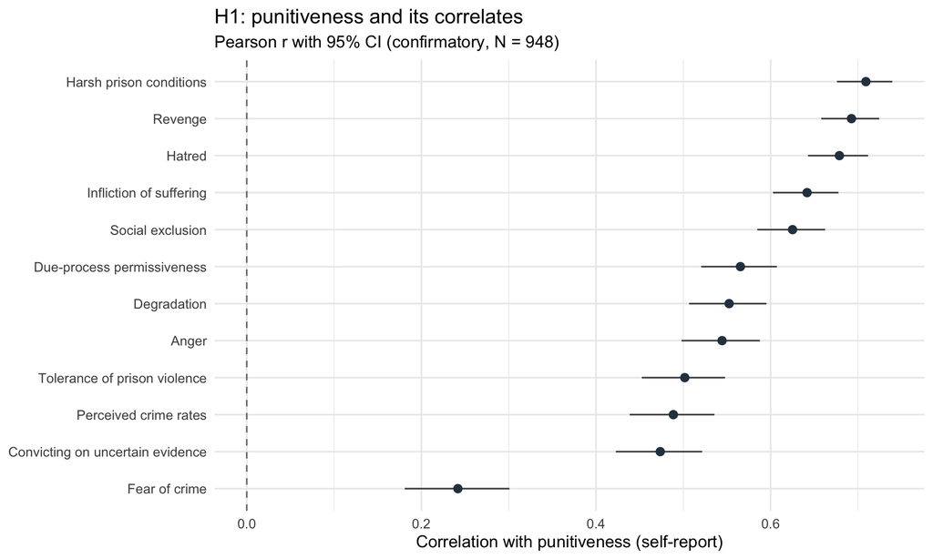

```r
# === FIGURE: H1 FOREST PLOT ===
# WHAT THIS CHUNK DOES: draws the twelve correlations as a forest plot -- one
# dot per correlate with a horizontal line running through it -- and writes
# output/figures/H1_correlate_forest.png, appending the path to FIGURES for the
# Phase 10.2 manifest, which is the list of every figure the document produced.
#
# The dot is the correlation. The line is its 95% confidence interval: the range
# of true values the data leave standing, wide when the estimate is loose and
# short when it is tight.
#
# A forest plot rather than a bar chart because the interval is the whole point.
# With N = 948 almost everything comes out "significant", so a chart built
# around significance would tell a reader nothing they could not guess in
# advance. What they need to see is how precisely each r is pinned down and how
# far it sits from zero. The dashed line at zero is the reference.
#
# CAREFUL: DO NOT JUDGE SIGNIFICANCE BY EYE FROM THIS PLOT. The interval drawn
# here is the two-sided, unadjusted 95% CI that cor.test() returns, while the
# significance reported in the H1 table is one-sided and BH-adjusted. Those are
# not the same test, so whether a line clears the dashed zero need not match
# what the table says about that correlate. The table is where significance is
# read; the plot is where precision and rank are read.
h1_plot <- h1_full
# Reorder the factor by r, so the plot reads as a ranking from bottom to top. A
# factor is R's type for a grouping variable, and it carries its categories in a
# fixed order. On a discrete y axis -- ggplot's own term for an axis of named
# categories rather than numbers -- ggplot draws the FIRST level at the BOTTOM.
# So ordering the levels from the smallest r upward puts the largest correlation
# at the top. Leave this out and the correlates appear in whatever order they
# happen to be listed in, which reads as no order at all.
h1_plot$label <- factor(h1_plot$y, levels = h1_plot$y[order(h1_plot$r)])
p_h1 <- ggplot2::ggplot(h1_plot, ggplot2::aes(x = r, y = label)) +
  ggplot2::geom_vline(xintercept = 0, linetype = 2, colour = "grey50") +
  ggplot2::geom_linerange(ggplot2::aes(xmin = ci_lower, xmax = ci_upper),
                          colour = "grey30") +
  ggplot2::geom_point(size = 2.6, colour = "#2c3e50") +
  ggplot2::labs(
    title = "H1: punitiveness and its correlates",
    subtitle = sprintf("Pearson r with 95%% CI (confirmatory, N = %d)", nrow(d)),
    x = "Correlation with punitiveness (self-report)", y = NULL) +
  ggplot2::theme_minimal(base_size = 13)
print(p_h1)
```

```r
# Saved at 300 dpi (dots per inch), the resolution journals ask for; save a
# figure at screen resolution instead and it prints blurred. Every figure in
# this document follows the same four steps: build the plot, print it into the
# knitted report, ggsave it into OUT_FIGURES, then append the path to FIGURES so
# Phase 10.2 can list it. Skip that last step and the file is written but never
# listed, so nobody reading the report knows it exists.
fig_path <- file.path(OUT_FIGURES, "H1_correlate_forest.png")
ggplot2::ggsave(fig_path, p_h1, width = 9, height = 6, dpi = 300)
FIGURES <- c(FIGURES, fig_path)
```

## 7.2 H2 – hostile aggression versus crime concerns (Steiger)

**H2.** The hostile-aggression cluster (hatred, revenge, degradation, suffering, prison violence) correlates more strongly with punitiveness than the crime-concerns cluster (perceived crime rates, fear) does. Put plainly: what drives punitiveness is antagonism toward offenders, not worry about crime.

Two correlations are being compared, and they are **dependent** (measured on the same people) and **overlapping** (both of them contain punitiveness). That combination rules out the ordinary way of comparing two correlations, which assumes each of them came from its own separate sample of people. These two did not. How far apart they can drift by chance depends on how strongly the two clusters correlate with each other, and a separate-samples comparison has no way to take that into account. The test used instead is **Steiger’s (1980) test for dependent overlapping correlations**, run through `cocor::cocor.dep.groups.overlap`. It is one-sided because the prediction names which of the two correlations should be the larger.

```r
# === H2: HOSTILE AGGRESSION VERSUS CRIME CONCERNS (prereg 2.1, 6.3) ===
# WHAT THIS CHUNK DOES: runs Steiger's test for dependent overlapping
# correlations on the whole sample, produces the table `H2_steiger`, and prints
# the cocor package's own full output beneath it.
#
# HOW TO READ IT. Three correlations go in, and their column names are terse:
#   r_jk -- punitiveness with hostile aggression, the predicted-stronger one
#   r_jh -- punitiveness with crime concerns, the rival it is measured against
#   r_kh -- the two clusters with each other. This is what makes the first two
#           depend on one another, and it is why Steiger's test is needed here
#           instead of an ordinary comparison of two correlations.
# The quantity of interest is `diff` = r_jk - r_jh, the gap between the two,
# reported with its zou2007 confidence interval: the range of true gaps the data
# leave standing. An interval that EXCLUDES zero is the substantive result,
# namely that punitiveness is better explained by antagonism toward offenders
# than by fear of crime. An interval straddling zero would mean the data do not
# separate the two rivals.
h2_full <- run_h2(d)
TABLES[["H2_steiger"]] <- h2_full
show_table(h2_full, "H2: Steiger's test for two dependent overlapping correlations")
```

H2: Steiger’s test for two dependent overlapping correlations

| comparison | r_jk | r_jh | r_kh | n | z | p | diff | diff_lower | diff_upper | alternative |
| --- | --- | --- | --- | --- | --- | --- | --- | --- | --- | --- |
| r(punitiveness, hostile aggression) > r(punitiveness, crime concerns) | 0.77 | 0.427 | 0.373 | 948 | 13.65 | 0 | 0.343 | 0.291 | 0.397 | greater |

```r
cat(sprintf("\nr(punitiveness, hostile aggression) = %.3f\n", h2_full$r_jk))
```

```
##
## r(punitiveness, hostile aggression) = 0.770
```

```r
cat(sprintf("r(punitiveness, crime concerns)     = %.3f\n", h2_full$r_jh))
```

```
## r(punitiveness, crime concerns)     = 0.427
```

```r
cat(sprintf("r(hostile aggression, crime concerns) = %.3f\n", h2_full$r_kh))
```

```
## r(hostile aggression, crime concerns) = 0.373
```

```r
cat(sprintf("Difference = %.3f, 95%% CI [%.3f, %.3f]; z = %.3f, p %s (one-sided)\n",
            h2_full$diff, h2_full$diff_lower, h2_full$diff_upper,
            h2_full$z, format_p(h2_full$p)))
```

```
## Difference = 0.343, 95% CI [0.291, 0.397]; z = 13.649, p < .001 (one-sided)
```

```r
# cocor's own printout, reproduced verbatim -- word for word, with nothing
# summarised away -- so a reader can see the test as the package itself states
# it: the null hypothesis, the alternative, and the exact statistic, not only
# the summarised row above. A reviewer checking this analysis against the
# package docs reads this block. It recomputes the same complete-case n that
# steiger_overlap() used, meaning the count of people who answered ALL THREE
# measures, so the two cannot disagree.
if (HAVE("cocor")) {
  ok2 <- stats::complete.cases(d$punitiveness, d$hostile_agg, d$crime_concerns)
  print(cocor::cocor.dep.groups.overlap(
    r.jk = h2_full$r_jk, r.jh = h2_full$r_jh, r.kh = h2_full$r_kh,
    n = sum(ok2), alternative = "greater", test = "steiger1980"))
}
```

```
##
##   Results of a comparison of two overlapping correlations based on dependent groups
##
## Comparison between r.jk = 0.7698 and r.jh = 0.427
## Difference: r.jk - r.jh = 0.3428
## Related correlation: r.kh = 0.3731
## Group size: n = 948
## Null hypothesis: r.jk is equal to r.jh
## Alternative hypothesis: r.jk is greater than r.jh (one-sided)
## Alpha: 0.05
##
## steiger1980: Steiger's (1980) modification of Dunn and Clark's z (1969) using average correlations
##   z = 13.6492, p-value = 0.0000
##   Null hypothesis rejected
```

## 7.2b H2 with the six-constituent cluster

H2 asks whether punitiveness tracks hostility toward offenders more closely than it tracks worry about crime. Section 7.2 answers it with the registered five-constituent cluster, using Steiger’s test for dependent overlapping correlations. That test asks whether one correlation is reliably larger than a second when both are measured on the same people and both share a variable. That answer stands. This subsection puts the same question a second time to the six-constituent companion built in 4.9b, which brings harsh prison conditions inside the cluster.

This is a rescoring check, not an independent test of H2. The two clusters share five of their six constituents and correlate very nearly perfectly, which 4.9b prints. So the companion row has to land close to the registered row before any data are consulted. A matching answer here is arithmetic before it is evidence, and reading it as confirmation would be a mistake. What the row can show is the narrow thing it is run for: whether the H2 result depends on harsh conditions having been scored outside the cluster rather than inside it.

Neither row is corrected for multiplicity, the extra risk of false alarms that comes with running more than one test. The second row is not a second test in any case. It shares punitiveness, it shares the crime-concerns foil, and it shares five of its six constituents with the first. So it adds a description of the registered result, not another chance of producing one.

```r
# === H2 REPEATED WITH THE SIX-CONSTITUENT CLUSTER (companion to 7.2) ===
# WHAT THIS CHUNK DOES: runs the H2 Steiger comparison twice, once with the
# registered five-constituent hostile-aggression cluster and once with
# `hostile_agg6`, which adds harsh prison conditions as a sixth constituent, and
# prints the two side by side as `H2b_hostile_cluster_five_vs_six`.
# PREREG: a companion to 6.3. H2 AS TESTED AND REPORTED IS THE FIVE-CONSTITUENT
#         VERSION IN 7.2. This chunk reproduces that result unchanged and sets a
#         companion beside it; the companion is NOT the test of H2.
# CONSUMES: run_h2() and steiger_overlap() (0.3 and 7.0), punitiveness (4.2),
#           hostile_agg and crime_concerns (4.9), hostile_agg6 (4.9b).
#
# The five-constituent row is produced by calling run_h2() itself, not by
# writing out a fresh steiger_overlap() call with the same arguments. That is
# deliberate. run_h2() is the registered function, and nothing between 7.2 and
# here changes `d`, the data frame that holds one row per participant. So this
# row IS the row 7.2 prints and cannot quietly drift away from it. A hand-copied
# call would drift. Someone later edits run_h2(); 7.2 changes and the copy does
# not; the document then reports two different numbers for one test.
h2b_five <- run_h2(d)

# The companion is identical in every respect except which cluster goes in. It
# keeps the same shared variable (punitiveness), the same foil (crime concerns),
# and the same one-sided "greater" direction. The foil is the rival the hostile
# cluster is measured against, and the direction carries the substantive claim
# that punitiveness is driven by antagonism toward offenders rather than by fear
# of crime. Keeping the foil and the direction fixed is the whole point. Change
# either one and the two rows stop answering the same question, so setting them
# side by side would tell a reader nothing.
h2b_six <- steiger_overlap(
  d, "punitiveness", "hostile_agg6", "crime_concerns",
  alternative = "greater",
  label = paste("r(punitiveness, hostile aggression, 6 constituents)",
                "> r(punitiveness, crime concerns)"))

h2b <- rbind(h2b_five, h2b_six)
# A plain-language key saying which row is which, carried as a column of the
# table rather than left to the row order. Left to row order, a reader who
# sorted the table, or who quoted a single row on its own, could easily take the
# companion for the registered test.
h2b$cluster <- c("5 constituents (registered, prereg 5.8)",
                 "6 constituents (companion, adds harsh conditions)")
h2b <- h2b[, c("cluster", "comparison", "r_jk", "r_jh", "r_kh", "n", "z", "p",
               "diff", "diff_lower", "diff_upper", "alternative")]
TABLES[["H2b_hostile_cluster_five_vs_six"]] <- h2b
# The long `comparison` string is dropped from the PRINTED version only, because
# it is wide enough to push the numbers off the edge of the page. The exported
# CSV still carries it, so the archived file records which comparison each row
# came from even though the printed table does not.
show_table(h2b[, c("cluster", "r_jk", "r_jh", "r_kh", "n", "z", "p", "diff",
                   "diff_lower", "diff_upper")],
           paste("7.2b: H2 with the registered cluster and with the",
                 "six-constituent companion. The registered test is the",
                 "first row."))
```

7.2b: H2 with the registered cluster and with the six-constituent companion. The registered test is the first row.

| cluster | r_jk | r_jh | r_kh | n | z | p | diff | diff_lower | diff_upper |
| --- | --- | --- | --- | --- | --- | --- | --- | --- | --- |
| 5 constituents (registered, prereg 5.8) | 0.770 | 0.427 | 0.373 | 948 | 13.65 | 0 | 0.343 | 0.291 | 0.397 |
| 6 constituents (companion, adds harsh conditions) | 0.784 | 0.427 | 0.382 | 948 | 14.57 | 0 | 0.357 | 0.306 | 0.411 |

```r
# HOW TO READ IT, the same way 7.2 reads. r_jk is punitiveness with the hostile
# cluster, r_jh is punitiveness with crime concerns, and r_kh is the two
# clusters with each other, which is the quantity that makes the first two
# depend on one another. The number of interest is diff = r_jk - r_jh, the gap
# between the two, with its confidence interval, the range of true gaps the data
# leave standing. An interval that excludes zero is the substantive result.
cat("\nRegistered, 5 constituents (this is H2):\n")
```

```
##
## Registered, 5 constituents (this is H2):
```

```r
cat(sprintf("  r(punit, hostile) = %.3f; r(punit, crime) = %.3f\n",
            h2b_five$r_jk, h2b_five$r_jh))
```

```
##   r(punit, hostile) = 0.770; r(punit, crime) = 0.427
```

```r
cat(sprintf("  difference = %.3f, 95%% CI [%.3f, %.3f]; z = %.3f, p %s\n",
            h2b_five$diff, h2b_five$diff_lower, h2b_five$diff_upper,
            h2b_five$z, format_p(h2b_five$p)))
```

```
##   difference = 0.343, 95% CI [0.291, 0.397]; z = 13.649, p < .001
```

```r
cat("Companion, 6 constituents:\n")
```

```
## Companion, 6 constituents:
```

```r
cat(sprintf("  r(punit, hostile) = %.3f; r(punit, crime) = %.3f\n",
            h2b_six$r_jk, h2b_six$r_jh))
```

```
##   r(punit, hostile) = 0.784; r(punit, crime) = 0.427
```

```r
cat(sprintf("  difference = %.3f, 95%% CI [%.3f, %.3f]; z = %.3f, p %s\n",
            h2b_six$diff, h2b_six$diff_lower, h2b_six$diff_upper,
            h2b_six$z, format_p(h2b_six$p)))
```

```
##   difference = 0.357, 95% CI [0.306, 0.411]; z = 14.569, p < .001
```

```r
# DO NOT READ ANYTHING INTO A SMALL WOBBLE IN r_jh. The crime-concerns
# correlation uses the SAME variable in both rows, and yet its value can move by
# a hair between them. Steiger's test needs complete cases across all three
# columns at once, meaning people who answered every one of the three measures.
# Swapping in a cluster with slightly different missingness -- a different
# pattern of who left items unanswered -- changes which participants qualify, so
# the two rows rest on slightly different sets of people. A small difference in
# r_jh is that, and nothing more. Both n's are printed below so the shift is
# visible instead of mysterious.
if (!is.na(h2b_five$r_jk) && !is.na(h2b_six$r_jk) &&
    !is.na(h2b_five$r_jh) && !is.na(h2b_six$r_jh)) {
  cat(sprintf("\nHarsh conditions moves the hostile correlation by %+.3f and\n",
              h2b_six$r_jk - h2b_five$r_jk))
  cat(sprintf("the crime-concerns correlation by %+.3f, on n = %d and %d.\n",
              h2b_six$r_jh - h2b_five$r_jh, h2b_five$n, h2b_six$n))
}
```

```
##
## Harsh conditions moves the hostile correlation by +0.014 and
## the crime-concerns correlation by +0.000, on n = 948 and 948.
```

```r
cat("The pre-registered test of H2 is the five-constituent row, and that is\n")
```

```
## The pre-registered test of H2 is the five-constituent row, and that is
```

```r
cat("the row reported as H2 wherever H2 is reported.\n")
```

```
## the row reported as H2 wherever H2 is reported.
```

## 7.3 H3 – do the correlates form one dimension?

**H3.** The correlates should be mostly positively intercorrelated, that is, they should mostly rise and fall together. That is what one would expect if a single punitiveness outlook runs through all twelve of them.

No single p-value can express a claim of that shape, so prereg 6.3 asks for three summaries, read together.

The first is the share of the intercorrelations that come out positive. The second is the first **eigenvalue**. Every component of the correlation matrix has an eigenvalue attached to it. That number says how much of the total variance – the total amount the 12 measures vary – the component carries, and the first eigenvalue is the largest of the twelve. The third is the **scree**, the plot of all the eigenvalues in order, taken from an **exploratory factor analysis (EFA)**. An EFA is a model that hunts for the hidden dimension, or dimensions, running behind a set of measures without being told in advance what they are.

```r
# === H3: DO THE CORRELATES FORM ONE DIMENSION? (prereg 2.1, 6.3) ===
# WHAT THIS CHUNK DOES: runs the three H3 summaries on the whole sample and
# produces the tables `H3_eigenvalues` and `H3_efa_loadings`. No one of the
# three settles the question alone, which is why prereg 6.3 asks for all three.
#
# HOW TO READ THE THREE PIECES TOGETHER.
#   share positive  -- of the 66 unique pairs of correlates, how many run the
#                      same way, meaning both rise together. A high share is the
#                      minimum one dimension requires: a negative pair is a
#                      correlate pulling against the rest.
#   first eigenvalue -- how much of the total variance, the total amount the 12
#                      measures vary, the leading component carries. A component
#                      is one common thread running through the 12 correlates,
#                      and the leading one is the thread they share most. With
#                      12 standardized variables an eigenvalue of 1 is the
#                      average share, so a first eigenvalue well above 1 plus a
#                      large first-to-second ratio is the pattern of one
#                      dominant factor.
#   one-factor EFA  -- an exploratory factor analysis fitted with a single
#                      hidden dimension. Its loadings say how strongly each
#                      correlate leans on that dimension, and loadings that are
#                      positive across the board mean every correlate is pulling
#                      on the same latent punitiveness outlook. Latent means the
#                      outlook is never measured directly; it is inferred from
#                      the way the twelve correlates move together.
# CAREFUL: the count of eigenvalues > 1 is printed but is NOT used to decide
# anything. That rule of thumb, the Kaiser criterion, overextracts -- it keeps
# more dimensions than the data support. Prereg 6.3 asks for the SHAPE of the
# scree, not for a count of values clearing a line.
h3_full <- run_h3(d)

cat(sprintf("Intercorrelations among the %d correlates: %d unique pairs\n",
            length(correlate_vars), h3_full$n_pairs))
```

```
## Intercorrelations among the 12 correlates: 66 unique pairs
```

```r
cat(sprintf("  share positive: %.1f%%\n", 100 * h3_full$share_positive))
```

```
##   share positive: 100.0%
```

```r
cat(sprintf("  mean intercorrelation: r = %.3f\n", h3_full$mean_r))
```

```
##   mean intercorrelation: r = 0.434
```

```r
cat(sprintf("  first eigenvalue: %.2f of %d (%.1f%% of the variance)\n",
            h3_full$eigenvalues[1], length(h3_full$eigenvalues),
            100 * h3_full$var_explained_1))
```

```
##   first eigenvalue: 5.95 of 12 (49.5% of the variance)
```

```r
cat(sprintf("  eigenvalues > 1: %d\n", h3_full$n_eigen_gt1))
```

```
##   eigenvalues > 1: 2
```

```r
cat(sprintf("  ratio of first to second eigenvalue: %.2f\n",
            h3_full$eigenvalues[1] / h3_full$eigenvalues[2]))
```

```
##   ratio of first to second eigenvalue: 4.43
```

```r
h3_eigen <- data.frame(component = seq_along(h3_full$eigenvalues),
                       eigenvalue = h3_full$eigenvalues,
                       proportion = h3_full$eigenvalues / sum(h3_full$eigenvalues))
TABLES[["H3_eigenvalues"]] <- h3_eigen
show_table(h3_eigen, "H3: eigenvalues of the correlate correlation matrix")
```

H3: eigenvalues of the correlate correlation matrix

| component | eigenvalue | proportion |
| --- | --- | --- |
| 1 | 5.946 | 0.495 |
| 2 | 1.343 | 0.112 |
| 3 | 0.826 | 0.069 |
| 4 | 0.702 | 0.059 |
| 5 | 0.554 | 0.046 |
| 6 | 0.548 | 0.046 |
| 7 | 0.491 | 0.041 |
| 8 | 0.418 | 0.035 |
| 9 | 0.399 | 0.033 |
| 10 | 0.298 | 0.025 |
| 11 | 0.250 | 0.021 |
| 12 | 0.225 | 0.019 |

```r
if (!is.null(h3_full$fa)) {
  # Column 1 of $loadings is the single factor, the one hidden dimension the
  # model was told to look for. Each value in that column is how strongly one
  # correlate leans on the dimension. Sorted from largest value downward, so the
  # table shows at a glance which correlates define the dimension and which sit
  # at its edge. WATCH FOR A NEGATIVE LOADING: it would be evidence AGAINST H3,
  # because it would mean one correlate runs against the common outlook.
  fa_load <- data.frame(correlate = rownames(h3_full$fa$loadings),
                        loading = as.numeric(h3_full$fa$loadings[, 1]),
                        stringsAsFactors = FALSE)
  fa_load <- fa_load[order(-fa_load$loading), ]
  TABLES[["H3_efa_loadings"]] <- fa_load
  print(show_table(fa_load, "H3: one-factor EFA loadings (minres)"))
  # Vaccounted row 2 is the proportion of the total variance -- the total amount
  # the correlates vary -- that the single factor accounts for. EXPECT IT TO
  # COME OUT LOWER than the raw first-eigenvalue share printed above, and do not
  # read the gap as a contradiction. A factor model excludes item-specific
  # variance, the part of each correlate that is peculiar to that one measure,
  # while an eigenvalue from a principal component analysis (PCA) counts that
  # part in.
  cat(sprintf("\nOne-factor EFA: %.1f%% of the variance explained.\n",
              100 * h3_full$fa$Vaccounted[2, 1]))
} else {
  cat("\nEFA could not be fitted on this sample.\n")
}
```

```
##
##
## Table: H3: one-factor EFA loadings (minres)
##
## |correlate   | loading|
## |:-----------|-------:|
## |harsh       |   0.825|
## |hatred      |   0.816|
## |suffering   |   0.797|
## |revenge     |   0.759|
## |degradation |   0.752|
## |exclusion   |   0.686|
## |anger       |   0.679|
## |dueprocess  |   0.668|
## |uncertain   |   0.566|
## |crimerates  |   0.512|
## |prisonviol  |   0.507|
## |fear        |   0.349|
##
## One-factor EFA: 45.5% of the variance explained.
```

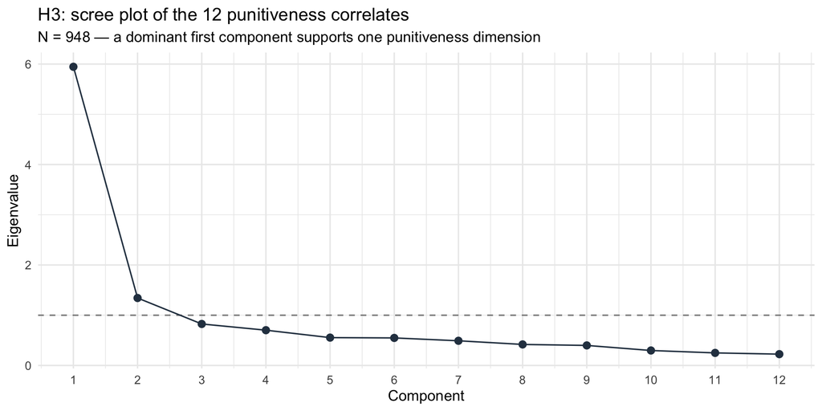

```r
# === FIGURE: H3 SCREE PLOT ===
# WHAT THIS CHUNK DOES: plots the 12 eigenvalues in order, largest first, and
# writes output/figures/H3_scree.png. A scree plot takes its name from the slope
# of loose rubble at the foot of a cliff, which is what the flat tail of the
# plot is meant to look like. Prereg 6.3 names the scree specifically.
#
# The reference line at 1 is the eigenvalue a component would have if it carried
# no more than its fair share: with 12 standardized variables the total variance
# is 12, so spread evenly each component gets 1.
#
# READ THE SHAPE, NOT THE COUNT. What supports H3 is a large first value and
# then a sharp drop to a flat tail. How many values happen to clear the line is
# not the test, and treating it as one is the Kaiser-criterion mistake warned
# about in the chunk above.
scree_df <- h3_eigen
p_scree <- ggplot2::ggplot(scree_df, ggplot2::aes(x = component, y = eigenvalue)) +
  ggplot2::geom_hline(yintercept = 1, linetype = 2, colour = "grey55") +
  ggplot2::geom_line(colour = "#2c3e50") +
  ggplot2::geom_point(size = 2.6, colour = "#2c3e50") +
  ggplot2::scale_x_continuous(breaks = scree_df$component) +
  ggplot2::labs(title = "H3: scree plot of the 12 punitiveness correlates",
                subtitle = sprintf("N = %d — a dominant first component supports one punitiveness dimension",
                                   h3_full$n_obs),
                x = "Component", y = "Eigenvalue") +
  ggplot2::theme_minimal(base_size = 13)
print(p_scree)
```

```r
fig_path <- file.path(OUT_FIGURES, "H3_scree.png")
ggplot2::ggsave(fig_path, p_scree, width = 8, height = 5, dpi = 300)
FIGURES <- c(FIGURES, fig_path)
```

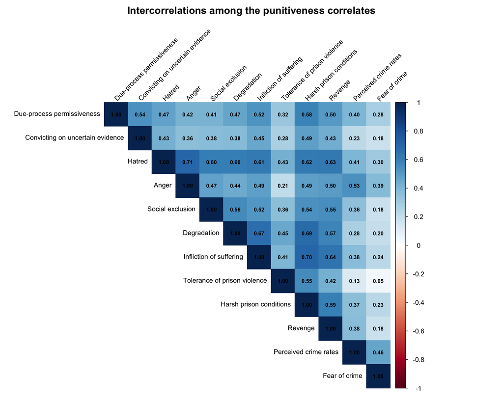

```r
# === FIGURE + TABLE: THE CORRELATE INTERCORRELATION MATRIX ===
# WHAT THIS CHUNK DOES: draws the 12 x 12 matrix of every correlate against
# every other one as a heatmap -- a grid in which each cell is shaded by how big
# the correlation sitting in it is -- writing
# output/figures/H3_correlate_heatmap.png, and stores the rounded matrix as the
# table `H3_correlate_matrix`.
#
# This is the raw material behind H3's summary statistics. The share positive
# and the eigenvalues are both computed FROM this matrix, so the heatmap is
# where a reader checks those summary statistics by eye. One dark negative cell
# in a field of positive ones is obvious here and invisible in a summary number.
cm <- h3_full$cor_matrix
# Swap the short variable names for readable display labels on both margins,
# rows and columns alike. The heatmap has to be readable by someone who has
# never seen `prisonviol` before and should not have to look it up.
dimnames(cm) <- list(unname(correlate_labels[rownames(cm)]),
                     unname(correlate_labels[colnames(cm)]))
# type = "upper" prints only the top half of the grid, so each pair shows up
# once instead of twice. That matches the 66 unique pairs H3 counts, and stops a
# reader counting the same correlation twice by eye.
#
# THE PLOT IS DRAWN TWICE ON PURPOSE, AND THE TWO CALLS MUST STAY IDENTICAL.
# corrplot draws straight onto whatever graphics device is currently open,
# instead of returning an object, so it cannot be printed once and then saved
# the way a ggplot can. The first call renders into the knitted report, the
# second into the PNG file. Edit one and not the other, and the figure in the
# report quietly stops matching the figure in output/figures.
if (HAVE("corrplot")) {
  corrplot::corrplot(cm, method = "color", type = "upper", addCoef.col = "black",
                     number.cex = 0.65, tl.col = "black", tl.srt = 45,
                     tl.cex = 0.8, mar = c(0, 0, 2, 0),
                     title = "Intercorrelations among the punitiveness correlates")
  fig_path <- file.path(OUT_FIGURES, "H3_correlate_heatmap.png")
  grDevices::png(fig_path, width = 2200, height = 2000, res = 220)
  corrplot::corrplot(cm, method = "color", type = "upper", addCoef.col = "black",
                     number.cex = 0.65, tl.col = "black", tl.srt = 45,
                     tl.cex = 0.8, mar = c(0, 0, 2, 0),
                     title = "Intercorrelations among the punitiveness correlates")
  invisible(grDevices::dev.off())
  FIGURES <- c(FIGURES, fig_path)
}
```

```r
TABLES[["H3_correlate_matrix"]] <- data.frame(correlate = rownames(cm),
                                              round(cm, 3), check.names = FALSE)
```

## 7.4 Punitiveness scored by its five parts

The registered punitiveness scale is the mean of eight items (prereg 5.2). The eight come from five parts: support for more punishment (two items), rejection of parsimony (two), three-strikes laws (two), life without parole (one) and the death penalty (one). The sentence is a sixth part, and it enters only the full index. Averaging items rather than parts has a consequence that is easy to miss: each two-item part carries a quarter of the scale and each one-item part an eighth, so life without parole and the death penalty count for half as much as three-strikes does. In the full index the imbalance runs the other way, because that index averages two things, the eight-item scale and the sentence, so the sentence alone carries half of it.

This subsection scores punitiveness one vote per part: the mean of the five part scores, and, with the sentence, the mean of six standardized parts. It reports how reliable each version is, how closely each agrees with the registered version, and whether H1, H2 and H10 change when punitiveness is scored this way.

This is a robustness check and is not in the registration. The registered eight-item scale remains the one every hypothesis is tested on, nothing here replaces it, and no multiplicity correction is applied or implied.

```r
# === 7.4 PUNITIVENESS SCORED BY ITS FIVE PARTS (a robustness check) ===
# WHAT THIS CHUNK DOES: scores punitiveness one vote per PART instead of one
# vote per ITEM, with and without the sentence; reports the nominal weight each
# part carries under each scoring, the reliability of each version, its
# agreement with the registered version, and H1, H2 and H10 rerun on the
# part-weighted scale. Produces `punit5_weights`,
# `punit5_reliability_agreement`, `punit5_H1_compare` and
# `punit5_H2_H10_compare`.
# PREREG: not registered. Prereg 5.2 scores the eight items, and that scale
#         stays the one every hypothesis is tested on.
# CONSUMES: punit_items (4.2), punitiveness, punitiveness_full, Sentence1_z,
#           hostile_agg, crime_concerns, revenge, just_deserts; run_h1(),
#           run_h10(), steiger_overlap(), cor_row().
#
# NOTHING HERE TOUCHES `d`. The part scores live in p5_d, a private copy, and
# they are never scored with compute_composite(), which would append them to
# the published Phase 4.10 reliability table.
# NAMING: every object this chunk leaves behind starts with p5_, so no later
# chunk can pick one up by accident.

# --- The at-least-half rule, as every composite applies it ------------------
# The mean of the columns for anyone who answered at least half of them (half
# rounds up), NaN turned into a real missing value. This is compute_composite()'s
# scoring rule without its side effect on alpha_table.
p5_mean_half <- function(df) {
  df <- as.data.frame(df)
  m <- rowMeans(df, na.rm = TRUE)
  m[rowSums(!is.na(df)) < ceiling(ncol(df) / 2)] <- NA_real_
  m[is.nan(m)] <- NA_real_
  as.numeric(m)
}
# Cronbach's alpha with the same settings used everywhere else in this document
# (check.keys = FALSE, so no item is silently flipped).
p5_alpha <- function(df) tryCatch(suppressWarnings(suppressMessages(
  psych::alpha(as.data.frame(df), check.keys = FALSE,
               warnings = FALSE)$total$raw_alpha)),
  error = function(e) NA_real_)

# --- The five parts ---------------------------------------------------------
# Each part uses exactly the columns punit_items uses, already reverse-coded,
# so high means more punitive on every part. DANGER: the parsimony part must be
# built from parsimony_1_R and parsimony_2_R. 8.3c uses the RAW parsimony
# columns on purpose, because there the question is whether people accept the
# limit; using those here would turn one part of five upside down.
# The guard below stops the knit if punit_items is ever edited, so the two
# scorings can never quietly describe different scales.
stopifnot(setequal(punit_items,
                   c("punishmore_1_R", "punishmore_2", "parsimony_1_R",
                     "parsimony_2_R", "threestrikes_1", "threestrikes_2",
                     "LWOP", "deathpenalty")))
p5_parts <- data.frame(
  punish_more        = p5_mean_half(d[, c("punishmore_1_R", "punishmore_2")]),
  parsimony_rejected = p5_mean_half(d[, c("parsimony_1_R", "parsimony_2_R")]),
  three_strikes      = p5_mean_half(d[, c("threestrikes_1", "threestrikes_2")]),
  life_without_parole = as.numeric(d$LWOP),
  death_penalty      = as.numeric(d$deathpenalty))

p5_d <- d
# FIVE PARTS, NO SENTENCE. A plain mean, not zmean(), because all five parts
# sit on the same 1-7 metric -- the same reason the registered scale is a plain
# mean of its items. The at-least-half rule asks for three of the five parts.
p5_d$punit_parts5 <- p5_mean_half(p5_parts)
# SIX PARTS, WITH THE SENTENCE. The sentence is a within-vignette z-score and
# the parts are 1-7 means, so every part is standardized before averaging, as
# the registered full index is. The difference is weighting only: the sentence
# is one part of six here, where in the registered index it is one of two.
p5_d$punit_parts6 <- zmean(p5_parts$punish_more, p5_parts$parsimony_rejected,
                           p5_parts$three_strikes, p5_parts$life_without_parole,
                           p5_parts$death_penalty, d$Sentence1_z)
# FIVE PARTS, EACH STANDARDIZED, NO SENTENCE. The same five parts as
# punit_parts5, but each is standardized across the sample before the five are
# averaged, as the six-part score does. The plain mean above lets a part with a
# wider spread count for more (the parts' SDs run from about 1.4 to 2.1); this
# version gives each part exactly a fifth. Nothing in 7.4 uses it and no 7.4
# table reports it. It is built
# here, beside punit_parts6, so that the two part scores the paper uses have one
# source: 7.5 and 7.6 (the comparisons with Study 1) and 9.19 (the paper's
# scorings) read both from p5_d. NOT REGISTERED; see 9.19.
p5_d$punit_parts5z <- zmean(p5_parts$punish_more, p5_parts$parsimony_rejected,
                            p5_parts$three_strikes, p5_parts$life_without_parole,
                            p5_parts$death_penalty)
# GUARD: both part scores exist for every participant (every part was
# required), so no later analysis silently drops a row; and the standardized
# five-part score still describes the registered scale's content (it agrees
# with the eight-item scale to about .99; a slip that turned a part upside down
# would pull this far lower).
stopifnot(!anyNA(p5_d$punit_parts6), !anyNA(p5_d$punit_parts5z),
          round(stats::cor(p5_d$punit_parts5z, d$punitiveness), 2) == 0.99)

# --- How much each part counts under each scoring ---------------------------
# NOMINAL shares: each part's share of the average, before any difference in
# how spread out the parts are. The registered full index is two standardized
# halves, so its attitude half is split by item (1/16 per item) and the
# sentence takes the other half.
p5_weights <- data.frame(
  part = c("Punish more (2 items)", "Parsimony rejected (2 items)",
           "Three strikes (2 items)", "Life without parole (1 item)",
           "Death penalty (1 item)", "Sentence (within-vignette z)"),
  registered_8_items    = c(2, 2, 2, 1, 1, 0) / 8,
  five_parts            = c(1, 1, 1, 1, 1, 0) / 5,
  registered_full_index = c(c(2, 2, 2, 1, 1) / 16, 1 / 2),
  six_parts             = rep(1, 6) / 6,
  stringsAsFactors = FALSE)
TABLES[["punit5_weights"]] <- p5_weights
show_table(p5_weights, "7.4: nominal share of each part under each scoring")
```

7.4: nominal share of each part under each scoring

| part | registered_8_items | five_parts | registered_full_index | six_parts |
| --- | --- | --- | --- | --- |
| Punish more (2 items) | 0.250 | 0.2 | 0.125 | 0.167 |
| Parsimony rejected (2 items) | 0.250 | 0.2 | 0.125 | 0.167 |
| Three strikes (2 items) | 0.250 | 0.2 | 0.125 | 0.167 |
| Life without parole (1 item) | 0.125 | 0.2 | 0.062 | 0.167 |
| Death penalty (1 item) | 0.125 | 0.2 | 0.062 | 0.167 |
| Sentence (within-vignette z) | 0.000 | 0.0 | 0.500 | 0.167 |

```r
# --- Reliability of each version, and agreement with the registered one ----
# The nine-part alpha is recomputed here with exactly the construction Phase 4.2
# uses for the full index (the eight items z-scored, plus Sentence1_z), so the
# two rows with a sentence are computed on the same footing.
p5_agree5 <- cor_row(p5_d, "punitiveness", "punit_parts5",
                     label_x = "Registered: 8 items", label_y = "Five parts")
p5_agree6 <- cor_row(p5_d, "punitiveness_full", "punit_parts6",
                     label_x = "Registered full index", label_y = "Six parts")
p5_rel <- data.frame(
  scoring = c("Registered: 8 items", "Five parts (one vote per part)",
              "Registered full index: 8 items z-scored + sentence",
              "Six parts: five parts z-scored + sentence"),
  k = c(8, 5, 9, 6),
  alpha = c(p5_alpha(d[, punit_items]),
            p5_alpha(p5_parts),
            p5_alpha(data.frame(scale(d[, punit_items]), s = d$Sentence1_z)),
            p5_alpha(data.frame(scale(p5_parts), s = d$Sentence1_z))),
  r_with_registered = c(NA, p5_agree5$r, NA, p5_agree6$r),
  ci_lower = c(NA, p5_agree5$ci_lower, NA, p5_agree6$ci_lower),
  ci_upper = c(NA, p5_agree5$ci_upper, NA, p5_agree6$ci_upper),
  n = c(sum(!is.na(d$punitiveness)), p5_agree5$n,
        sum(!is.na(d$punitiveness_full)), p5_agree6$n),
  stringsAsFactors = FALSE)
TABLES[["punit5_reliability_agreement"]] <- p5_rel
show_table(p5_rel, paste(
  "7.4: reliability of each scoring, and its correlation with the registered",
  "version it replaces (five parts against the 8-item scale; six parts against",
  "the full index)"))
```

7.4: reliability of each scoring, and its correlation with the registered version it replaces (five parts against the 8-item scale; six parts against the full index)

| scoring | k | alpha | r_with_registered | ci_lower | ci_upper | n |
| --- | --- | --- | --- | --- | --- | --- |
| Registered: 8 items | 8 | 0.846 | NA | NA | NA | 948 |
| Five parts (one vote per part) | 5 | 0.814 | 0.989 | 0.988 | 0.991 | 948 |
| Registered full index: 8 items z-scored + sentence | 9 | 0.851 | NA | NA | NA | 948 |
| Six parts: five parts z-scored + sentence | 6 | 0.826 | 0.945 | 0.938 | 0.952 | 948 |

```r
# --- H1 on the part-weighted scale ------------------------------------------
# run_h1() is the registered function, called twice on the same private copy:
# once on the registered scale, once on the five parts. Nothing about the 12
# correlates or the BH correction changes; only the punitiveness column does.
p5_h1_reg   <- run_h1(p5_d, punit = "punitiveness")
p5_h1_parts <- run_h1(p5_d, punit = "punit_parts5")
p5_h1 <- merge(p5_h1_reg[, c("y", "r", "ci_lower", "ci_upper", "sig")],
               p5_h1_parts[, c("y", "r", "ci_lower", "ci_upper", "sig")],
               by = "y", suffixes = c("_registered", "_parts5"))
p5_h1$diff <- p5_h1$r_parts5 - p5_h1$r_registered
p5_h1 <- p5_h1[order(-p5_h1$r_registered), ]
rownames(p5_h1) <- NULL
TABLES[["punit5_H1_compare"]] <- p5_h1
show_table(p5_h1, paste(
  "7.4: H1's twelve correlations with the registered scale and with the five",
  "parts. sig marks the BH-adjusted one-sided p within each column's own run."))
```

7.4: H1’s twelve correlations with the registered scale and with the five parts. sig marks the BH-adjusted one-sided p within each column’s own run.

| y | r_registered | ci_lower_registered | ci_upper_registered | sig_registered | r_parts5 | ci_lower_parts5 | ci_upper_parts5 | sig_parts5 | diff |
| --- | --- | --- | --- | --- | --- | --- | --- | --- | --- |
| Harsh prison conditions | 0.709 | 0.676 | 0.739 | *** | 0.697 | 0.662 | 0.728 | *** | -0.012 |
| Revenge | 0.693 | 0.658 | 0.724 | *** | 0.697 | 0.663 | 0.728 | *** | 0.004 |
| Hatred | 0.679 | 0.643 | 0.712 | *** | 0.669 | 0.632 | 0.702 | *** | -0.010 |
| Infliction of suffering | 0.642 | 0.603 | 0.678 | *** | 0.639 | 0.599 | 0.675 | *** | -0.003 |
| Social exclusion | 0.625 | 0.585 | 0.662 | *** | 0.621 | 0.580 | 0.658 | *** | -0.004 |
| Due-process permissiveness | 0.565 | 0.520 | 0.607 | *** | 0.562 | 0.517 | 0.604 | *** | -0.004 |
| Degradation | 0.552 | 0.507 | 0.595 | *** | 0.547 | 0.500 | 0.590 | *** | -0.006 |
| Anger | 0.544 | 0.498 | 0.588 | *** | 0.536 | 0.489 | 0.580 | *** | -0.008 |
| Tolerance of prison violence | 0.502 | 0.452 | 0.548 | *** | 0.493 | 0.443 | 0.540 | *** | -0.009 |
| Perceived crime rates | 0.489 | 0.439 | 0.536 | *** | 0.489 | 0.439 | 0.536 | *** | 0.001 |
| Convicting on uncertain evidence | 0.474 | 0.423 | 0.522 | *** | 0.468 | 0.417 | 0.516 | *** | -0.006 |
| Fear of crime | 0.242 | 0.181 | 0.301 | *** | 0.238 | 0.177 | 0.297 | *** | -0.004 |

```r
p5_big <- which.max(abs(p5_h1$diff))
cat(sprintf(paste(
  "\nAcross the twelve correlates the largest change in r is %+.3f (%s).",
  "\nRank order of the twelve, registered against five parts: Spearman = %.3f.",
  "\nBH significance marks: %s.\n"),
  p5_h1$diff[p5_big], p5_h1$y[p5_big],
  stats::cor(p5_h1$r_registered, p5_h1$r_parts5, method = "spearman"),
  ifelse(identical(p5_h1$sig_registered, p5_h1$sig_parts5),
         "identical in every row", "differ in at least one row -- read the table")))
```

```
##
## Across the twelve correlates the largest change in r is -0.012 (Harsh prison conditions).
## Rank order of the twelve, registered against five parts: Spearman = 0.993.
## BH significance marks: identical in every row.
```

```r
# --- H2 and H10 on the part-weighted scale ----------------------------------
# Same functions, same one-sided direction as registered. H2's cluster columns
# (hostile_agg, crime_concerns) are the registered ones; only punitiveness
# changes between the paired rows.
p5_steiger <- rbind(
  steiger_overlap(p5_d, "punitiveness", "hostile_agg", "crime_concerns",
                  alternative = "greater",
                  label = "H2 hostile aggression vs crime concerns: registered 8 items"),
  steiger_overlap(p5_d, "punit_parts5", "hostile_agg", "crime_concerns",
                  alternative = "greater",
                  label = "H2 hostile aggression vs crime concerns: five parts"),
  run_h10(p5_d, punit = "punitiveness"),
  run_h10(p5_d, punit = "punit_parts5"))
p5_steiger$comparison[3:4] <- c("H10 revenge vs just deserts: registered 8 items",
                                "H10 revenge vs just deserts: five parts")
TABLES[["punit5_H2_H10_compare"]] <- p5_steiger
show_table(p5_steiger, "7.4: H2 and H10 with the registered scale and with the five parts (Steiger, one-sided)")
```

7.4: H2 and H10 with the registered scale and with the five parts (Steiger, one-sided)

| comparison | r_jk | r_jh | r_kh | n | z | p | diff | diff_lower | diff_upper | alternative |
| --- | --- | --- | --- | --- | --- | --- | --- | --- | --- | --- |
| H2 hostile aggression vs crime concerns: registered 8 items | 0.770 | 0.427 | 0.373 | 948 | 13.65 | 0 | 0.343 | 0.291 | 0.397 | greater |
| H2 hostile aggression vs crime concerns: five parts | 0.764 | 0.425 | 0.373 | 948 | 13.37 | 0 | 0.339 | 0.286 | 0.393 | greater |
| H10 revenge vs just deserts: registered 8 items | 0.693 | 0.441 | 0.316 | 948 | 8.96 | 0 | 0.251 | 0.195 | 0.308 | greater |
| H10 revenge vs just deserts: five parts | 0.697 | 0.451 | 0.316 | 948 | 8.85 | 0 | 0.246 | 0.190 | 0.302 | greater |

## 7.5 Three quantities the Dark Side comparison needs

The Dark Side study reports eighteen correlates of punitiveness; this study registered twelve. Setting the two side by side in one table needs three quantities that the registered analyses above do not produce, and this section produces them. None is registered, none enters the H1 family, and none of the false-discovery-rate corrections above is recomputed to include them.

The first is punitiveness against the four personality and ideology measures. Right-wing authoritarianism, social dominance orientation, racial resentment and violence proneness are correlates of punitiveness in the Dark Side study. Here they were registered differently: prereg 2.4’s E1 predicts that retributivists score higher on them, which is a comparison between two groups of people, not a correlation. Section 9.15 runs E1 as registered. The correlations below are what the Dark Side table needs and are reported only as that.

The second is the sentence against hostile aggression and against crime concerns. H2 asks whether punitiveness travels with hostility more closely than with crime concern, and answers it with the punitiveness scale. The same question can be asked of the sentence itself, which is the one thing participants did rather than reported. The Dark Side study found its weakest version of the hostility result on that measure, so this is the row a reader comparing the two studies will look for.

The third is revenge scored the way the Dark Side study scored it. That study used three items; this one added a fourth, “Rather than showing criminals so much tolerance, we should be punishing them more severely.” Section 8.7b takes the scale apart item by item. What is needed here is narrower: the three original items against punitiveness scored as the paper scores it in both studies. One caution belongs with that row. The third item is not word for word across the two studies: the offender in the Dark Side version raped the daughter, and in this version sexually assaulted her. The scales are matched in content, not in wording, and a table setting them side by side should say so.

**Which punitiveness score the comparisons use.** The paper scores punitiveness the same way in both studies: its six components (support for more punishment, rejection of parsimony, three-strikes laws, life without parole, the death penalty, and the first sentence standardized within vignette) are each standardized and then averaged, so each carries a sixth of the weight. That is 7.4’s six-part score. The co-authors settled this on 27 September 2026, after the registered analyses were run; it is not registered. Every row of 7.5 and 7.6 that sets this study beside Study 1 carries the six-part score, so the two studies are compared on one scoring. Study 1’s published measure, the full index (the eight-item scale and the sentence, each standardized and averaged, so that the sentence carries half the weight), is not used here. Where the sentence is on the other side of a row, the score is the five attitude components, each standardized and averaged, without the sentence. The rows on the registered eight-item scale are kept as they were.

Study 1’s own numbers are not recomputed here. This document has this study’s data and not that one’s, so the rows below are one column of a two-column table, and the other column comes from that study’s own output (04_two_study_figures.Rmd computes Study 1 on the same six-part score).

```r
# === 7.5 THE THREE QUANTITIES THE DARK SIDE COMPARISON TABLE NEEDS ===
# WHAT THIS CHUNK DOES: computes three things the registered analyses do not
# produce, each needed to set this study beside the Dark Side study in one
# table. (A) punitiveness against the four personality and ideology measures,
# under both scorings of punitiveness. (B) the within-vignette sentence against
# hostile aggression and against crime concerns, with the Steiger comparison
# between those two, which is H2 asked of the sentence instead of the scale.
# (C) revenge scored with the three Dark Side items, against both scorings of
# punitiveness. Produces `DS_personality_correlates`,
# `DS_sentence_correlates`, `DS_sentence_steiger` and `DS_revenge_darkside`.
# PREREG: NOT REGISTERED, none of it. The registered H1 family is the twelve
#         correlates in 7.1 and the Benjamini-Hochberg correction there is
#         applied across exactly those twelve. Nothing here is added to that
#         family, and no correction above is recomputed. The four personality
#         measures are registered in this study as E1 GROUP CONTRASTS
#         (prereg 2.4), which 9.15 runs; a correlation is a different test of a
#         different thing and must not be reported as E1.
# CONSUMES: punitiveness (4.2), revenge and just_deserts (4.3), rwa, sdo,
#           raceresent, vprone (4.8), hostile_agg and crime_concerns (4.9),
#           hostile_agg6 (4.9b), Sentence1_z (3.2), revenge_1 to revenge_3;
#           p5_d$punit_parts6 and p5_d$punit_parts5z (7.4); cor_row(),
#           steiger_overlap().
#
# NOTHING HERE TOUCHES `d`, alpha_table, OR ANY REGISTERED OBJECT. The new
# variables this chunk builds live in ds_d, a private copy of `d`.
# NAMING: every object starts with ds_ ("Dark Side").
# WHICH PUNITIVENESS: two scorings, on purpose, and each row says which.
#   - The paper's score in both studies (NOT REGISTERED; settled by the
#     co-authors on 27 Sep 2026): the six components, each standardized, then
#     averaged (7.4's punit_parts6), carried here as ds_d$punit_six. Every row
#     that sets the two studies side by side uses it, so they are compared on
#     one scoring; the full index (`punitiveness_full`, Study 1's published
#     measure) is not used in 7.5 or 7.6. 04_two_study_figures.Rmd scores
#     Study 1 the same way.
#   - Where the sentence is on the other side of a row (7.5B's reference row),
#     the six-part score would put the sentence on both sides, so the row uses
#     the five attitude components, each standardized, then averaged (7.4's
#     punit_parts5z), carried as ds_d$punit_five.
#   - The registered eight-item self-report scale (`punitiveness`), kept in
#     every row that used it, for the registered side of the comparison.

ds_d <- d
# The paper's two punitiveness scores, carried across from 7.4's copy.
# GUARD: 7.4's copy holds the same participants in the same order, so the
# columns can be carried across row for row; and neither score is missing for
# anyone.
stopifnot(identical(p5_d$ResponseId, d$ResponseId),
          !anyNA(p5_d$punit_parts6), !anyNA(p5_d$punit_parts5z))
ds_d$punit_six  <- p5_d$punit_parts6
ds_d$punit_five <- p5_d$punit_parts5z
# The labels every DS_ export uses for the three scorings, set once so that a
# row can never carry one score under another's name.
DS_LAB_SIX   <- "Punitiveness (six components)"
DS_LAB_FIVE  <- "Punitiveness (five attitude components)"
DS_LAB_EIGHT <- "Punitiveness (8 items)"

# --- A. Punitiveness against the four personality and ideology measures -----
# Two-sided, because these rows are descriptive companions to another study's
# table rather than tests of a directional prediction made here.
ds_personality_spec <- list(
  c("rwa",        "Right-Wing Authoritarianism"),
  c("sdo",        "Social Dominance Orientation"),
  c("raceresent", "Racial resentment"),
  c("vprone",     "Violence proneness"))
# The second row of each pair is the paper's six-part score (see WHICH
# PUNITIVENESS above).
ds_personality <- do.call(rbind, lapply(ds_personality_spec, function(v) rbind(
  cor_row(ds_d, "punitiveness", v[1],
          label_x = DS_LAB_EIGHT, label_y = v[2]),
  cor_row(ds_d, "punit_six", v[1],
          label_x = DS_LAB_SIX, label_y = v[2]))))
TABLES[["DS_personality_correlates"]] <- ds_personality
show_table(ds_personality, paste(
  "7.5A: punitiveness against the four personality and ideology measures.",
  "Not registered; outside the H1 family; no correction. E1 tests these as",
  "group contrasts, in 9.15."))
```

7.5A: punitiveness against the four personality and ideology measures. Not registered; outside the H1 family; no correction. E1 tests these as group contrasts, in 9.15.

| x | y | n | r | ci_lower | ci_upper | p_two | p_dir | alternative |
| --- | --- | --- | --- | --- | --- | --- | --- | --- |
| Punitiveness (8 items) | Right-Wing Authoritarianism | 948 | 0.624 | 0.583 | 0.661 | 0 | 0 | two.sided |
| Punitiveness (six components) | Right-Wing Authoritarianism | 948 | 0.593 | 0.551 | 0.633 | 0 | 0 | two.sided |
| Punitiveness (8 items) | Social Dominance Orientation | 948 | 0.474 | 0.423 | 0.522 | 0 | 0 | two.sided |
| Punitiveness (six components) | Social Dominance Orientation | 948 | 0.443 | 0.390 | 0.492 | 0 | 0 | two.sided |
| Punitiveness (8 items) | Racial resentment | 948 | 0.545 | 0.499 | 0.588 | 0 | 0 | two.sided |
| Punitiveness (six components) | Racial resentment | 948 | 0.528 | 0.481 | 0.573 | 0 | 0 | two.sided |
| Punitiveness (8 items) | Violence proneness | 948 | 0.544 | 0.498 | 0.587 | 0 | 0 | two.sided |
| Punitiveness (six components) | Violence proneness | 948 | 0.525 | 0.478 | 0.570 | 0 | 0 | two.sided |

```r
# --- B. The sentence against hostile aggression and crime concerns ----------
# One-sided "greater" to match the direction H2 registers for the scale: more
# hostility goes with a longer sentence. The punitiveness rows are reprinted
# alongside so the sentence version can be read against the registered one.
ds_sentence <- do.call(rbind, list(
  cor_row(ds_d, "Sentence1_z", "hostile_agg", alternative = "greater",
          label_x = "Sentence (z within vignette)",
          label_y = "Hostile aggression (registered five parts)"),
  cor_row(ds_d, "Sentence1_z", "hostile_agg6", alternative = "greater",
          label_x = "Sentence (z within vignette)",
          label_y = "Hostile aggression (six parts, + harsh conditions)"),
  cor_row(ds_d, "Sentence1_z", "crime_concerns", alternative = "greater",
          label_x = "Sentence (z within vignette)",
          label_y = "Crime concerns"),
  # The reference row relates punitiveness to the sentence itself, so the
  # sentence is on the other side and the paper's sentence-free score is used:
  # the five attitude components, each standardized (it agrees with the
  # eight-item scale to about .99, 7.4).
  cor_row(ds_d, "punit_five", "Sentence1_z", alternative = "greater",
          label_x = DS_LAB_FIVE,
          label_y = "Sentence (z within vignette), for reference")))
TABLES[["DS_sentence_correlates"]] <- ds_sentence
show_table(ds_sentence,
           "7.5B: the sentence against hostility and against crime concern. Not registered.")
```

7.5B: the sentence against hostility and against crime concern. Not registered.

| x | y | n | r | ci_lower | ci_upper | p_two | p_dir | alternative |
| --- | --- | --- | --- | --- | --- | --- | --- | --- |
| Sentence (z within vignette) | Hostile aggression (registered five parts) | 948 | 0.373 | 0.317 | 0.426 | 0 | 0 | greater |
| Sentence (z within vignette) | Hostile aggression (six parts, + harsh conditions) | 948 | 0.374 | 0.318 | 0.428 | 0 | 0 | greater |
| Sentence (z within vignette) | Crime concerns | 948 | 0.247 | 0.186 | 0.306 | 0 | 0 | greater |
| Punitiveness (five attitude components) | Sentence (z within vignette), for reference | 948 | 0.483 | 0.432 | 0.530 | 0 | 0 | greater |

```r
# The Steiger comparison, run through the same function as H2 in 7.2, so the
# two are computed the same way and can be set beside each other. The three
# variables enter as (common, first competitor, second competitor), exactly as
# in 7.2, and the test uses one set of complete cases across all three.
ds_sentence_steiger <- rbind(
  steiger_overlap(ds_d, "Sentence1_z", "hostile_agg", "crime_concerns",
                  alternative = "greater",
                  label = "Sentence: hostile aggression (five parts) vs crime concerns"),
  steiger_overlap(ds_d, "Sentence1_z", "hostile_agg6", "crime_concerns",
                  alternative = "greater",
                  label = "Sentence: hostile aggression (six parts) vs crime concerns"))
TABLES[["DS_sentence_steiger"]] <- ds_sentence_steiger
show_table(ds_sentence_steiger, paste(
  "7.5B: H2 asked of the sentence rather than the punitiveness scale",
  "(Steiger, one-sided). Not registered."))
```

7.5B: H2 asked of the sentence rather than the punitiveness scale (Steiger, one-sided). Not registered.

| comparison | r_jk | r_jh | r_kh | n | z | p | diff | diff_lower | diff_upper | alternative |
| --- | --- | --- | --- | --- | --- | --- | --- | --- | --- | --- |
| Sentence: hostile aggression (five parts) vs crime concerns | 0.373 | 0.247 | 0.373 | 948 | 3.702 | 0 | 0.126 | 0.059 | 0.192 | greater |
| Sentence: hostile aggression (six parts) vs crime concerns | 0.374 | 0.247 | 0.382 | 948 | 3.777 | 0 | 0.127 | 0.061 | 0.193 | greater |

```r
# --- C. Revenge scored with the three Dark Side items -----------------------
# The scoring rule is compute_composite()'s: the mean of the items, with a row
# left missing unless at least half the items were answered. It is restated
# here rather than borrowed, because compute_composite() also appends a row to
# alpha_table, and this scale is not one of the study's composites.
ds_mean_half <- function(df) {
  df <- as.data.frame(df)
  m <- rowMeans(df, na.rm = TRUE)
  m[rowSums(!is.na(df)) < ceiling(ncol(df) / 2)] <- NA_real_
  m[is.nan(m)] <- NA_real_
  as.numeric(m)
}
ds_rev3_items <- c("revenge_1", "revenge_2", "revenge_3")
ds_d$revenge_ds3 <- ds_mean_half(d[, ds_rev3_items, drop = FALSE])
# GUARD: the same rule applied to all four items must reproduce the registered
# revenge composite. If it does not, the rule above has drifted from the one
# Phase 4 used, and the three-item row would not be comparable to anything.
stopifnot(isTRUE(all.equal(ds_mean_half(d[, paste0("revenge_", 1:4)]), d$revenge)))
# check.keys = FALSE so psych::alpha reports the scale as scored rather than
# silently flipping an item, which would describe a scale nobody used.
ds_alpha <- tryCatch(suppressWarnings(suppressMessages(
  psych::alpha(as.data.frame(d[, ds_rev3_items]), check.keys = FALSE,
               warnings = FALSE)$total$raw_alpha)),
  error = function(e) NA_real_)

# Rows 1, 3 and 5 are the paper's six-part score, rows 2 and 4 the registered
# eight-item scale. Row 5's just deserts is the registered
# composite (desert, items 1-4, averaged with the proportionality component),
# labelled as such.
ds_revenge <- do.call(rbind, list(
  cor_row(ds_d, "punit_six", "revenge_ds3", alternative = "greater",
          label_x = DS_LAB_SIX,
          label_y = "Revenge, Dark Side scoring (revenge_1 to _3)"),
  cor_row(ds_d, "punitiveness", "revenge_ds3", alternative = "greater",
          label_x = DS_LAB_EIGHT,
          label_y = "Revenge, Dark Side scoring (revenge_1 to _3)"),
  cor_row(ds_d, "punit_six", "revenge", alternative = "greater",
          label_x = DS_LAB_SIX,
          label_y = "Revenge, registered scoring (revenge_1 to _4)"),
  cor_row(ds_d, "punitiveness", "revenge", alternative = "greater",
          label_x = DS_LAB_EIGHT,
          label_y = "Revenge, registered scoring (revenge_1 to _4)"),
  cor_row(ds_d, "punit_six", "just_deserts", alternative = "greater",
          label_x = DS_LAB_SIX,
          label_y = "Just deserts (registered), for reference")))
TABLES[["DS_revenge_darkside"]] <- ds_revenge
show_table(ds_revenge, paste(
  "7.5C: revenge scored with the three Dark Side items and with the registered",
  "four, against the paper's six-part score and the eight-item scale. Not registered."))
```

7.5C: revenge scored with the three Dark Side items and with the registered four, against the paper’s six-part score and the eight-item scale. Not registered.

| x | y | n | r | ci_lower | ci_upper | p_two | p_dir | alternative |
| --- | --- | --- | --- | --- | --- | --- | --- | --- |
| Punitiveness (six components) | Revenge, Dark Side scoring (revenge_1 to _3) | 948 | 0.549 | 0.503 | 0.592 | 0 | 0 | greater |
| Punitiveness (8 items) | Revenge, Dark Side scoring (revenge_1 to _3) | 948 | 0.558 | 0.513 | 0.601 | 0 | 0 | greater |
| Punitiveness (six components) | Revenge, registered scoring (revenge_1 to _4) | 948 | 0.676 | 0.640 | 0.709 | 0 | 0 | greater |
| Punitiveness (8 items) | Revenge, registered scoring (revenge_1 to _4) | 948 | 0.693 | 0.658 | 0.724 | 0 | 0 | greater |
| Punitiveness (six components) | Just deserts (registered), for reference | 948 | 0.468 | 0.417 | 0.516 | 0 | 0 | greater |

```r
cat(sprintf(paste("\nRevenge on the three Dark Side items: alpha = %.3f (k = 3),",
                  "M = %.3f.\nThe registered four-item scale: M = %.3f.\n"),
            ds_alpha, mean(ds_d$revenge_ds3, na.rm = TRUE),
            mean(d$revenge, na.rm = TRUE)))
```

```
##
## Revenge on the three Dark Side items: alpha = 0.658 (k = 3), M = 4.155.
## The registered four-item scale: M = 4.144.
```

```r
cat("The third item differs in wording across the two studies (raped / sexually\n")
```

```
## The third item differs in wording across the two studies (raped / sexually
```

```r
cat("assaulted), so the scales are matched in content, not word for word.\n")
```

```
## assaulted), so the scales are matched in content, not word for word.
```

```r
# --- C2. The two clusters rebuilt exactly as the Dark Side study built them -
# Study 1 aggregated RAW ITEMS, not composites, and used plain rowMeans with no
# minimum-answered rule. Both choices are reproduced here so that the matched
# rows below differ from that study in nothing but the sample. The item lists
# are that study's own: six hostility constructs (and note it did NOT include
# hatred), and its three-item revenge scoring rather than the registered four.
s1_mean <- function(df) {
  m <- rowMeans(as.data.frame(df), na.rm = TRUE)
  m[is.nan(m)] <- NA_real_
  as.numeric(m)
}
s1_hostile_items <- c(paste0("exclusion_", 1:3),
                      "degrad_1_R", "degrad_2", "degrad_3",
                      "suffer_1", "suffer_2",
                      "prisonvi_1_R", "prisonvi_2_R",
                      "harsh_1", "harsh_2_R", "harsh_3",
                      "revenge_1", "revenge_2", "revenge_3")
s1_crime_items   <- c("rates_1", "rates_2", "fear_1_R", "fear_2", "fear_3")
# GUARD: every item must be present under the name Study 1 used. A silent
# rename between the two instruments would otherwise drop an item from the
# mean and quietly change the cluster.
stopifnot(all(c(s1_hostile_items, s1_crime_items) %in% names(d)))
ds_d$hostile_s1 <- s1_mean(d[, s1_hostile_items])
ds_d$crime_s1   <- s1_mean(d[, s1_crime_items])

# --- D. H2 on the punitiveness measure the two studies share ----------------
# WHY THIS EXISTS. 7.2 runs H2 on the registered eight-item scale, which is what
# every preregistered test in this document uses. The paper compares the two
# studies on a punitiveness measure that INCLUDES the sentence, the six-part
# score, computed the same way in both (see WHICH PUNITIVENESS above).
# Setting the two studies side by side on H2 therefore needs this study's
# version computed on that score, or the two numbers are about different
# outcomes. run_h2() already takes the punitiveness column as an argument, so
# each row below is the registered test with one substitution and nothing else
# changed.
ds_h2 <- rbind(
  cbind(scoring = "Registered: punitiveness, 8 self-report items",
        run_h2(ds_d, punit = "punitiveness")),
  cbind(scoring = "Matched to Study 1: six components",
        run_h2(ds_d, punit = "punit_six")))
# The third row goes one step further. The Dark Side cluster was built from six
# constructs and did NOT include hatred, while it DID include social exclusion
# and harsh prison conditions, which the registered cluster here leaves out.
# Rebuilding this study's cluster from that study's own six constituents is the
# only row on which the two studies run the same test on the same measure. One
# difference survives even here and must travel with this row wherever it is
# reported: that study averaged its 16 items directly, while zmean() averages
# the five or six composites, so the aggregation still differs.
# BOTH RIVALS ARE REBUILT, not just the hostile one. Study 1 averaged the raw
# ITEMS of its six hostility constructs (16 items) and the raw items of its
# crime concerns constructs (5 items). Averaging items is not the same
# estimator as averaging composites: an item mean lets a three-item construct
# weigh more than a two-item one, while zmean() gives every construct equal
# weight. Rebuilding only one side would leave the two studies' H2 rows
# differing on the other. 7.6 builds these two clusters and reports their
# reliabilities; this row is the H2 test run on them.
ds_h2 <- rbind(ds_h2, cbind(
  scoring = "Matched to Study 1: six components, Study 1's items and aggregation",
  steiger_overlap(ds_d, "punit_six", "hostile_s1", "crime_s1",
                  alternative = "greater",
                  label = "r(punitiveness, hostile aggression) > r(punitiveness, crime concerns)")))
# GUARD: row 1 is the registered test and must reproduce 7.2 exactly. If it does
# not, run_h2() is being handed something other than the registered inputs and
# none of the rows below it could be read against the registered result.
stopifnot(isTRUE(all.equal(ds_h2$diff[1], h2_full$diff)),
          isTRUE(all.equal(ds_h2$z[1], h2_full$z)))
TABLES[["DS_H2_matched"]] <- ds_h2
show_table(ds_h2[, c("scoring", "r_jk", "r_jh", "r_kh", "n", "diff",
                     "diff_lower", "diff_upper", "z", "p")], paste(
  "7.5D: H2 on the registered scale and on the measure and cluster the Dark",
  "Side study used. One-sided, as registered. Rows 2 and 3 are not registered."))
```

7.5D: H2 on the registered scale and on the measure and cluster the Dark Side study used. One-sided, as registered. Rows 2 and 3 are not registered.

| scoring | r_jk | r_jh | r_kh | n | diff | diff_lower | diff_upper | z | p |
| --- | --- | --- | --- | --- | --- | --- | --- | --- | --- |
| Registered: punitiveness, 8 self-report items | 0.770 | 0.427 | 0.373 | 948 | 0.343 | 0.291 | 0.397 | 13.65 | 0 |
| Matched to Study 1: six components | 0.749 | 0.427 | 0.373 | 948 | 0.322 | 0.269 | 0.377 | 12.51 | 0 |
| Matched to Study 1: six components, Study 1’s items and aggregation | 0.754 | 0.397 | 0.346 | 948 | 0.357 | 0.303 | 0.414 | 13.52 | 0 |

```r
# --- E. H2 with both correlations corrected for unreliability --------------
# WHY. The two rivals in H2 are not measured equally well: the hostile
# aggression cluster is built from five composites and the crime concerns
# cluster from two. A correlation is held down by the unreliability of both
# variables, so the less reliable rival is held down further, which widens the
# gap between them on its own. Correcting both for attenuation asks whether the
# gap survives when that is taken out. The classic correction divides each
# correlation by the square root of the product of the two reliabilities.
# 9.13 sets out this document's standing policy of NOT correcting, and that
# policy still governs every registered result. This is one companion table,
# outside it, reported because the comparison it qualifies is the study's
# central one.
ds_alpha_of <- function(nm) {
  i <- match(nm, alpha_table$composite)
  stopifnot(!is.na(i))
  alpha_table$alpha[i]
}
ds_a_punit  <- ds_alpha_of("punitiveness (self-report, 8)")
ds_a_host   <- ds_alpha_of("hostile aggression cluster")
ds_a_crime  <- ds_alpha_of("crime concerns cluster")
# Row 2 of ds_h2 is the six-part score, so its reliability is the alpha of
# the six parts exactly as that score is built: the five components and the
# within-vignette sentence z-score, EACH standardized across the sample.
# (7.4's p5_rel row enters the sentence z-score without that second
# standardization, where its SD is .999 rather than 1; the difference is in the
# fourth decimal, but the alpha reported for a score should be the alpha of the
# parts that score averages.) It is not in alpha_table, which holds the
# registered composites only.
# GUARD: the six parts, standardized, average exactly to the six-part score, so
# this alpha describes the score in row 2 and no other.
ds_six_parts <- data.frame(scale(p5_parts), s = as.numeric(scale(d$Sentence1_z)))
stopifnot(isTRUE(all.equal(rowMeans(ds_six_parts), p5_d$punit_parts6)))
ds_a_six    <- p5_alpha(ds_six_parts)
ds_disatt <- function(r, a1, a2) r / sqrt(a1 * a2)
ds_att <- do.call(rbind, lapply(1:2, function(i) {
  ap <- c(ds_a_punit, ds_a_six)[i]
  data.frame(
    scoring = ds_h2$scoring[i],
    alpha_punitiveness = ap, alpha_hostile = ds_a_host, alpha_crime = ds_a_crime,
    r_hostile_observed = ds_h2$r_jk[i], r_crime_observed = ds_h2$r_jh[i],
    gap_observed = ds_h2$diff[i],
    r_hostile_corrected = ds_disatt(ds_h2$r_jk[i], ap, ds_a_host),
    r_crime_corrected   = ds_disatt(ds_h2$r_jh[i], ap, ds_a_crime),
    gap_corrected = ds_disatt(ds_h2$r_jk[i], ap, ds_a_host) -
                    ds_disatt(ds_h2$r_jh[i], ap, ds_a_crime),
    stringsAsFactors = FALSE)
}))
TABLES[["DS_H2_attenuation"]] <- ds_att
show_table(ds_att, paste(
  "7.5E: H2 before and after correcting both correlations for unreliability.",
  "Not registered; descriptive only."))
```

7.5E: H2 before and after correcting both correlations for unreliability. Not registered; descriptive only.

| scoring | alpha_punitiveness | alpha_hostile | alpha_crime | r_hostile_observed | r_crime_observed | gap_observed | r_hostile_corrected | r_crime_corrected | gap_corrected |
| --- | --- | --- | --- | --- | --- | --- | --- | --- | --- |
| Registered: punitiveness, 8 self-report items | 0.846 | 0.856 | 0.633 | 0.770 | 0.427 | 0.343 | 0.904 | 0.583 | 0.321 |
| Matched to Study 1: six components | 0.825 | 0.856 | 0.633 | 0.749 | 0.427 | 0.322 | 0.891 | 0.590 | 0.301 |

```r
# NO TEST IS REPORTED ON THE CORRECTED VALUES, deliberately. A Steiger z or a
# confidence interval computed on disattenuated correlations treats estimated
# reliabilities as if they were known exactly, which they are not, and the
# resulting p-value would be far too small. The corrected numbers are read as an
# upper bound on what the gap could be if both measures were perfect, nothing
# more.
cat(sprintf(paste("\nThe gap between the two rivals, before and after correcting",
                  "for unreliability:\n  registered 8-item scale: %.3f -> %.3f",
                  "\n  six components:          %.3f -> %.3f\n"),
            ds_att$gap_observed[1], ds_att$gap_corrected[1],
            ds_att$gap_observed[2], ds_att$gap_corrected[2]))
```

```
##
## The gap between the two rivals, before and after correcting for unreliability:
##   registered 8-item scale: 0.343 -> 0.321
##   six components:          0.322 -> 0.301
```

```r
cat(sprintf(paste("A corrected correlation near 1 is a sign of how unstable this",
                  "correction becomes\nwhen one reliability is modest: the crime",
                  "concerns cluster has just two parts\n(alpha = %.3f).\n"),
            ds_a_crime))
```

```
## A corrected correlation near 1 is a sign of how unstable this correction becomes
## when one reliability is modest: the crime concerns cluster has just two parts
## (alpha = 0.633).
```

## 7.6 The Dark Side analyses, repeated here

Section 7.5 supplies the quantities the cross-study table needs. This section goes further and repeats the analyses the Dark Side study ran, on this sample, scored the way that study scored them. Four of them travel with the paper: the ordering of the four attitude clusters, the sensitivity ladder that answers the objection that hostility and punitiveness are the same thing, the comparison run on each part of punitiveness separately, and the stability of the correlations across the three vignettes.

```r
# === 7.6 THE DARK SIDE ANALYSES REPEATED ON THIS SAMPLE ===
# WHAT THIS CHUNK DOES: rebuilds the Dark Side study's four attitude clusters
# from raw items, correlates each with punitiveness under two scorings (the
# paper's six-part score and the registered eight-item scale), runs
# that study's three-level sensitivity ladder, repeats H2 on each part of
# punitiveness separately, and reports how far the H1 correlations move across
# the three vignettes. Produces `DS_clusters_reliability`,
# `DS_cluster_correlations`, `DS_tautology_ladder`, `DS_H2_by_part` and
# `DS_vignette_stability`.
# PREREG: NOT REGISTERED, none of it. These are the companion study's analyses,
#         run here so the two can be read side by side.
# CONSUMES: the raw attitude items, punitiveness (4.2), the composites of 4.5
#           and 4.7, ds_d with its punit_six column and the DS_LAB_ labels
#           (7.5), s1_mean(), s1_hostile_items and s1_crime_items (7.5C2),
#           cor_row(), steiger_overlap(), run_h1(), correlate_vars and
#           correlate_labels (7.0).
# NOTHING HERE TOUCHES `d`. Everything lives on ds_d, the private copy 7.5
# opened, and on s1_ objects created here.

# --- A. The four clusters, built from raw items as Study 1 built them ------
ds_d$emotions_s1 <- s1_mean(d[, c("hate_1", "hate_2_R", "hate_3",
                                  "anger_1", "anger_2")])
# The personality cluster is NOT a match; see the section text. It is built here
# from the four shared measures so that the row is not simply missing.
s1_personality_items <- c("rwa_1", "rwa_2", "rwa_3_R", "rwa_4", "rwa_5",
                          "sdo_1", "sdo_2", "sdo_3_R", "sdo_4_R", "sdo_5",
                          "sdo_6", "sdo_7_R", "sdo_8_R",
                          paste0("vprone_", 1:4),
                          "Raceresent_1_R", "Raceresent_2", "Raceresent_3",
                          "Raceresent_4_R")
stopifnot(all(s1_personality_items %in% names(d)))
ds_d$personality_s1 <- s1_mean(d[, s1_personality_items])

s1_alpha <- function(items) tryCatch(suppressWarnings(suppressMessages(
  psych::alpha(as.data.frame(d[, items]), check.keys = FALSE,
               warnings = FALSE)$total$raw_alpha)), error = function(e) NA_real_)
s1_cluster_spec <- list(
  "Hostile aggression (Study 1 items, 16)" = s1_hostile_items,
  "Emotions (Study 1 items, 5)"            = c("hate_1", "hate_2_R", "hate_3",
                                               "anger_1", "anger_2"),
  "Personality and ideology (4 shared measures, 21 items)" = s1_personality_items,
  "Crime concerns (Study 1 items, 5)"      = s1_crime_items)
ds_clusters_rel <- data.frame(
  cluster = names(s1_cluster_spec),
  k = vapply(s1_cluster_spec, length, integer(1)),
  alpha = vapply(s1_cluster_spec, s1_alpha, numeric(1)),
  stringsAsFactors = FALSE, row.names = NULL)
TABLES[["DS_clusters_reliability"]] <- ds_clusters_rel
show_table(ds_clusters_rel, paste(
  "7.6A: the Dark Side study's clusters rebuilt from raw items on this sample.",
  "Not registered."))
```

7.6A: the Dark Side study’s clusters rebuilt from raw items on this sample. Not registered.

| cluster | k | alpha |
| --- | --- | --- |
| Hostile aggression (Study 1 items, 16) | 16 | 0.899 |
| Emotions (Study 1 items, 5) | 5 | 0.866 |
| Personality and ideology (4 shared measures, 21 items) | 21 | 0.928 |
| Crime concerns (Study 1 items, 5) | 5 | 0.787 |

```r
# --- B. Each cluster against punitiveness, both scorings -------------------
# Study 1 read the ORDER of these four correlations as its macro-level result.
# Reporting the same four here is what lets the two orderings be set side by
# side. cor_row() carries the 95% interval, so the overlap between neighbouring
# clusters is visible rather than implied.
s1_cluster_cols <- c("hostile_s1", "emotions_s1", "personality_s1", "crime_s1")
s1_cluster_names <- c("Hostile aggression", "Emotions",
                      "Personality and ideology", "Crime concerns")
# The first row of each pair is the six-part score, the second the registered
# eight-item scale.
ds_cluster_cor <- do.call(rbind, lapply(seq_along(s1_cluster_cols), function(i) rbind(
  cor_row(ds_d, "punit_six", s1_cluster_cols[i],
          label_x = DS_LAB_SIX,
          label_y = s1_cluster_names[i]),
  cor_row(ds_d, "punitiveness", s1_cluster_cols[i],
          label_x = DS_LAB_EIGHT,
          label_y = s1_cluster_names[i]))))
TABLES[["DS_cluster_correlations"]] <- ds_cluster_cor
show_table(ds_cluster_cor, paste(
  "7.6B: the four clusters against punitiveness, with 95% intervals.",
  "Study 1 reports the same four on its own sample. Not registered."))
```

7.6B: the four clusters against punitiveness, with 95% intervals. Study 1 reports the same four on its own sample. Not registered.

| x | y | n | r | ci_lower | ci_upper | p_two | p_dir | alternative |
| --- | --- | --- | --- | --- | --- | --- | --- | --- |
| Punitiveness (six components) | Hostile aggression | 948 | 0.754 | 0.725 | 0.780 | 0 | 0 | two.sided |
| Punitiveness (8 items) | Hostile aggression | 948 | 0.775 | 0.748 | 0.799 | 0 | 0 | two.sided |
| Punitiveness (six components) | Emotions | 948 | 0.654 | 0.615 | 0.689 | 0 | 0 | two.sided |
| Punitiveness (8 items) | Emotions | 948 | 0.672 | 0.636 | 0.706 | 0 | 0 | two.sided |
| Punitiveness (six components) | Personality and ideology | 948 | 0.635 | 0.595 | 0.671 | 0 | 0 | two.sided |
| Punitiveness (8 items) | Personality and ideology | 948 | 0.666 | 0.629 | 0.700 | 0 | 0 | two.sided |
| Punitiveness (six components) | Crime concerns | 948 | 0.397 | 0.341 | 0.449 | 0 | 0 | two.sided |
| Punitiveness (8 items) | Crime concerns | 948 | 0.398 | 0.343 | 0.450 | 0 | 0 | two.sided |